# 社会性动物（第12版）

乔舒亚·阿伦森

艾略特·阿伦森

2020-04-30T16:00:00+00:00

[figure not shown]

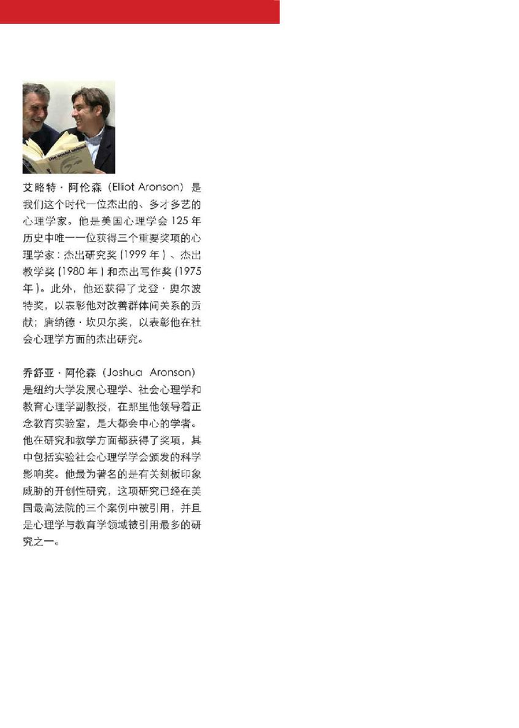

[figure not shown]

图书在版编目（CIP）数据

社会性动物：第12版/（美）艾略特·阿伦森，（美）乔舒亚·阿伦森著；邢占军，黄立清译.—上海：华东师范大学出版社，2020

ISBN 978-7-5675-9970-3

Ⅰ.①社… Ⅱ.①艾…②乔…③邢…④黄… Ⅲ.①社会心理学-研究 Ⅳ.①C912.6

中国版本图书馆CIP数据核字（2020）第028124号

社会性动物（第12版）

著 者 ［美］艾略特·阿伦森 ［美］乔舒亚·阿伦森

译 者 邢占军 黄立清

责任编辑 彭呈军

特约审读 单敏月

责任校对 王丽平 时东明

装帧设计 高山

出版发行 华东师范大学出版社

社 址 上海市中山北路3663号 邮编 200062

网 址 www.ecnupress.com.cn

电 话 021-60821666 行政传真 021-62572105

客服电话 021-62865537 门市（邮购）电话 021-62869887

地 址 上海市中山北路3663号华东师范大学校内先锋路口

网 店 http://hdsdcbs.tmall.com

印 刷 者 浙江省临安市曙光印务有限公司

开 本 787×1092 16开

印 张 24.75

字 数 440千字

版 次 2020年5月第12版

印 次 2020年5月第1次

书 号 ISBN 978-7-5675-9970-3

定 价 79.00元

出 版 人 王焰

（如发现本版图书有印订质量问题，请寄回本社客服中心调换或电话 021-62865537联系）

The Social Animal, 12<sup>th</sup> Edition

By Elliot Aronson, Joshua Aronson

First published in the United States by Worth Publishers

Copyright ©2018, 2012, 2008, 2004, 1999 by Worth Publishers

©1995, 1992, 1988, 1984, 1980, 1976, 1972 by W.H.Freeman and Company

Simplified Chinese translation copyright © East China Normal University Press Ltd., 2020

All rights reserved.

本书英文原版由Worth Publishers在美国首次出版。

©2018, 2012, 2008, 2004, 1999 by Worth Publishers

©1995, 1992, 1988, 1984, 1980, 1976, 1972 by W.H.Freeman and Company

中文简体字版由华东师范大学出版社出版。

©华东师范大学出版社，2020

版权所有。

上海市版权局著作权合同登记 图字：09-2018-1001号

# 本书的故事

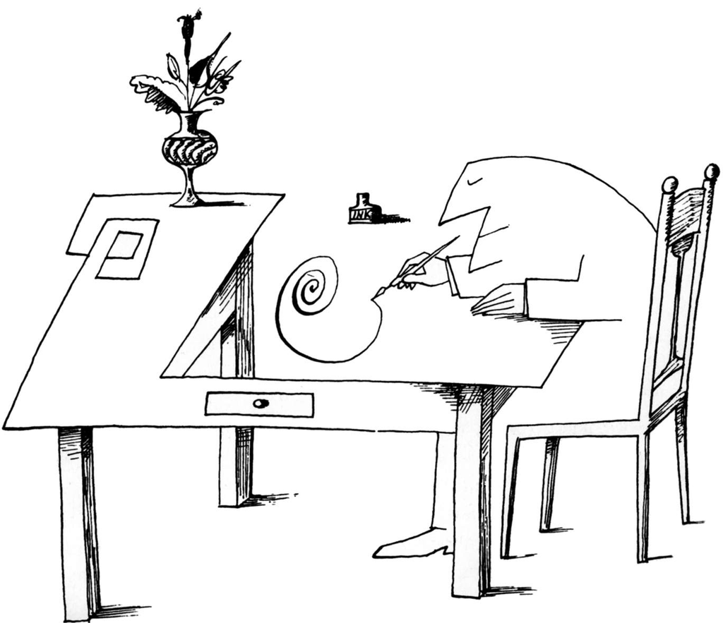

本图来源于《纽约客》1965年5月29日。

Saul Steinberg, *Untitled drawing*, ink on paper.

Originally published in *The New Yorker*, May 29,1965.

©The Saul Steinberg Foundation/Artists Rights Society (ARS), New York.

1970年，身为一名德克萨斯大学较为年轻的教授，我得到了一个难以回绝的机会： 受邀到一个美丽的地方呆上一年，享受着全职薪酬而几乎不需要做些什么——这是件不错的事情！

我的寓所位于斯坦福大学校园边的一个乡下小山丘上，那里与我最喜爱的城市旧金山仅有着不远的车距。坐落在那座美丽小山丘上的机构，是一个被称之为行为科学高等研究中心的智库。高等研究中心不仅给我提供了一年的薪酬，而且还为我安排了一间办公室，以及我所需要的文秘辅助。我可以使用那里不错的图书馆，可以享用免费午餐，只要愿意，随时有机会和那些杰出的学者们讨论问题。当然，有时我会去旧金山的剧院区闲逛，或者去高西斯拉山滑雪。如前所述，这一切没有任何附加条件。

在那里，整整一年时间我都可以随心所欲地做自己想做的事情，那么我做了点什么呢？我的选择是，将自己关在那座小山丘上的办公室里撰写这本书。为什么我会做出这样的选择？唯一的理由是，数月之前，在我的社会心理学入门课堂上，我亲口对600多名学生讲过，社会心理学是一门年轻的学科，其结果是这种似是而非的辩解使得我看起来更像一个懦夫。

请容我解释： 我们社会心理学家喜欢讲社会心理学是一门年轻的学科，与大多数自然科学（例如，生理学、天文学）相比，这无疑是一种准确的说法。当然，至少从亚里士多德（Aristotle）时代开始，敏锐的观察者们已经针对社会现象提出了一些引人关注的断言和振奋人心的假说，但是直到进入20世纪，这些断言和假说才受到了严格的检验。据我所知，第一个系统的社会心理实验是1898年垂普勒特（Triplett）完成的，他测量了竞争对成绩的影响。然而真正意义上的实验社会心理学则诞生于20世纪30年代后期，主要是因为有了库尔特·勒温（Kurt Lewin）以及他的那些杰出学生们的推动。

然而，从深层次看，对我而言声称社会心理学是一门年轻的学科，则又会陷入因极力逃避而带来的自责之中——这无疑是在恳求我的学生们不要对我们抱太大的期望。尤其是在运用已有研究成果来解决现实世界的问题时，这样说可以使我们推脱应负的责任，回避潜在的风险。从这层意义上讲，声称社会心理学是一门年轻的学科，无异于坦陈我们还不能够讲出任何重要的、有用的或者与我学生们的生活有关的事情。

但是仔细推敲之后，我意识到这类说法不仅是怯懦的，而且是一种误导。事实上，我的确不赞成社会心理学与我们的生活无关的说法。上世纪70年代如此，至今我依然持同样的观点。因此，拥有了那样一个极好的休假机会，我便下决心突破此类说法。本书的目的曾经是（而且至今仍然是），为了阐明社会心理学研究有可能帮助我们理解（甚至有可能开始帮助我们解决）困扰当代社会的一些最重要的问题。

本书的大部分材料建立在实验的基础之上，但大多数实例和例证却来源于当下所面临的社会问题。这些问题包括偏见、宣传、战争、精神错乱、攻击、骚乱以及政治动荡。这种两重性体现了我本人所持的两个偏见——也是我情有独钟的两个偏见。第一个偏见是，实验方法是我们理解复杂现象的最好方法。科学的自明之理在于，真正认识世界的唯一途径是重构： 也就是说，为了真实地理解是一种事物导致了另一种事物，仅仅靠简单的观察是远远不够的，更为重要的是，我们有责任创设一种事物以便确定它的出现的确导致了另一事物的出现。我所持的第二个偏见是，要确定通过实验所发现的因果关系是有效的，唯一途径便是将这些发现从实验室拿到现实世界中去加以验证。因此，作为一名科学家，我愿意在实验室里工作；而作为一名普通百姓，我又希望获得一扇观察周围世界的窗户。当然，这扇窗户应当是双向的： 我们也可以经常从日常生活中获得一些假设。我们可以在实验室“纯净”的条件下对这些假设进行最充分的检验；与此同时，为了尽可能防止我们的想法变得“纯净”，我们要尝试着将实验室里的发现通过这扇窗户带回到现实世界，以检验这些发现能否站得住脚。

于是，我便花费了一年的时间去做自己想做的事情： 撰写这本书。从一开始，这本书便打上了我个人的烙印，因为它包含了许多我自己关于我们这个研究领域最重要问题的想法。由此而使我决定必须用第一人称单数的方式写出来，用一种置身其间的方式来描述我所发现的，以及我所理解的这门科学的状况。（与当时的任何一种教科书不同，在《社会性动物》中，“我”这个词反复出现。）让我感到非常高兴的是，我很快便发现学生们喜欢读这本书。他们特别喜欢这种个性化的写作方式，以及这本书的内容与他们个人生活的关联。《社会性动物》成为这一领域最为流行且久盛不衰的教科书之一。其结果是，我的工作一直不能停下，也不可能停下。为了追踪这一领域的研究，适应这个世界的急剧变化，我发现有必要每隔四年对本书进行修订和更新。

1970年当我第一次开始撰写本书时，才38岁左右，还是一个踌躇满志的年轻人。而今，在2017年的夏天，在给诸位讲述这个故事的时候，我已经变成了一位头发花白的老者（你可以计算一下我的年龄）。我现在必须承认我年事已高，已经不能亲自来修订这本书了。幸运的是，我找到了本书第12版的最佳合著者，他的名字叫乔舒亚·阿伦森（Joshua Aronson）——一位杰出的、经验丰富的社会心理学家。他在实验室研究和真实世界的现场研究中都取得了引人注目的成就。他也是我的儿子。毋庸讳言，乔舒亚也有着他个人对社会心理学的看法——这是完全可以理解的。他著述颇丰，为这一版增色不少；我的长期合作者卡罗尔·塔夫里斯（Carol Tavris）也作出了同样的贡献，她继续担任这一版的编辑，以她一贯到位的拿捏处理，将我和乔舒亚的工作完美地融合在一起。她也没有为赶工期而催逼我们。

那么，这一版与之前版本有什么不同呢？我和乔舒亚重新梳理了每一章，删除了一些几年前所谓的热点研究和理论，它们没有经受住时间和重复研究的考验。我们对每一章内容进行了重组和精简，以便在整合新材料时保持叙述的清晰性。最近的研究为我们理解当下发生的事件提供了信息——例如，互联网是如何导致我们的决策过程变得更好或更糟，信息泡沫的出现以及自我确认的媒体来源如何塑造这个国家两极化的信仰和行为，脸书（Facebook）上不断出现的社会对比负面情绪，以及伊拉克和大叙利亚伊斯兰国（ISIS）等恐怖组织的崛起。然而，我强烈地感受到，将一本书“更新”并不意味着要删掉美国政府在越南和伊拉克问题上的错误案例，以及琼斯镇、哥伦拜恩、天堂之门之类的悲剧。这些事件是很久以前发生的，但其中隐含的社会心理教训却没有被很好地吸取。我希望学生们能够理解，当时发生的这些事情同样适用于解释当下发生的事情。

艾略特·阿伦森

# 致谢

这已经是本书的第12版了。在第1版中，我曾经动情地致谢我的朋友和导师利昂·费斯汀格（Leon Festinger）。不需说，我仍然感激和爱戴着这位善良而伟大的人。如果说有什么不同的话，那就是这些感觉在以往的几年里变得更加强烈了。我喜欢做他的学生，我也想永远做他的学生。1989年利昂的去世，标志着社会心理学一个重要时代的结束。不仅是我们这些与他相识并爱戴他的人，每一位被他的研究和理论所引导的人，包括每一位曾经学习过社会心理学的人，都非常怀念他。

随着本书的岁月已久以及我本人年龄的增长，我也越来越意识到自己从学生们身上获益匪浅。每隔四年，当我着手对本书进行修订时，我都会惊奇地发现这本书中已经不单单是我个人的思想了。的确，这些思想是我和我的学生们一起发展的。在过去的五十年里，我有幸招到了许多出色的学生，从我1960年最初的研究助手默瑞尔·卡尔史密斯(Merrill Carlsmith)、托尼·格林沃德(Tony Greenwald)和约翰·达利（John Darley），到我在加利福尼亚大学圣克鲁斯分校的学生们。从他们身上我学到了很多东西，我由衷地感谢他们的帮助。我也很愿意与一些极具天赋的同事们交流并吸取他们的思想。其中需要特别提到的两位是安东尼·普莱特肯尼斯(Anthony Pratkanis)和卡罗尔·塔夫里斯，他们为本书的不断完善作出了相当大的贡献。在此我对他们的无私支持表示衷心的感谢。

就这一版而言，我要特别感谢我们的执行编辑克里斯汀娜·卡顿（Christine Cardone），感谢她对本书所付出的热情、真诚和不懈的承诺，感谢她的耐心和高效。我还要感谢布拉德·布什曼（Brad Bushman）、多纳尔·卡斯顿（Donal Carlston）、伊莱·芬克尔（Eli Finkel）、杰克·多维迪奥（Jack Dovidio）和马修·麦格龙（Matthew McGlone），他们慷慨地对各章节进行了审读，并就如何修改完善相关章节提出了睿智的建议。

乔舒亚要感谢卡罗尔·塔夫里斯的专业编辑和不竭的灵感，感谢斯泰西（Stacey）、伊莉安娜（Eliana）和利奥·阿伦森（Leo Aronson）的爱、支持和耐心。我们也感谢杰夫（Jeff）和斯宾塞·特威迪（Spencer Tweedy）。向以下作出了宝贵贡献的学生和研究助理们致以衷心感谢： 乔舒亚·阿德勒（Joshua Adler）、佩奇·阿莱尼克（Paige Alenick）、罗姆·布拉特（Rotem Blatt）、克里斯汀娜·克罗斯比（Christina Crosby）、雷纳·爱泼斯坦（Rayna Epstein）、麦迪逊·卡茨（Madison Katz）、杰西卡·马尔（Jessica Mar）、卡亚·门德尔松（Kaya Mendelsohn）、斯科特·孟格比尔（Scott Mengebier）、艾希礼·潘诺金（Ashley Panookin）、艾拉·昆兰（Ella Quinlan）、安吉拉·斯皮尔斯（Angela Spears）、扎卡里·威廉姆斯（Zachary Williams）和凯西·于（Kathy Yu）。

此外，我们要感谢威廉·德龙（William Dragon）在讲师资源方面所做的工作，还要感谢对第11版进行审读并为本次修订提供反馈的教授们： 休斯顿大学市中心分校的克里斯汀·J·安德森（Kristin J.Anderson）、芝加哥洛约拉大学的弗雷德·布莱恩特（Fred Bryant）、俄亥俄州立大学和阿姆斯特丹自由大学的布拉德·J·布什曼、普渡大学的唐纳·E·卡尔斯顿（Donal E.Carlston）、耶鲁大学的约翰·F·多维迪奥（John F.Dovidio）、康奈尔大学的威廉·德龙、西北大学的伊莱·芬克尔（Eli Finkel）、佩珀代因大学的朱迪·霍（Judy Ho）、北达科他大学的艾莉森·E·凯利（Alison E.Kelly）、德克萨斯大学奥斯汀分校的马修·麦格龙（Matthew McGlone）、北亚利桑那大学的安杰里·米什拉（Anjali Mishra）、德克萨斯农工大学特克萨卡纳分校的布兰迪·摩尔（Brandy Moore）、马萨诸塞大学波士顿分校的马库斯·D·帕特森（Marcus D.Patterson）和鲍尔州立大学的迈克尔·泰格勒（Michael J.Tagler）。

# 社会性动物

从本质上讲，人是一种社会性动物；那些生来离群索居的个体，要么不值得我们关注，要么不是人类。社会从本质上看是先于个体而存在的。那些不能过公共生活，或者可以自给自足不需要过公共生活，因而不参与社会的，要么是兽类，要么是上帝。

亚里士多德

《政治学》，公元前328年

- 1 什么是社会心理学
- 2 社会认知
- 3 自我辩护
- 4 从众
- 5 大众传播、宣传与说服
- 6 人类的攻击性
- 7 偏见
- 8 喜欢、爱与联系
- 9 作为一门科学的社会心理学
- 术语表
- 英文注释
- 英文人名索引
- 英文主题索引

# 1 什么是社会心理学

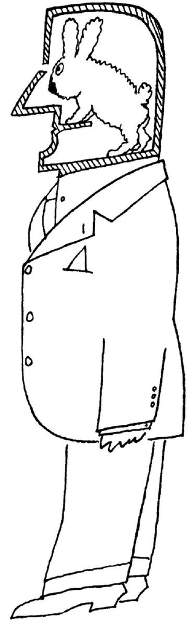

本图来源于《纽约客》1958年11月1日。

Saul Steinberg, *Untitled drawing*, ink on paper.

Originally published in *The New Yorker*, November 1,1958.

©The Saul Steinberg Foundation/Artists Rights Society (ARS), New York

据我所知，亚里士多德是第一位将我们这个物种称为“社会性动物”的重要思想家。他当然是对的，但这种说法意味着什么呢？从蚂蚁、蜜蜂到猴子、猿类，许多其他生物也具有“社会性”。作为社会性动物，人类与它们有何不同？研究人类这样一种令人困惑、富有创造性而又容易被激怒物种的社会心理学，又有哪些独特之处？

我的职业生涯，一直是一名社会心理学家。在我进入这个领域之前，甚至在我了解这个领域之前，我就是一名业余社会心理学家了，我渴望搞清楚人类行为的奥秘。20世纪40年代，我在马萨诸塞州里维尔的一个蓝领小镇长大，那时我还是个犹太男孩，我想知道为什么一些信奉天主教的孩子会用反犹太口号嘲弄我，偶尔还会粗暴地对待我。我的儿子乔舒亚，在20世纪60年代经历了艰难的小学生活，他想知道为什么有些孩子在课堂上能够很好成长，而另一些孩子则被竞争压力和教育体制所窒息。这些早期的经历给我们带来了巨大的痛苦，也把我们带到了本书你们将要学习到的令人兴奋的研究领域：这个研究领域提供了对人类社会生活的科学理解，更为重要的是，提供了改进人类社会的方法。

有很多关于社会心理学的定义，但在论及我所心仪的社会心理学定义之前，让我先提供一些人类作为社会性动物行动的具体事例：

一个叫萨姆（Sam）的大学生，正在与四个熟识的同学一起收看一位总统候选人的电视演讲。这位候选人给萨姆留下了很好的印象；他看起来很真诚，所以与他的对手相比，萨姆更喜欢这位候选人。演讲结束后，其中一位同学声称自己讨厌这位候选人，认为他是一个十足的骗子，所以她倾向于另一位候选人。其余几个人都随声附和。萨姆看起来很为难而且有点苦恼。最终，他对他的朋友们低声说道，“我想，他似乎不如我所期望的那样真诚”。

一个10岁的女孩每天早上都要喝下两大碗威提司麦片粥<sup>[1]</sup>，原因是奥运游泳冠军迈克尔·菲尔普斯（Michael Phelps）印在产品包装盒上。这位冠军暗示，他拥有非凡的运动能力一定程度上是因为食用了这种特殊品牌的麦片。

一位店主在蒙大拿州的一个小镇上生活了一辈子，他从来没有和任何一位穆斯林实际接触过，然而他仍然“知道”穆斯林不是美国人，不忠诚，而且很可能是恐怖分子。

查利（Charlie）是一位高年级的高中生，最近他搬到了一座新城市。以往他人缘很好，而今一切都改变了。尽管新学校的孩子们对他还算客气，但他们并不特别友好。他感到孤独、缺乏安全感、难以引人注意。一天，在午餐的时候，他恰好和同班的两位女生坐同一张餐桌。其中的一位热情、迷人、漂亮、活泼，几周来他一直对这位女生单相思，期盼有机会能和她交谈。而另外一位女生则远谈不上有什么吸引力。查利却对自己心仪的女生不加理睬，而开始与她的那位同伴真诚地交谈起来。

2016年12月4日，来自北卡罗莱纳州的28岁男子埃德加·韦尔奇（Edgar Welch）走进华盛顿特区一家非常有名的披萨店“彗星乒乓”，用步枪开了三枪。没有人受到伤害。韦尔奇告诉警方，他在网上了解到这家餐厅窝藏儿童性奴，他想亲眼看看他们是否在那里。在没有找到证明自己想法的证据后，他投降了。韦尔奇的想法源自总统选举期间疯传的一个假新闻。一个白人至上主义者的推特账户声称，纽约市警方发现了一个与民主党成员有关的恋童癖组织，好像“彗星乒乓”披萨店是他们的大本营。这个故事被虚假新闻网站广为传播。韦尔奇后来说，他对自己的所作所为感到后悔，但他仍然相信那个假新闻。

卡娅（Kaya）二年级时被要求说出她最喜欢的科目。“数学”，她在问卷上写道。一年后，她所在的三年级班级也被安排了类似的调查。这次的问卷问到：“你最不喜欢的科目是什么？”她写道，“数学”。一年之内，卡娅从一个对数学感到兴奋、有信心的学生变成了一个惧怕数学的学生。

1999年4月20日，在科罗拉多州利特尔顿市哥伦拜恩中学的走廊和教室里，回荡着枪击声。两名持有杀伤性武器和爆炸装置的学生，在狂怒中杀死了一位教师和他们的几位同学。接着，他们将枪口对准了自己。硝烟过后，包括枪击者在内的15人当场毙命，另有23人被送往医院，其中多人重伤。在哥伦拜恩中学大屠杀发生后的近二十年里，数百名美国青春期男孩在校园里实施了同样可怕的大规模枪击。曾经不可思议的事情已经司空见惯。

史蒂夫（Steve）是一名大学四年级学生，他开车谨慎、甚至有点保守，独自一人驾车时，他可以成为安全驾驶宣传视频里的演员。然而，每当有两三个朋友和他一起在车上时，史蒂夫的行为就会变得危险起来：当看到半个街区外的灯开始变黄时，他经常会猛踩油门，希望能够在交通灯变红之前冲过十字路口。

1939年，贪婪的德国商人奥斯卡·辛德勒（Oskar Schindler）加入了纳粹党，并开始从野蛮的希特勒第三帝国统治时期犹太人的灾难中获利。在奥斯维辛集中营盘剥了犹太囚犯数年之后，辛德勒改变了主意，开始利用他的工厂来拯救一千多名犹太人。长篇小说和奥斯卡获奖影片《辛德勒的名单》里讲述了这样一个故事：辛德勒冒着生命危险，把所有的财富都用于拯救他人。看完这部影片，我的儿子乔舒亚从电影院走出来，恰好碰到一个乞丐向他讨要零钱。乔舒亚以往不去理会那些寻求救济的人，而且那时他还是一个经济拮据的学生。此时，他却把手伸进口袋，掏出所有的零钱，连数都不数地给了那个乞丐。

道格拉斯·麦凯恩（Douglas McCain）在明尼苏达州长大，高中时打篮球，想成为一名说唱歌手。他的朋友都认为他是个“头脑简单的人”、“善良的小伙子”、“好人”。因此，当听说33岁的麦凯恩加入了激进的恐怖组织ISIS与自己的国家开战并在中东战死时，他的朋友们感到震惊。数以千计的来自西方国家的普通青年男女离开了自己的家园，成为伊斯兰圣战分子，在叙利亚和伊拉克战斗乃至战死。

20世纪40年代，我还在上小学。我有一个很亲密的美国黑人朋友叫乔治·伍兹（George Woods）。当时，乔治把自己称为“有色人种男孩”，并向我吐露，和当时的许多黑人孩子一样，他觉得自己不如白人朋友。<sup>1</sup>有许多原因导致他持有这种感受，亲身感受到的来自白人主流社会的偏见，直接影响了他。但乔治的自卑感也来自于间接的影响，比如广播和电视中对非洲裔美国成年人的描述——懒惰、无知，甚至残忍——而他们还是天真的孩子，还相当可爱。如果影片中有黑人男性演员，他们只会被描绘成典型的“有色人种”，通常是司机或粗鄙的工人，经常会被人取笑。想象一下乔治和他的白人朋友一起观看这类种族主义影片时的感受吧。然而，他却从没告诉过我他的感受。

而今，一切都已改变。乔治·伍兹的孙儿们成长在21世纪，生活在一个与他不同的世界里。他绝不会想到有这样一天：黑人演员会扮演庄重的角色并赢得奥斯卡奖；种族隔离和歧视成为非法；黑人能够从事所有职业，包括担任美国总统。然而，我们不应陶醉于这样一种信念，即变革是沿着线性的、人道主义的方向前进的。乔治·伍兹的孙儿们可能不会像他们的祖父那样受到同等程度的歧视，但种族偏见仍在继续。大多数非洲裔美国人都知道“黑人购物”经历，这意味着销售人员会对他们的信誉提出质疑，怀疑他们会偷东西，甚至拒绝为他们提供服务。尤其是年轻的黑人男性继续成为“黑人驾车”的受害者，因为微不足道的理由甚至没有任何理由被叫停。还有“黑人独行”，就像16岁的特雷文·马丁（Trayvon Martin）被住在附近的一个叫乔治·齐默尔曼（George Zimmerman）的看守队长跟踪并杀死一样。<sup>2</sup>齐默尔曼注意到一个穿着连帽衫的高大黑人少年，他以为这可能是一个持有武器的危险罪犯，而事实并非如此：特雷文不过是一个从便利店独行回家的普通高中生，手里拿着一杯冰茶和一袋快餐。

**社会心理学的定义**

上述事例展示的都是社会心理情境。尽管它们看起来各不相同，但其中都包含着一个共同的因素：社会影响。

萨姆的朋友对那位总统候选人品行的意见影响了萨姆的判断（或者至少他所做出的公开声明考虑到了这种判断）。那位奥运冠军对我们年轻的威提司麦片食用者的影响，则是在有意策划以激发她说服自己的父母去购买威提司麦片。那位蒙大拿州的店主并不是生来就对穆斯林有着根深蒂固的刻板印象，而是有人以某种方式灌输给他的。史蒂夫的冒险驾驶肯定是由于他的朋友在场而受到了影响，但这又是如何做到的呢？卡娅从数学爱好者转变为数学惧怕者并不罕见，特别是在美国，数学在传统上被认为是天赋异禀和“男孩的事情”。查利不理会他的梦中女孩，这与他对自己的感觉以及他对哪位女士不太可能拒绝自己的假定有关。被拒绝是人类最痛苦的经历之一，会导致各种各样的自我挫败和破坏行为，从暴饮暴食到暴力——就像哥伦拜恩校园枪击事件那样。他人在场或榜样的作用，无论是来自现实生活，还是来自类似《辛德勒的名单》的影片，都能激发出积极的情感和慷慨好施的举动，就像它能让我平时一贯节俭的儿子把他所有的现金都给了那个乞丐一样。

社会心理学也可以解决一些最令人不安的问题，这些问题困扰着社会，来自种族主义以及其他形式的偏见导致了像ISIS这样的恐怖组织成功招募到年轻人，而许多年轻人与伊斯兰教没有任何精神上或家庭方面的联系。是什么力量说服他们离开自己的家园和家庭，成为“自杀式炸弹”？答案包括年龄、人格动力、社会认同、说服策略，以及随着本书的展开你将会了解到的其他一些强有力的因素。你将会发现，ISIS利用了许多相同的影响策略，这些策略被那些出色的教练用来组建获胜的运动队，被那些成功的小学校长用来提高学生的成绩。洞察人们的社会动机，可以用来做好事，可以用来做坏事，可以用来赢得电视真人秀比赛，可以用来做任何与社会影响相关的事情——这几乎是所有事情。

因此，我们将**社会心理学**定义为：他人真实的、想象的或暗示的存在，对我们的思想、情感、信仰和行为的影响，以及我们如何影响他人的科学研究。

我们是如何受到影响的？为什么我们要接受信息，或者换句话说，信息对我们有什么好处？什么样的社会动机使我们容易受到他人的想法、言论和行为的影响？哪些因素会增加或减少社会信息的有效性？哪些因素增加或减少了社会影响力的持久性？适用于人们对某位参议员候选人看法的同样原则，是否同样适用于幼儿更喜欢的某门学习科目？一个人是怎样喜欢上另外一个人的？是否同样的心理过程导致我们选择了普通麦片而不是即食麦片？一个人如何对某个民族、某种宗教或种族群体产生偏见？偏见与喜欢类似？还是恰恰相反，涉及另一种完全不同的心理过程？

许多人会对诸如此类的问题感兴趣。因为我们都花费了大量的时间与其他人交流——受他人的影响；影响他人；高兴、开心、悲伤、厌恶、沮丧，或者被激怒——我们的天性就是对人们为什么做他们所做的事情提出假设。从这个意义上讲，我们每个人都是业余的社会心理学家。尽管大多数业余社会心理学家在与他人互动时会对这些假设进行检验，并达到他们自己满意的结果，但这类偶然的“检验”缺乏细致的科学研究所具有的严谨性和公正性。

可以肯定的是，有时科学研究的结果与大多数人已经了解的事实相吻合。这一点并不令人惊奇，传统智慧通常源自于经受住时间考验的敏锐观察。但有时传统智慧也会将人们引入歧途。事实上，当你读到本书中讨论的一些科学研究结果时，你或许偶尔会想，“这是显而易见的——为什么他们花时间和金钱去‘发现’那样一个结果？我的祖母早已告诉过我”。可能你的祖母曾经告诉过你，但也可能是你的事后聪明偏见。所谓**事后聪明偏见**指的是，一旦我们知道某一事件的结果，我们往往高估自己的预测能力。这正是为什么我们很容易“周一早上担任枢纽四分卫”、为什么我们会作出“二十比二十”的“事后诸葛亮式”预测的原因。许多研究已经证明了这种偏见，从预测选举结果（我一直知道他会赢，即使民意测验没有这么预测），到预测一个特定的社会心理学实验会出现何种结果。（很明显被试会服从那些残忍的命令）。的确，社会心理学研究发现，与被要求预测将发生什么的大学生相比，那些被告知在研究中发生了什么的大学生会认为所发生的一切更为显而易见。<sup>3</sup>一旦出现事后聪明偏见，一切都会变得显而易见。

社会心理学家之所以要进行科学研究，是因为我们意识到许多人们认为理所当然的事情，我们研究的结果却证明是错误的，或者与人们最初所认为的有所不同。例如，人们一般会认为：那些做了被禁止的、非法的、弄巧成拙的事情而受到惩罚威胁的人，最终可能会停止他们的行为；而且惩罚越严厉，他们服从的可能性越大。毕竟，他们会将这类行为与恐惧或痛苦联系起来。但付诸研究时，这个假设却被证明是完全错误的。当面对着轻微惩罚的威胁时，人们会讨厌被禁止的行为；而那些受到严重威胁的人，更可能受到被禁止的活动的吸引。同样，从自身的经验出发，我们大多数人会猜测，假如我们无意中（背后）听到某人在讲我们的好话，在其他条件都相同的情况下，我们会喜欢这个人。这一点已经被证明是正确的。但同样正确的是，假如我们无意中听到的不完全是好话，我们会更加喜欢这个人。在后面的章节中我们会对这一现象作进一步探讨。

在理解社会性动物方面，专业社会心理学家比大多数业余社会心理学家具有更多的有利条件。尽管像业余社会心理学家一样，我们也往往是从仔细观察开始的，但我们并不会就此止步。我们不必等待事情发生后去观察人们如何反应；我们可以让事情发生；我们可以进行实验，在实验中让许多人面对特定的事件（例如，严重的威胁或者轻微的威胁；无意中听到好话或者无意中既听到好话又听到令人不愉快的话）。不仅如此，除了所要研究的具体因素，我们可以在特定的情境下使一切保持不变。然后，我们可以比业余社会心理学家获得更为精确而丰富的材料，并在此基础上得出结论。而后者则只能依靠对随机发生事件的观察，并且不能排除许多同时发生的事情。

本书所呈现的所有材料几乎都有其实验依据。由于这个原因，以下两点特别重要：（1）读者需了解一项社会心理学实验的构成要素；（2）读者需了解与这种探索联系在一起的那些有利因素、不利因素、伦理难题、激动人心之处、棘手之处以及为之痛心之处。虽然了解实验方法是重要的，但它决不对理解我在本书中所呈现的大量材料起决定作用。为此，本书最后一章所安排的内容是“作为一门科学的社会心理学”。对读者来讲，可以在阅读其他章节之前先阅读该章（假如你愿意在钻研大量的材料之前先理解技术性问题的话），也可以在阅读本书的过程中，在任何感兴趣的地方随时阅读该章内容。

**做出疯狂举动的人未必疯狂**

社会心理学家研究影响人们行为的社会情境。有时，这些自然的情境会具有相当大的压力，迫使人们按照一种很容易被归类为变态的方式去行动。这里所讲的人们，指的是为数众多的人。在我看来，将这些人归类为精神病患者并不能增加我们对人类行为的理解。更为有益的做法是尽力去了解特定情境的性质，以及产生特定行为的过程。这就将我们引向了阿伦森第一定律：

**做出疯狂举动的人未必疯狂。**

让我们来举一个例子，那个手持步枪进入“彗星乒乓”披萨店的人，按他的说法，是打算“自行调查”那里是否有被绑架儿童。难道他疯了吗？如果他真的希望搞清真相，为什么不接受警察部门、联邦调查局以及其他可靠来源所提供的调查结果？这类调查会彻底查清是否存在那些指控。如果他是个疯子，那么其他成千上万的人也是如此，这些人相信这则假新闻，其中许多人对“彗星乒乓”披萨店和其他一些被认为与那个“组织”有关的餐馆进行了恶意威胁，对店主和顾客们进行了骚扰。“彗星乒乓”披萨店的店主告诉《纽约时报》：“正是由于这个疯狂的、凭空捏造的假消息，我们不断受到攻击。那段日子里我几乎什么都做不下去，只是想努力把这件事情处理好，以免我的员工和朋友们受到恐吓。”<sup>4</sup>是什么导致那些人相信这则“疯狂”的假消息？尽管有确凿的证据表明事实并非如此，为什么他们仍然会坚持这种看法？在本书后面的章节里，我们将考察这类态度如何产生以及为什么无论何种情况下人们都倾向于坚持。我们还会了解到如何来克服这类偏见。

社会心理学的一个重要发现是，人们倾向于通过赋予过错者某种性格特质来解释其令人厌恶的行为，比如“精神病”、“虐待狂”或“邪恶之人”。大多数人，特别是我们这些生活在西方文化背景下的人，会在无意之中自发地这样去做，通过这种方式对各类信息加以组织和分类，从而获得对事件的控制感。这种有关人类行为的人格倾向论基于以下假设：做出疯狂举动的人一定拥有某种疯狂的人格，做出愚蠢事情的人一定是愚蠢的，只有邪恶的人才会做出邪恶的事情，做好事的人一定是善良的，诸如此类。这样的思考方式颇能迎合人们的想法，因为这样可以帮助我们把那些做坏事的坏人和我们这些“好人”区分开来。当我们想到令人厌恶的行为时，这种想法给我们以安慰——因为，作为好人，我们绝不会那样去做。

然而，这种假设过于简单化，往往是错误的。正如您在第2章中将会看到的，我们会为此付出代价。人格倾向论会令我们自以为是，按照这种假设，我们在外部压力下是无懈可击的——而事实上外部压力往往会导致我们做出愚蠢、疯狂或残忍的举动。这种假设使得人们不再关注环境的改善，而是狭隘地去关注人格。例如，经理担心员工是否会偷窃？会让每个员工接受一项人格测验，试着判断将来谁会偷窃，而不去关注员工是否会因为工作强度过大、心生怨恨或者报酬太低而偷窃。有人担心学生是否会变得暴力？那就让每个学生接受一项人格测验，并试着预测哪个不快乐或受到了欺负的孩子可能会在某一天爆发，而不去关注这类孩子每天都在挣扎中度过的那个世界。

当然，我并不是说精神病就不存在。有些人格特质和心理疾病的确会影响人类的行为。我也不是说所有人都是一样的，会对同一种社会压力作出完全相同的反应。我想说的是，有些情景会引发我们这些“正常”成年人中令人惊奇的大部分人以一些意想不到的、让人倒胃口的，有时甚至是变态的方式去行动。至关重要的是要明白这些情景中的什么要素会导致令人不悦的、破坏性的行为。

或许我们可以通过一个案例很好地说明这一点。什么样的人会杀死自己的孩子呢？疯子？绝望之人？邪恶之徒？这类人一定存在心理上的问题。1977年，旧金山人民圣殿教的教主吉姆·琼斯（Jim Jones）牧师，说服他的追随者们搬迁到南美洲的圭亚那，在那里建设了一个人间天堂——一个不同种族背景的人可以和谐生活的乌托邦社区。1978年，当这个组织受到国会调查的威胁时，琼斯决定结束这场危机，要求组织成员采取“革命行动”：杀死自己的孩子，然后自杀。他们准备了几大桶毒药，在零星的抗议和反对声中，母亲和父亲们给这些婴儿和儿童喂服了这种致命的混合物，然后自己喝下去，躺下来等待死亡。

当某个人杀死自己的孩子时，我们有理由质疑他是否患有精神病。而当613对父母在某个地方一起杀死他们的孩子时，我们不能再局限于考察他们的精神状况和个性特征，而要考虑导致他们做出这种举动的情景特征。当然，我们可以说他们疯了，也可以为我们永远不会做出他们那样的举动而沾沾自喜。然而，在这些人搬迁到圭亚那之前，他们的邻居、朋友或者亲戚没有人不会将他们视为普通的、有理智的人，他们属于一个相互支持、紧密团结的教会团体。正如人们已经普遍意识到的，“琼斯城大屠杀”提醒我们，社会影响会决定人们的想法、感受和行为，这种影响往往是巨大而隐秘的。

帮助我们理解这种极为复杂的人类行为的情境性的观点——社会情境影响我们行为的许多方面——是社会心理学的重要贡献，我希望社会心理学的价值会在接下来的章节中显现出来。

[1] 美国通用磨坊公司1926年推出的一种麦片品牌，后来逐渐成为一种全球著名品牌，能够成为威提司麦片的代言人是许多体育明星梦寐以求的目标。——译者注

# 2 社会认知

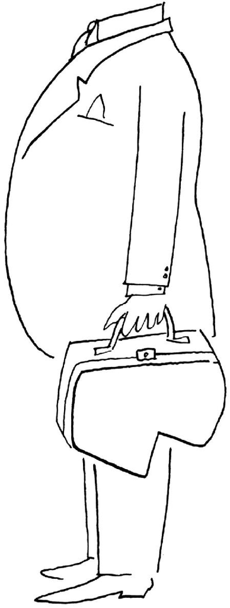

本图来源于《纽约客》1953年8月29日。

Saul Steinberg, *Untitled drawing*, ink on paper.

Originally published in *The New Yorker*, August 29,1953.

©The Saul Steinberg Foundation/Artists Rights Society (ARS), New York

在中世纪的欧洲，行人沿街行走时经常会被人的排泄物击中。那时的市民有时会将便壶里的尿液和粪便从窗户倒向当街。污水会在那里滋生瘟疫和疾病，直到街道清洁工清理掉——通常它们被用作肥料。对现代人来说，这种处理方式看起来很愚蠢也很粗俗，尤其是当了解到一些早期文明——像希腊人、罗马人和玛雅人——已经拥有了更好的排污系统时，人们更难理解。这些早期文明已经有了室内管道，甚至有了可清洗的厕所。

为什么要用夜壶来取代室内管道呢？这是因为当时的人们相信了很多显而易见不真实的事情：赤身裸体是罪孽深重的，当一个人赤身裸体时会遭到恶魔的攻击，邪恶的灵魂会让人生病。<sup>1</sup>罗马人会在他们漂亮的公共浴池里天天沐浴，这一做法被劝阻了，取而代之的是洗手、洗脸，以及清洗身体其他可以公开示人的部位。这种迷信导致了两个显而易见的后果。首先，几乎所有的东西和每个人闻起来都很糟糕。正如一位作家所描述的那样，“农民和牧师、学徒和他主人的妻子，都散发着臭气；整个贵族阶级都臭，甚至国王也散发出臭气，他臭得像头狮子，而王后臭得像一只老母山羊，夏天和冬天都是如此”。<sup>2</sup>其次，室内浴场最终失修，管道维修技术在民间失传。于是，一段时间内，原始的下水道系统和夜壶便成了解决问题的最佳选择。经历了几百年的时间，“精神”导致疾病的理论才向科学屈服，微生物被确认为导致人类疾病的隐形祸端。

在这里，我无意探讨中世纪的那些想法形成的内在机理，也不想展示现代社会在卫生保健方面所取得的进步。相反，我讲述这个故事是为了引出一个更大的问题：我们现代人的行为，在多大程度上和几个世纪前的夜壶使用者是一致的？每一代人都可以回过头来审视他们祖先的愚蠢行为，找到很多理由来加以解释并自鸣得意。在维多利亚时代，那些医生们提到人们害怕洗澡和鬼魂便会加以嘲笑，但他们仍然会相信自己那个时代的荒谬之论。一些医学杂志警告，女性（而不是男性）在阅读小说时会存在引发疾病、不育甚至精神错乱的危险！<sup>3</sup>

我们人类喜欢把自己看作是理性的动物。（我们自以为是地称自己为智人，毕竟，人类是明智的。）但我们也会持有许多不明智的信念，并因此而吃尽苦头。数百万人仍然拒绝相信“人类正在造成全球变暖和大规模气候变化”的压倒性科学证据。有人会说，“这是有的国家制造的一个骗局”；也有人会说，“当然，地球正在变暖，但并非人类所为”。结果是，冰川不断融化，海平面不断上升，风暴更加频繁，昆虫传播的疾病激增，每年有数千人死于这些变化。在美国，成千上万的人仍然否认“儿童疫苗不会导致自闭症”的压倒性科学证据，许多父母拒绝给他们的孩子接种疫苗。结果是，在未接种疫苗的人群中，麻疹和百日咳的死亡率上升；在已经被人们认为根除的时候，这些致命的疾病却又会卷土重来。

**社会认知**是社会心理学的一个主要领域。这个研究领域关注的是：人们如何相信自己所做的事情；人们如何解释、记忆、预测、作出决定、评价自己和他人；以及为什么这些过程经常会产生错误。尽管人类可以正当地宣称自己是地球上最具适应性、最聪明、最成功的物种，但我们仍然很容易产生误解、冲突、错误，出现那些由来已久的种种偏见，以及今天对气候科学和疫苗所持的否定态度。

本章将讲述我们的“社会大脑”的故事。在进化的漫长历史中，“社会大脑”为人类生活带来了巨大的悖论和困境。进化赋予人类以大脑，使我们能够很好地适应小型狩猎采集的群体生活，为人们提供了有效的认知捷径和倾向性，使生活更容易且更安全，使人们倾向于合作和相互关心。然而，当我们对当今这个复杂的、相互联系的、多元文化的星球进行考察时，我们可能会发现这些机制往往会适得其反，导致我们作出错误的决定，固守着我们的偏见，并因偏见和仇恨而相互战斗。

假如你认为可以用我们的理性力量来确定真相的话，当你看到人们因与你的观点相异而对事实采取视而不见的态度时，你便会感到沮丧。在很多时候，我们采用理性、事实和批判性分析，不是为了形成我们的观点，而是为了确证我们已经看到、感觉到或者相信的东西。正如小说家阿娜伊斯·宁（Anais Nin）所言：“我们看到的并非事物的本来面目；而是我们所看到的事物的本来面目。”<sup>4</sup>在很大程度上，我们如何理解世界取决于我们的直觉、我们的个性、我们感知世界的方式，以及一系列基础性的社会动机。

**进化与偏执的大脑**

几个世纪以来，哲学家们一直认为人类的认知是完全理性的：所有人都试图尽其所能去做正确的事情，保持正确的信仰，在最大限度地减少痛苦的同时最大限度地享受快乐。

杰里米·边沁（Jeremy Bentham，1748-1832）是这一观点的重要支持者之一。他写道，人们会通过权衡事物给自己带来的幸福感，来确定事物的善恶与对错。<sup>5</sup>人们通过幸福感计算来确定他们行为或选择的道德定位——好的或坏的、对的或错的。假定我想购买一部新车，在决定购买厂家和车型的过程中，我将会把每个品牌在款式设计、内部舒适程度、发动机功率等方面可能给我带来的快乐相加，然后减去我将来每月需要支付的费用、频繁加油所需的支出等因素可能给我带来的痛苦。这样，我就会选择能够给我带来最大快乐和最少痛苦的型号。在边沁看来，“追求最大多数人的最大幸福”是政府的职责，而且需要有经济制度来加以保证。另外一些人对此也持赞同的观点。边沁权衡幸福的思想，已经成为现代资本主义的基本假定。

普通人会这样去思考问题吗？当然，有时候的确如此。我们中的许多人会采纳本杰明·富兰克林（Benjamin Franklin）有关如何做出明智决定的建议——写下它们的利弊。然而，这种方法要求人们不仅要获取准确、有用的信息，而且还要具备理性思考的能力。但这些情况在日常生活中并不常见。这样讲主要有两个原因。

首先，没有人能够拥有观察世界的“上帝之眼”——可以全知而且无偏地进行观察。让我们以买车为例，我不可能了解这辆车的优缺点，因为我听说过一些有关汽车经销商以及他们的营销策略的糟糕故事。如果这种车是一种新的款式，便根本不可能有长期的维修资料。而且，我对这种车的意见也只局限于我个人的有限看法；我基本上是从广告人员那里听说这种车的，这些人有目的地夸大了车的正面特征。我对这种车的体验也十分有限，只是在经销商的监督之下试开了10分钟，没有在各种危险路况和复杂天气条件下的长期驾驶经历。如果类似买车这样普通的事情可能会有许多信息遗漏或误导的话，那么不妨设想一下，当我们需要做出一些重大决定（譬如，是结婚还是分手，或者选择哪种工作）时，我们将会面临何种困难。

其次，即便数据可用而且可靠，我也没有时间对遇到的每个问题进行全面分析。假如我继续下去，花10个小时来研究和权衡购买这辆车带来的幸福感。但与此同时，我还有许多其他的决定要做：享用午餐时我该做些什么？我该如何修改我的讲稿？哪个求职者最适合聘用？我女儿真的需要那种昂贵的牙齿矫正器吗？我不可能花很多时间列出一天里必须要作出每一个决定的利弊，这一点你也不可能做到。

这就是为什么我们大多数人都是**认知吝啬者**：我们总是寻求保存认知（心理）能量并将复杂事物简单化处理的方法。我们会利用经验法则去走捷径。我们会忽略一些信息以减少认知负担；我们会过度利用一些信息以避免去寻找更多的信息；或者我们只是按照最初的直觉，接受一个不够完美的选择，因为它已经足够好了。<sup>6</sup>认知吝啬者的策略可能是有效的，有时我们的直觉可以帮助我们作出较好的决策。但是如果不加以限制，这些策略也会导致严重的偏误。

**有关思考的思维是如何进化的** 虽然心理学家的研究在过去的几十年里取得了巨大的进展，但是还没有人能够完全理解：大脑如何产生有意识的体验，为什么会产生有意识的体验，或者说大脑如何产生了自我意识。当描绘我们不完全理解的事物时，我们会使用隐喻；我们会将我们不理解的事物与我们已经理解的事物加以比较。隐喻对我们会有帮助，但是如果不加批判地接受，也可能带来误导。

当人们试图解释大脑如何工作时，他们总会使用基于当时科技的隐喻。柏拉图曾做过一个有名的比喻，将人类的精神比作一个驾驭着两匹马拉战车的车夫，一匹马代表理性，另一匹马代表欲望。在19世纪，大脑被比作电报，在20世纪被比作电话总机。随着计算机的出现，心理学家开始把大脑的功能说成可以与Mac或PC相媲美。就像计算机一样，人脑被认为可以存储和检索记忆；偏离理性思维的行为通常被描述为操作系统中的“错误”，或者我们“有限的处理能力”的结果，或者由于压力而导致“认知带宽”减少。<sup>7</sup>

计算机为描绘某些大脑功能和局限性提供了一个合适的词汇，但我们的大脑并不像计算机那样真正存储记忆或处理信息。此外，由于计算机不必担心未来，不必害怕死亡或被拒绝，不能体验快乐、悲伤、嫉妒或任何其他情绪，因此用计算机来隐喻大脑，对精神生活的描绘是不完整和不能令人满意的。

一个由来已久的隐喻被证明特别具有误导性：约翰·洛克（John Locke）在16世纪把思想描绘成一张白板。这个隐喻把我们的思想、性格和特点描绘成完全由学习和经验塑造的，就像在一张空白纸上作画一样。这个隐喻持续了几个世纪，在19世纪初被精神分析心理学和行为主义心理学热情地加以接受。假如你害羞，那是因为你和你父母的不愉快经历，以及你所受到的奖励和惩罚，使你感到害羞。行为主义心理学创始人约翰·华生（John Watson）声称，只要对环境有足够的控制，奖惩结合得当，他就可以把一个随机挑选的健康婴儿塑造成几乎任何一种人：医生、律师、乞丐或者小偷。<sup>8</sup>尽管华生确实训练了一个婴儿，使之见到一只兔子都会惊恐，但幸运的是，他再也没有尝试通过长期实验将婴儿变成乞丐或者小偷。

尽管诸如“你可以成为任何你想成为的人”的有关人类可塑性的极端观点在当今社会中依然存在，但是这种观点在心理学家中已经没有了市场，因为有科学证据表明存在遗传倾向。同卵双胞胎出生后分开抚养，在不同的家庭中长大，他们在行为举止、习惯、态度甚至政治观点上仍然存在显著的相似性；在同一个家庭长大的兄弟姐妹在性格上也不会变得更相似。<sup>9</sup>婴儿带着某种思想进入这个世界，这种思想已经存在大量的预先编程。他们拥有特定气质，拥有对语言和文化学习的某种准备，甚至拥有对物质世界和社会世界如何运作的与生俱来的期望。保罗·布鲁姆（Paul Bloom）和他的助手们发现，三个月大的婴儿如果观看一个简短的木偶表演，他们会在随后去触摸木偶，<sup>10</sup>因为木偶是有益无害的。这项令人惊奇的研究表明，我们在第一次玩游戏之前就已经有了道德直觉和作出道德区分的能力。

从隐喻的角度来说，我们的思想更像是草图，而不是白纸。经验并不是从零开始的；它对已经存在的东西加以细化，进行修正，并利用个人、文化和社会的影响来给它着色。与生俱来和后天培养相互作用，使我们成为自己。现在就让我们来看看大自然给了我们什么。

**狩猎—采集者的思维和人类的普遍性** 根据进化心理学，大脑是一个由进化塑造和编程的器官，适应了我们的生物狩猎—采集者祖先在数十万年的觅食生活方式中面临的挑战。<sup>11</sup>进化赋予人类一些重要的特征和倾向，包括智力、体力、性欲和冒险——这使得我们的祖先能够存活足够长的时间，把他们的基因传给他们的孩子。大多数社会心理学家现在都接受了这个观点，这为我们理解人类思维的方式提供了巨大的启示。

让我们来看一下人类学家罗宾·邓巴（Robin Dunbar）<sup>12</sup>在深入研究灵长类动物的梳妆习惯时所得到的惊人发现：动物群体的大小与动物大脑新皮层的大小有着密切的关系。新皮质是哺乳动物大脑中最后进化的部分，包含了许多高级功能。对人类而言，它占到了大脑体积的四分之三以上，在它的许多折叠层中有负责高阶过程的区域，如自我意识、有意识的思考、解决问题、自我控制和语言。新皮质超大而且极为复杂，以及它所赋予早期人类的能力，使得我们能够形成比其他哺乳动物更大的合作群体，并通过文化来传播我们的知识。

邓巴发现，我们的大脑容量似乎可以容纳大约150人，我们可以与他们建立起稳定、有意义的关系；当人类群体的数量不超过150人时，他们的功能会达到最佳状态。集体生活提供了巨大的优势，比如食物共享和保护，但是也带来了认知挑战，比如学习和记住某个群体成员的重要信息——他们很容易偷走你的食物或夺走你的伴侣。它需要一个更大容量的大脑来容纳有关群体中其他成员的所有信息以及他们的各种行为方式。这就是为什么，当狩猎—采集部落的成员超过150人左右时，群体生活会变得困难和紧张，部落趋向于分裂成更小的部落。

现代生活改变了上述现实吗？我们可以合理地假设，通过媒体和技术，我们可以轻松地将我们的社交圈扩大到远远超出这一自然限制的范围，现在我们可以通过一个帖子或一条推特联系到成千上万的其他人。不过，问题是：在任何给定的时间点，你到底有多少在线朋友或追随者与你进行有意义的互动？事实证明，很少有人能与超过150人进行双向通信。即使在脸书和推特的时代，尽管我们确实从拥有成百上千的朋友或追随者中获得了一些自尊，但这一限制依然存在。<sup>13</sup>

了解150人限制的一个有用的含义是，当人类组织不再变得更大时，其功能会更好——他们可以像社区那样运作，而不会像行政机构那样运作。小型学校的暴力和旷课率较大型公立学校要低，人际关系会更好，学习质量会更高。<sup>14</sup>注意到我们进化中狩猎—采集者思维的性质和局限，可以优化我们的生活和制度。

进化的漫长过程产生了其他的人类普遍性特征、行为倾向、动机和情感系统，不管来自何种文化，所有人类都会表现出来。在所有社会中（包括我们最接近的非人类动物黑猩猩），特定面部表情代表着恐惧、幸福、愤怒、悲伤、厌恶和惊讶等基本情绪。与远亲相比，人们更喜欢近亲，而不是陌生人。人们以家庭为单位生活，在家庭中男性年龄一般比他们的女性伴侣要大。一般而言，男性比女性更具身体攻击性，而且大多数活动都是按性别划分的，女性做更多的保育工作。所有社会都有某种形式的宗教、禁忌词清单和行为准则。在所有的社会里，人们为孩子们制作玩具，讲故事和神话，制作音乐，传播恶意的八卦消息，举行与年龄有关的仪式。这种普遍性的存在，指向维系我们物种生存的群体生活的中心。这些适应无处不在，因为它们促进了群体生活——群体生活对我们的生存至关重要。

因为我们的生存一直需要其他人存在，所以我们进化成了非常社会化和群体化的人——像蜜蜂一样优秀的团队合作者，像黑猩猩一样优秀的竞争对手。我们与群体成员建立联系、合作、一致和协调关系，同时也通过竞争获得群体内部的资源和地位。我们天生就存在偏见和攻击性，对外界和那些我们认为是威胁的人保持警惕和敌对。我们的大脑发展了快速心理反应过程，以提醒我们注意危险，迅速决定谁是朋友或敌人，并准备好与我们所感知的敌人战斗或者逃离。这些倾向有助于我们迎接来自敌方的石头和棍棒，由此也导致几千年来，人类以部落、“我们与他们”作为基础来看待世界上的冲突、政治分裂、仇恨和战争。<sup>16</sup>

**大脑固有的偏见** 正如你所看到的，我们的许多心理怪癖和错误并非愚蠢或者随机错误，也并非我们大脑的自然设定。人类大脑被设计得可以有效地进行工作，但是在这个过程中仍然会出现一些怪癖和偏见。其中一种典型的偏见便是所谓**偏见盲点**，即认为我们自己比大多数人更客观、更少偏差。我们偏见性地认为自己不存在偏见！这类盲点产生于如下事实，即我们的许多信仰都是内隐的，隐藏在能够意识到的意识之下。当我们面对自己的行为时，我们可以知道这样做的背景，并且可以为之找出理由；毕竟，我们知道自己的感受。但是，当我们看待别人的行为，我们会忽略掉完整的背景。这就是为什么在别人身上很容易发现伪善，然而在我们自己身上却很难看到。那个忙于谴责某位政客有外遇的政客，可能在他的办公室里也在做着类似的事情。我们的偏见盲点让我们可以轻易地对我们所批评的行为作出合理的解释（“他是个道德败坏的混蛋，但我是有权搞外遇的，因为我的压力太大”）。<sup>17</sup>

更为糟糕的是，我们受制于绝对的现实主义。我们相信自己对现实的主观解释就是现实。我们所看到的是事物的本来面目，而那些人是存在偏见的。这种信念使我们更容易认为，任何不认同我们观点的人都是被误导的、无知的、自私的或邪恶的。历史经常会不幸地显示，如果人们确信自己是绝对正确的，而其他人是错误的，那么他们便很容易做出仇恨和残忍的行为。<sup>18</sup>

在所有的认知偏见中，**证实偏见**是最主要的。它关系到我们如何看待世界和处理信息。我们注意、记住、接受各类信息，这些信息证实了我们已经相信的事情，并且倾向于忽视、遗忘、拒绝那些与我们的观点相悖的信息。在马克·斯奈德（Mark Snyder）和威廉·斯万（William Swann）<sup>19</sup>进行的一项实验中，实验者告诉女大学生们，她们将要见到的那个人或者是一位外向者（好交往的、热情的、友好的），或者是一位内向者（含蓄的、冷静的、冷漠的）。接着，让她们准备一组要向这个人提出的问题，以便对他（她）进行了解。她们会准备什么类型的问题呢？那些认为自己会遇到外向者的学生更倾向于问一些能证实她们期望的问题，比如：“你做了些什么来让晚会活跃？”“在什么情况下你最健谈？”“你不喜欢嘈杂晚会中的哪些东西？”请注意，无论被访者回答什么问题，提问者关于这个人的假设都有可能得到证实。也就是说，一个不特别内向或外向的人在回答第一组问题时会显得外向，而在回答第二组问题时会显得内向。

证实偏见有助于解释为什么人们顽固地坚守那些牢不可破的信仰。他们会寻找一切可能的证据来支持他们所期待的是正确的，所以他们不必“改变主意”。在我们进化的历史中，这种偏见具有适应功能，这将导致我们的祖先持有一种“只要有效，就坚持下去”的策略。然而在当今世界，有时这种策略会将我们引入歧途。

**自我中心偏见** 人类是一种社会性种群，但我们也是以自我为中心的：我们倾向于把自己置于宇宙的中心。这就是为什么当人们能够将新信息应用到自己身上时，会比认为它只会影响到别人时更能记住新信息的原因。<sup>20</sup>当人们在生成信息的过程中发挥了积极的作用时，他们会较之被动地接收信息更好地对信息进行回忆。

如果你曾经绝对确信整个世界都看到了你脸上的痘痘，或者你正在谈论你今天糟糕的发型，你就能发现自己内心存有的**自我中心偏见**。许多青少年害怕上学，是因为一旦他们突然发现自己有某种缺陷，他们会认定“每个人都会注意到”。社会心理学家发现，这种担忧通常被无限夸大。人们感受到的社交聚光灯对自己的照射，比实际上要更为明亮。托马斯·季洛维奇（Thomas Gilovich）和他的同事们在一次实验中把**聚光灯效应**界定为偏见。<sup>21</sup>大学生们被要求穿一件引人注目的T恤衫，上面印着巴瑞·曼尼洛（Barry Manilow）<sup>[1]</sup>的大头照，然后走进了一间坐满学生的教室。之后让被试们想象有多少人注意到他们的衬衫，他们报告大约会有一半的同伴会注意到并对其做出消极的反应，但实际上只有大约20%的人注意到了这一点。

当我们想象别人是如何看待我们的时候，我们可能觉得自己处于聚光灯下，与此同时我们也会觉得我们注意和观察别人比他们注意和观察我们更多——这种自我中心主义，被称为隐形斗篷幻想。例如，在一场实验中，与某个陌生人坐在等候室里的学生后来错误地估计，他们对陌生人的关注比他们认为的要多得多。被试们一直在报告这种隐形的感觉——除非他们穿着实验者提供的T恤衫，他们会声称看到印在上面的一张巴勃罗·埃斯科瓦尔（Pablo Escobar）大头照。这个故事的寓意是，当我们估计别人如何看待事物时，我们很难超越自己对现实的感知。

自我中心偏见会导致我们不加批判地接受错误和谎言。伟大的表演者巴纳姆（P.T.Barnum）曾说过，“每分钟都有一个傻瓜出生”，他的名字现在适用于一种常见的心理现象。**巴纳姆效应**指的是，当人们被赋予可以适用于几乎所有人的模糊、万能的自我描述时，他们通常会说“难以置信！那就是我！”。这一效应有助于解释为什么会有那么多人错误地相信占星术、算命、乃至一些流行心理学的人格测试的准确性。<sup>22</sup>假设我考察了你的星相图并告诉你：“在不熟悉的社会环境中你会非常谨慎。你会以乐观和悲观交织在一起的方式看待生活。你的思想是开放的，但当形势需要的时候，你也可以采取坚定的立场。”你会认为我是一个能够读懂星相和你个性的特别有天赋的人吗？哪怕片刻的反思也会提醒你，这个描述几乎适合每个人。但是由于我们倾向于自我中心思考，我们大多数人会觉得这是对我们的完美描述。

**为什么坏事比好事具有更大的威力** 人类进化的一个奇怪的特点是它倾向于消极：我们倾向于关注潜在的威胁而不是祝福，这种倾向通常被称为**消极偏见**。我们在人群中找到愤怒的脸会比找到微笑的脸更快。办公室的负面互动比正面互动更重要，员工很可能会记住老板更多的负面言论和行为而不是正面的。消极反馈比积极反馈对情绪的影响更大。坏消息比好消息更容易、更经常地被分享。<sup>23</sup>

那些购买彩票中奖的人会体验到幸福的高峰，但最终会恢复到购买彩票前的幸福“基点”。<sup>24</sup>同样的事情发生在失去金钱、考试不及格或其他负面事件之后：我们适应了新的环境，我们的感觉回到了基准线。但与进化理论一致的是，对彩票中奖者和事故受害者的访谈表明，在有过糟糕的经历之后，回到基准线要比在有过美好的经历之后平均花费更长的时间。罗伊·鲍迈斯特（Roy Baumeister）和他的同事发现，消极的事件通常比积极的事件更有力量。他们总结道，从进化的角度来说，这是一种适应性，因为坏事情比好事情影响力强，因为动物对危险、痛苦、失败的警觉程度更高，或者有过其他负面经历者更有可能在威胁中存活下来，从而更有可能遗传他们的基因。<sup>25</sup>

这种进化的消极偏见，是我们并不总像经济学家们所认为的理性动物那样的另外一个原因。例如，从经济角度来看，我对50美元损失的痛惜和50美元收益的欣喜同样有道理。毕竟，这是一样多的钱。然而实验一再表明，被试在失去金钱时所感受到的痛苦，往往比他们在被给予选择时所获得的同样多的金钱所带来的快乐更大。<sup>26</sup>人们更倾向于避免损失，而不是试图获得收益，这种现象被称为**损失厌恶**。

通过对强调损失选择的设计，研究人员和决策者能够影响人们的行为和决策。<sup>27</sup>在一项现场实验中，我和我的两个学生马克·卡斯坦佐（Mark Costanzo）、马蒂·冈萨雷斯（Marti Gonzales）<sup>28</sup>用厌恶损失的心理让人们对他们的住房投资进行绝缘处理。在一种条件下，在对每家每户进行考察之后，能源专家为每位户主提供了一份每年他们可以在取暖费上节省钱数的详细具体的说明。在另一种条件下，提供了同样的信息，但却告诉那些户主们他们每天损失多少钱，就像每天从窗户往外扔钱一样。结果表明，“损失”条件下可能出钱为房屋绝缘的户主，是“节省”条件下的两倍。

理解消极偏见给我们指明了一条出路。虽然我们中的一些人赢得了喜怒无常的彩票，并被赋予了快乐的性格，但我们中的其他人也需要积极地寻找生活中的正向因素，让自己接触到他人的美丽、微小的快乐和善良，<sup>29</sup>正因为这样做不是我们的必然倾向，所以我们可以学会专注于我们感激的事情，为他人做些好事，这些习惯通过产生满足感来抵消消极偏见的影响。<sup>30</sup>

**人脑的两种思维系统** 人类的思维系统是按照两种处理方式来划分的：自动的和受控的。**自动处理**指的是引导我们大部分行为的无意识（内隐的）和不自主的操作：我们的精神系统毫不费力地、毫无意识地进行学习的近乎完美的联想或程序。这种思维方式在动物大脑中已经存在了5亿年——对感官输入做出快速、有效的反应。我们可以同时执行许多自动操作，这就是为什么有经验的司机可以在开车时不自觉地注意到他们所做的无数调整和决策（检查后视镜，对发短信的其他司机保持警惕等）。当我们在纸上读到一些简单的文字，在朋友的声音中发现愤怒，完成“盐和___________”这个句子，或者按照一个人的种族、性别或年龄对他进行分类时，我们都是在进行自动处理。

相比之下，**受控处理**是我们在处理新问题时有意识的（明确的）努力，比如学习开车，解决复杂的数学问题，试图记住影片的名字，或者回答“你为什么爱你的男朋友？”。这种思维在进化上是最近的，它与语言的发展联系在一起。我们处理一个又一个想法，而不是并行地处理几个想法。诺贝尔奖得主、心理学家丹尼尔·卡尼曼（Daniel Kahneman）<sup>31</sup>在他颇具影响的著作《思考：慢与快》中描述了这两种系统，并阐述了它们对大量心理现象的影响。

大多数决策都是分两步进行的。我们的自动系统首先产生了对现实的快速而又有污染的评估——基于直觉和感受，一种不假思索的偏好。然后，假如我们具有某种动机，而且能够获得有效的信息，我们会使用更多的控制或深思熟虑来改变最初的印象。例如，当我们判断一个想法是否像我们直觉所认为的那样有用时，当我们确定某种情形是安全还是危险时，或者当我们确认邻居无意而为还是故意使坏时，我们一直都在这样做。

因为受控处理比自动思考需要更多的时间、注意力和精力，容易导致身体疲劳和分心，因此我们更喜欢走捷径。当这种情况发生时，我们的第一印象和冲动可能无法得到纠正。而且，与自动处理不同的是，受控处理不能同时做两件事。这就是为什么很多研究表明，尽管我们会自我中心式地相信自己的能力，但却不可能有效地同时执行多项任务。<sup>32</sup>（当你尝试发短信和开车时，其中一项行动将会失败。）人类通常对我们的控制处理能力感到非常自豪，但乔纳森·海特（Jonathan Haidt）<sup>33</sup>估计，有意识的推理——“我们完全了解的词汇和图像流”——只占我们思维的1%左右。另外的99%是意识之外的，但他认为，这个百分比控制了我们大部分的行为。

通过理解进化是如何塑造我们认知能力的，我们可以用更深刻的理解来处理社会问题。现在我们就来谈谈我们大脑中一些特别关联的社会特征。

**进化和社会大脑**

我一直被别人的魅力所吸引。事实上，我们人人都是如此。没有人存在被诱导去沉迷于八卦的需要，有的八卦甚至是关于那些他们永远不会遇到的人。事实上，我们为此付出了代价：在美国拥有最多读者和广告收入的杂志是《人物》，这是一本分享名人生活细节的杂志。那些名人可能是我们感觉似乎相识的陌生人，但事实上与我们没有任何关系。即便每天上网250次去分享那些八卦新闻，人们仍要为《人物》付费。

我们的大脑与社会关联的另一个标志，是我们会轻易地用人类的术语来解释事物。人们经常在一些不太可能的地方看到人脸：在月球表面，在薯片上，在一片吐司上，或者为人们所熟知的在肉桂面包上显现的所谓特蕾莎（Teresa）<sup>[2]</sup>修女的脸。我们把随机刺激联系到有意义的模式中，这些模式在很大程度上涉及到某个人，很可能是因为这个人早已在我们的心目之中。<sup>34</sup>

在有关这种倾向的经典演示中，弗里茨·海德（Fritz Heider）和玛丽安娜·西梅尔（Marianne Simmel）<sup>35</sup>向大学生们展示了一部简短的动画影片，其中一些几何形状以随机确定的方式出现在屏幕上、在一个大长方形内和它的周围移动。学生们只是被要求观看影片，并“写下发生的事情”。其中一位观察者将影片描述为：“影片显示一个大的实心三角形进入一个矩形。它进入其中并从矩形中出来，每次矩形的某个边角和半个矩形都会形成一个开口。”只有一个人做了这样的陈述。其他所有人都比他看到了更多的东西，他们讲述了一个与人物有关的故事，如下所示：

一个男孩如约和一个女孩见面，这个女孩却同时邀请了另外一个男孩。第一个男孩让第二个男孩走开，第二个男孩却让第一个男孩滚蛋，他摇了摇头。然后，两个男孩打了一架，女孩走进房间又走了出来，她犹豫了一下，最后还是走了进去。她显然不想和第一个男孩待在一起。第一个男孩在身体已经相当虚弱的情况下，靠在房间外面的墙上，跟着她走进了房间。女孩开始担心，在房间的另一端不停地走来走去。

这便是人们在看完一部有关矩形和三角形影片后可能做出的反应。我们的头脑很少满足于原封不动地对所看到的世界作出报告。当被问到发生了什么事情时，我们倾向于自动地编故事。我们会超越了所获取的信息（即便是几何图形、无生命的物体，以及当今世界越来越多的机器人）赋予人类的意图、动机和个性。我们会将R2-D2、Siri和Alexa也视为人类。

对于我们社交大脑的另外一个窗口，不妨做如下设想：当你的大脑漫无目的徜徉的时候会在哪里？它会徜徉到哪里？当你“心不在焉”的时候，你会在想些什么？**默认模式网络**是一个交互作用的大脑区域，这个区域在不执行某个特定任务或不专注于外部世界时开始活跃。当我们明确地想到某个人的时候，这个网络也是活跃的。这就是为什么当我们走神的时候，通常会把注意力放在一些社会事务上：和朋友一起做计划，对爱人的回忆，和伴侣的冲突，对各色人等的性幻想，或者是另外一些由他人带来的问题。我们在每件事情中都能看到人类的故事，因为人类从未远离自己的思想。<sup>36</sup>

这里的一个教训是，如果你想推销某款产品，让孩子们对数学或历史感兴趣，或者激励你最好的朋友为酗酒问题寻求帮助，给他们讲一个关于某个人的故事——或者让他们讲一个这样的故事。在戴维·汉密尔顿（David Hamilton）主持的一项实验中，<sup>37</sup>两组大学生都阅读了有关人类日常行为的陈述，但每组收到了不同的指令。一组被要求记住这些信息，接下来他们会进行记忆测试；另一组则被要求对做出这些行为的人形成一个整体印象。第二组没有被告知随后将进行考试。将会发生什么呢？印象形成组比那些在试图记住事实以应对回忆测试的人，记住了更多的事实。用“人性化术语”来思考可以提高记忆，因为当一个任务围绕着人来思考时，默认模式网络就会参与进来，这反而有助于存储记忆。

**社会痛苦为什么如此强烈** “我的心都碎了”、“我的感情受伤了”，尽管心碎和骨折之间有明显的区别，但人类这种表达形式说明，社会痛苦（排斥、羞辱或侮辱带来的刺痛）如同肉体上的痛苦。想象一下你被拒绝或公开羞辱的时候，很有可能你在身体上有这种感觉，你的五脏六腑会产生一种扭曲的感觉，或者，可能你的脸颊上也会产生一种炽热的感觉。

如果不经历分手后的痛苦，你是很难相信这一点的，但对早期人类来说，感受社会痛苦的能力具有生存价值。<sup>38</sup>我们的大脑需要脑袋来容纳，这意味着人类婴儿出生时一定是相对不成熟的——特别是当他们的头可以通过产道时。当他们的大脑和身体在子宫外发育的时候，他们无法自我生存。因此，他们必须与给自己提供食物和保护的人保持密切的联系，这种与他人的联系对于确保安全和资源获取至关重要。感情上的痛苦，有助于确保人们在社会关系破裂或处于危险之时能够安全挺过；没有经历过分离或排斥的人，不会走得太远。

娜欧蜜·艾森柏格（Naomi Eisenberger）和马修·利伯（Matthew Lieberman）<sup>39</sup>用功能性磁共振成像（fMRI）扫描了大学生的大脑，这是一个通过追踪血流来识别活跃大脑区域的程序，而每个学生都和另外两个玩家玩了一个三方网络球捕捉游戏。另外两名队员一度把被扫描的人排除在比赛之外，不再把球扔给她。fMRI揭示了被排除在外的学生大脑中的一种激活模式，这种模式与人们忍受针刺、电击或其他实验引起的身体疼痛的情况类似。

这一结果表明，与人类联系有关的心理系统，和生理疼痛信号有关的系统相关联。这就解释了为什么辱骂、躲避和骂人的严重程度不亚于身体伤害。在学校被拒绝或被取笑的儿童，可能已经遭受了严重和持久的影响；事实上，许多成年人对童年被拒绝的记忆要比体罚深刻得多。<sup>40</sup>

**“我们—他们”的部落心态** 进化将我们的思想塑造成部落心态，巧妙地将所有人归类为我们的一部分或他们的一部分。我们一看到不熟悉的人，就立刻对他们进行归类：他危险吗？他有敌意吗？他有魅力吗？他能胜任吗？他是冷漠拒绝还是热情邀请？<sup>41</sup>最后，我们要问：他是我们中的一员还是他们中的一员？

卷入“我们—他们”心态并没有多难。我的儿子乔什喜欢讲这样一个故事：许多年前，当他和他的三个兄弟姐妹还是孩子的时候，他们经常会争夺我的妻子和我的注意力，或者为了最后一块披萨而相争，或者争论该轮到谁来清理洗碗机。在进行这一切时，四个孩子之间有着各自的诉求和方式。然而，当走出家门、在外度假或到了某个陌生的地方，他们便转化成了团队的一部分，一个由我们基于对世界的感觉而组成的家庭。有句古老的贝都因谚语说：“我与我的兄弟为敌，我和我的兄弟与表兄弟为敌，我们都与陌生人为敌。”这句谚语完美地抓住了我们的部落心态如何将世界划分成“我们”和“他们”。

在一项经典研究中，亨利·泰菲尔（Henri Tajfel）<sup>42</sup>考察了将物体和人们分成不同类别的效果。泰菲尔是一名波兰裔犹太人，曾经参加过法国军队与纳粹的作战，最后被关进了德国战俘营，他对社会认同产生了浓厚的兴趣；后来，在成为一名社会心理学家时，他提出了**社会认同理论**。该理论说明了我们在宗教、政治、地区、国家或职业团体中拥有最为重要的成员身份（例如，属于浸信会、穆斯林还是犹太教？德克萨斯人还是印第安纳人？消防员还是护士？），借此培养起归属感和自我价值感，塑造出人们对团体内部成员和外人的不同想法。

泰菲尔的研究揭示，一旦把人们分成了不同的类别，我们的头脑就会自动地夸大我们和他们之间的差异，而不是注意那些相似之处。我们倾向于把我们群体中的人“**群中人**”视为一个独特个体的集合，而倾向于把那些“**群外人**”看作更为相似的人——“他们都是一样的”，人们经常说，或者“他们看起来都很像”。事实上，“他们”看起来的确很像。这是一个常见的感知缺陷：如果一组照片是亚洲人的或者黑人的脸，那么评价这组照片的白人要比他们是白人时要更难分辨。亚洲人在区分黑人和白人的面孔时也存在同样的困难。你可以想象这种偏见会如何影响对目击证人的准确辨认：白人目击证人更有可能错误地将一个黑人和另一个黑人混为一谈。<sup>43</sup>

我们对自己部落中成员的评判也比对“他们”的评判要宽容得多。我们不仅认为我们部落中的人更加多样化，而且我们认为我们部落更优秀、更值得。这种偏见带来了骄傲和尊重的感觉：我们扭曲了自己对世界的看法，这样我们的部落看起来比其他人更好，我们感觉会更好，因为我们是它的一部分。

支持我们自己的部落似乎是完全合理的，因为我们常常根据不同的品位、价值观、信仰和政治意识形态而选择加入特定的群体。然而，人类是如此自然地倾向于将世界划分为我们和他们，以至于即使在群体成员构成是基于微不足道甚至毫无意义差异的情况下，也会出现群体偏见。泰菲尔<sup>44</sup>将完全陌生的人随机分成一组，标记为“X组”或“W组”，这些陌生人在研究过程中从未有过互动，他们的行为完全是匿名的。然而，他们表现得就像那些分享他们毫无意义的标签（X或W）的人是他们的好朋友或近亲一样。在一次又一次的学习中，仅仅根据小组的分配，参与者便会更加喜欢那些和他们有相同标签的人。他们认为这些人的性格更令人愉悦，比那些被分配到不同标签下的人更有可能更好地完成工作。他们甚至会把更多的金钱和奖励分配给自己的“团队”。

为什么我们倾向于基于如此细微的差别作出如此巨大的区分？原因在于我们的DNA。对于狩猎—采集者来说，他们需要对自己部落成员之间的差异保持警惕，这些成员可能是竞争者，而对于局外人，则可能是攻击者。当一个共同的目标对每个成员也都有利时自然会形成联盟，将个人组合成团队。我们自己的部落或团队之间的凝聚力是高度适应性的，因为我们共享资源，享受团队的保护以抵御来自外部持续不断的威胁。

不幸的是，我们经常会让自己的团体成员替我们思考。杰弗里·科恩（Geoffrey Cohen）和他的同事们<sup>45</sup>招募了大量具有明显自我认同倾向的自由派和保守派人士，要求他们对两个福利改革方案进行评估：一个是慷慨的方案，另一个是为福利领取者提供较少福利的更为严格的方案。正如所料，自由派倾向于慷慨的方案，保守派倾向于更严格的方案。接下来，由自由派和保守派组成的独立团体对同样的方案进行了研究，这些方案被贴上了由民主党或共和党人提出的标签。这一次，团体成员资格完全超越了方案的内容：自由派倾向于他们认为来自民主党的方案，而保守派则倾向于他们认为来自共和党的方案，而不管他们阅读的实际内容如何。客观的政策内容对作出决定没有任何影响。值得注意的是，这种“政党超越政策”的影响在那些了解福利问题的人和不了解福利问题的人中同样强烈。此外，与会者坚持认为，他们的态度的形成有着内在的逻辑，仅以政策为基础——尽管很明显，他们的取舍是由团体归属驱动的。

当我们打开新闻，听着政治专家们为自己政党的候选人或观点辩护的时候，你会发现这种现象反复出现。国会中的许多共和党人花了数年时间反对巴拉克·奥巴马（Barack Obama）完全可以负担得起的医疗法案——尽管该法案几乎完全基于共和党人米特·罗姆尼（Mitt Romney）在马萨诸塞州实施的一个成功方案。阅读那些带有政治倾向的新闻报道，你会发现同样的事情：我们会对任何来自这些新闻的想法进行贬低。

每当球队或团体有利益冲突时，这种偏见就会出现，就像在普林斯顿和达特茅斯之间足球比赛结束后对球迷之间党派关系的另一项经典研究所揭示的那样。这场比赛被认为是两个学校历史上最粗野和肮脏的比赛。比赛结束后，达特茅斯的阿尔伯特·哈斯托弗（Albert Hastorf）和哈德利·坎特里尔（Hadley Cantril）<sup>46</sup>考察了两所学校，并向学生放映了比赛的影片。学生们被要求在观看影片时要完全客观，并写下每一项违反规定的行为——它是如何开始的、谁有过错。就像科恩的政治支持者一样，两所大学的学生看待这场比赛的方式都有很大的不同：每一方都把自己的同学看成是受害者，而不是违规侵犯的实施者。普林斯顿的学生看到的达特茅斯球员的违规行为是达特茅斯学生看到的两倍。

认知科学家史蒂文·斯洛曼（Steven Sloman）和菲利普·费恩巴赫（Philip Fernbach）<sup>47</sup>认为，从字面上讲，我们是以群体而不是理性的个体来思考的，特别是在当今这个复杂的世界，我们几乎做任何事情都需要他人的专业知识。可能需要一个部落来抚养孩子，但也需要一个部落来治愈疾病、登上月球，或者设计一辆自动驾驶汽车。从进化的角度来看，依靠他人的知识对于人类来说是十分有效的——当然，除非是在人类不打算这样做的时候。

部落心态是一种天性，但它是不可避免的吗？不一定。我们的历史充满了各种植根于“我们—他们”区别的不断变化的联盟与态度。一个我们认为非常好的盟友来年便有可能成为敌人或竞争对手，反之亦然。正如丹尼尔·鲁德金（Daniel Rudkin）和杰伊·冯·巴维尔（Jay Van Bavel）所指出的，<sup>48</sup>这样的转变给我们带来了希望，即我们不必对部落主义的未来听之任之。我们可以训练自己去纠正我们固有的自我冲动，即把我们当作朋友，把他们当作威胁。在实验中，如果让小组成员拥有时间和动机去运用理性和思考（去思考惩罚一个小组外的成员是否公平），他们就不那么容易歧视他人或者采取不公平的行动。<sup>49</sup>

**核心的社会动机**

人类有许多普遍的生理生存需要，但我们也有某些基本的社会动机，塑造着我们的思维、情感和关系。所有人都在不同程度地追求社会动机，这是由他们的文化、他们的个性以及具体的情境所决定的。当这些动机得到满足时，人们会感觉良好；当这些动机的满足遇到障碍，或者当情境使它们陷入冲突之中时，人们会感受到压力、痛苦，甚至自卑。作为社会认知研究的先驱之一，苏珊·费斯克（Susan Fiske）为我们确认了核心的社会动机。<sup>50</sup>

**归属** 在支配社会生活的所有动机中，最重要的是**归属**：我们渴望与他人建立稳定、有意义的联系。<sup>51</sup>在与两个彼此看不见的陌生人玩网络球时，即使是轻微的排斥也会在我们的大脑中触发类似于身体疼痛的警报。那些回忆起被排除在外的事件，或者在实验室的一场短暂的游戏中被排除在外的大学生，后来评价自己比那些没有被排除在外的人更差。

这种基础性社会动机意味着：长时间的非自愿隔离不仅会令人感到不愉快，而且在心理上是有害的，会产生抑郁、焦虑和自我毁灭的冲动。被单独监禁囚犯的自杀率比非单独监禁囚犯的自杀率高出许多倍，这确实是最残酷的惩罚。<sup>52</sup>克雷格·哈尼（Craig Haney）对一些被完全隔离关押多年的囚犯进行了研究，他观察到“他们不确定他们是否存在；如果他们存在，他们到底是谁”。<sup>53</sup>

在不那么极端的层面上，感觉与社会脱节会导致人们失去调节情绪和控制注意力、行为和冲动的能力。那些遭到拒绝的、孤立的学生在考试中的表现往往较差，他们会食用更多的垃圾食品，而且比那些觉得自己属于同一群体一部分的学生表现得更具有攻击性。<sup>54</sup>他们更希望与别人交流，但对拒绝也更加谨慎，因此对他人的行为非常敏感。<sup>55</sup>他们似乎会这样对自己说：“我真的很想被这个群体接受，但我会密切注意他们排斥我的迹象。”

归属的需要促进了一致性与和谐的关系，并形成了我们的许多习俗。让我们想象一下音乐。为什么每一种已知的文化都发展出了某种形式的歌曲、舞蹈、节奏或旋律？这是没有独特价值的进化的副产品吗？考虑到音乐的普遍性，这个答案是不可能的。相反，音乐之所以无处不在，是因为它有能力以一种其他任何事物都无法达成的方式，把一个人的情绪或意图的信息同时传递给许多人。想象一下部落战鼓或军队进行曲，它们使士兵恢复秩序并为战斗作好准备。想象一下大学里体育比赛中的拼搏歌曲是如何涌起的，把成千上万的观众聚集在一起。想象一下出席音乐会的人是如何与音乐同步摇摆的，我们所有人都可以被自己最喜欢的歌曲感动得流泪、欢笑或跳舞。音乐之所以重要，是因为它在情感上把我们自己与他人联系在一起。<sup>56</sup>

**理解他人和准确预测** 人类有强烈的动机来准确地感知和理解周围的人和情境，准确地把握人生的航向，并确保我们的人际关系得以优化。我们期盼能够预测将会发生什么，并对所发生的事情做出解释。当这种意义建构的动机受挫时，我们所感受到的不确定性便会令人不安；当情势稳定而可以把握时，我们就能有所准备、适应良好并继续前进。不确定性使我们陷入困境，无法为即将到来的事情做好准备。的确，我们确信有坏事发生，比怀疑有坏事发生要好。

在一项研究中，<sup>57</sup>被试在连接着一个电击发生器和一个压力水平监视器的情况下，开始玩一个视频游戏。每当他们翻过一块数字岩石，发现下面有一条数字蛇时，他们的手就会受到轻微而痛苦的电击。对一些玩家而言，他们更擅长预测哪些岩石下藏着蛇，因此他们可以预测什么时候会受到惊吓；他们无法避免受到惊吓，但他们知道什么时候会受到惊吓。但对另一些玩家而言，找到一条蛇的概率一直在变化，所以这种电击仍然是不可预测的。那些确信自己会找到一条蛇的玩家，比那些不确定的玩家的压力水平要低得多。

**控制** 确定性甚至是不幸的确定性，满足了第三种强烈的社会动机：控制的需要。我们希望拥有指导我们行动的自主感和能力并确保事情成功。控制感会让我们体验到幸福，因为它让我们感到自己可以主动且有能力去完成事情。缺乏控制的感觉会令我们不愉快，从长远来看，也是不健康的。布鲁斯·麦克尤恩（Bruce McEwen）<sup>58</sup>发现，人类和其他处于社会等级较低的灵长类，对自己的生活控制相对较小，他们可以被一个更大的、更具支配地位的猴子或者老板所控制——结果是他们往往比地位较高的同龄人更容易患上与压力相关的疾病，而且死得会更早。

对许多人而言，控制感是幸福的核心。当他们不能进行控制的时候，他们的行为却在显示仿佛他们仍然具有控制的能力。例如，一旦他们选择了自己的号码，他们就更不愿意放弃彩票，而且他们相信在骰子游戏中大力摇掷骰子会导致更大的概率。

**被重视需要** 人类具有让自己感到有价值的强烈动机，希望自己在所在社区中有社会地位、有积极的声誉。他们希望自己的生活有意义——无论是对别人、对家人还是对周围的世界；费斯克将之称为“自我提升”的动机。事实上，我们对自己的钦佩与我们认为别人如何评价我们有直接的关系。<sup>59</sup>这种动机会在很多方面表现出来，从试图改善自己，到改善我们的社区，再到积极参与政治，表现出财富和地位的迹象，表现出善意的行为。反之，当人们觉得自己无关紧要的时候——当他们觉得社会不在乎他们是死是活，甚至能够给他们带来稳定和意义的工作都丢掉了——他们可能表现出绝望或者愤怒的抗议。这里仅举一个例子，“黑人生命重要运动”便始自美国黑人社区的呼声，目的是让大多数白人认识到黑人的生命和安全同白人一样重要。<sup>60</sup>

信任 作为社会性动物，我们不相信别人就无法生存。尽管进化赋予了我们消极的偏见，出现“坏事比好事更有威力”的效果，但我们有强烈的动力去相信世界是安全的、仁慈的和公平的。我们希望别人能够确保我们的安全，善待我们，并为我们提供资源。尽管由于信任而使自己处于弱势的风险，但我们通常确实期望其他人、特别是与我们类似的人不会伤害我们。和所有的社会动机一样，人们在信任他人和世界的程度上也存在差异，部分原因是他们的个人情绪，部分原因是他们童年的早期经历。但是，当别人愚弄或欺骗我们时，我们会感到惊讶、愤怒和伤心。信任别人会使互动更简单、更愉快；它让我们不用担心别人会来找我们麻烦；或者不用担心如果我们暴露了真实的自我，会招致他们的非议。维多利亚时代的小说家乔治·艾略特（George Eliot）写道：“难道孤独会比不信任更令人寂寞？”

正如我们对待其他社会动机一样，我们常常会歪曲我们对世界的看法，以满足我们对信任的渴望，并在一个仁慈的世界里保持我们的基本信念。假如你或者你所认识的人，遭到抢劫、强奸、袭击，或遭受其他创伤，你知道这种经历会令人感到多么迷茫——因为，除了震惊和痛苦的事件，它还会暂时性破坏我们有关世界是安全、公正和公平的假设。我们的信任已经破灭。<sup>61</sup>

**有关社会动机的小结** 在本书中，你会看到对这些社会动机的理解如何提供了一个用以观察社会认知和行为的角度。当我们觉得我们属于自己的时候，当我们能够对结果加以预测的时候，当我们可以自由地作出选择并控制自己的时候，当我们开始做那些让我们觉得有价值工作的时候，当我们信任我们所爱的人和同事的时候，我们便能做到最好。<sup>62</sup>因此，当人们相信一些不真实的事情，或者做出一些看起来很疯狂的事情时，这些核心动机就会以某种方式被扭曲。

在第1章中，我提出了为什么与宗教原教旨主义没有特别密切关系的中产阶级青少年会离家加入恐怖组织的问题。有哪个头脑正常的人会离开一个稳定的家庭去加入ISIS，并很有可能成为一个人肉炸弹？恐怖主义问题专家奥里耶·克鲁格兰斯基（Arie Kruglanski）发现，恐怖分子之间有一些共同之处，有三个核心动机非常突出。<sup>63</sup>首先，他们强烈希望成为一个更大集团中的一员，为他们提供身份和目标。其次，他们非常需要确定性、秩序和结构；原教旨主义团体的黑白教条为他们提供了明确的答案——他们在一个不确定的世界中所渴望的确定性。第三，属于恐怖组织，消除了他们认为自己的生命微不足道和毫无意义的感觉，这使得他们感到自己的生命意义重大。

我想要强调的是，大多数人都能找到满足这些普遍需求的方法，并能在他们的社会里过上和平的生活。但是，对于那些感到被边缘化和被疏远的人来说，对归属和被重视的需要可能比生命本身更珍贵。

**感知与解释我们的社会世界**

我们每天都在解释各种各样的事件：为什么有些人的行为如此反常？为什么对面那个有魅力的人不理我？为什么我做得这么差而你最近的论文作业做得那么好？我们的解释往往是合理和准确的，但也容易受到偏见和不确定性的影响。

**归因与解释：人们为什么做他们所做的事情** 在20世纪中叶，弗里茨·海德（Fritz Heider）和哈罗德·凯利（Harold Kelley）认为，人们的思维方式就像“初级科学家”。<sup>64</sup>他们可能不像专业科学家那样系统地考察他们对行为的假设，但他们试图理解其他人为什么会这样做。为了达到这个目的，他们会进行**因果归因**：他们想知道是什么原因导致了乔的刻薄或吉姆的慷慨。这些人总是表现得自私或慷慨，还是情境影响了他们的行为？

假设你和一个朋友正在校园里散步，你看到你的同学玛格亲吻了斯科特。“她为什么会这么做？”你的朋友问你。根据**归因理论**，人们在回答问题前会做出两种因果解释：一种解释与人的典型人格有关，这是一种**性格归因**；另一种则与当事人所处的情况有关，即**情境归因**。玛格会到处去亲吻每一个人吗？如果是这样，你可能会认为她吻了斯科特，因为她是一个非常深情的人。这是一种性格归因，此时你所作出的推断是：一个人的行为方式取决于他（她）的内在原因，比如个性特征或动机。

但假设你知道几乎每个人都会亲吻斯科特，现在你可能推断，玛格亲吻了斯科特，因为斯科特是一个可爱的家伙，这是对她的行为的情境归因。最后，假如玛格只亲吻了斯科特，而没有其他人亲吻斯科特，那么亲吻的这种独特性很可能意味着他们之间存在某种特殊关系。你可能会得出结论：要么他们相爱了，要么斯科特做了值得玛格亲吻的事情。

这种归因分析是非常有用的，它能够帮助我们作出比确定一个人为什么要亲吻另一个人更重要的决定。比如：老师们必须弄清楚学生们为什么会勤奋努力；陪审团必须判定被告无罪或有罪；各个国家必须决定如何对其他国家的挑衅作出反应。在所有这些情况下，我们的归因将产生强大的后果。出于这个原因，社会心理学家已经发现了一些影响我们归因和解释的因素：基本归因错误、自证预言和自利偏差。

**基本归因错误** 基本归因错误指的是人类在描述和解释人们为什么做自己所做的事情时，倾向于高估个性因素或者与情境环境有关的性格因素的重要性。<sup>65</sup>在课堂上，你也许会为他（她）的个性找到一个理由：“她变得懒惰了”或“他不像我想象的那么聪明”。因此，你可能会认为你的同学就是这样的人，而不是因为他（她）的父母患病等外部问题而暂时感到痛苦所致。

情境因素起作用的一个关键方面在于，我们在任何时候都在发挥社会的作用。罗斯·李（Ross Lee）、特蕾莎·阿玛贝尔（Teresa Amabile）和朱丽亚·施泰因梅茨（Julia Steinmetz）通过一个巧妙的实验说明我们是如何低估了角色在解释行为方面的能力。<sup>66</sup>他们设计了一个问答节目的形式，随机将被试分配给两个角色中的一个：（1）提问者，任务是准备有难度的问题；（2）参赛者，任务是回答这些问题。一位观察者观看了这个模拟的智力测验节目，然后对提问者和参赛者的知识状况进行了评估。设想让你自己来扮演观察者的角色，你会有何发现？你很可能会看到某个非常聪明、有知识的人，或者某个相当愚蠢、无知的人。但要注意的是这两个角色如何影响被试的行为。提问者将基于专业知识尽力设计疑难问题：“贝比鲁斯在哪个棒球场击出了倒数第二的全垒打？”“立陶宛的首都在哪里？”“托马斯·杰弗逊的死亡日期是哪一天？”

那些轻松地设计这些问题的提问者，看起来显得很聪明。而那些可怜的参赛者要回答这些问题，肯定会出现很多错误，这让他（她）看起来会有点傻。这正是罗斯和他的同事们发现的。观察者认为提问者比参赛者更有知识。然而，由于每个人都被随机地分配自己的角色，所以任何一个提问者都不可能比参赛者更聪明、更有知识。关键是：即便观察者知道被试是被随机分配到这些角色，但他们仍然没有认识到这些社会角色在判断智力竞赛节目被试时所产生的影响。他们陷入了把所看到的现象归因于个人性格的陷阱。

基本归因错误也会影响到我们个人的浪漫生活。例如，如果你的伴侣做了一些没有头脑的事情，你可能进行性格归因（“我的伴侣是个不体贴的懒汉，我们需要分手”）或情境归因（“我的伴侣一定是在工作中承受了巨大的压力，我们需要一个假期”）。猜想一下哪一种归因会带来幸福的伴侣关系？

归因也会影响人们对一些社会问题及其解决措施的看法。许多美国人认为在超市里使用食品券的人不愿意工作：“如果她再努力一点，她就能找到工作。”或者他们可能会说，一个被定罪的窃贼“一定是一个可怕的、无情的人”。这两种描述可能都是准确的，但也会导致我们忽视这样一种可能性，即我们正在犯基本归因错误。除了性格特征之外，还有许多因素可以解释一个人为什么贫穷或犯罪，包括缺少工作机会、文盲、经济衰退或者成长在一个功能失调的家庭。

我并不是说罪犯不应该为他们的行为负责，我也不是说懒惰、无情或邪恶等性格因素不存在。是的，的确如此！但是，将重点放在个人因素而不是情境因素将导致采取不同的政策来减少贫穷和犯罪。“这个罪犯本质上是邪恶的”这一说法将引导我们支持在监狱上花费更多的钱，以及执行更为严酷的判决政策；认为犯罪的主要原因是由于失业、不良的榜样和文盲，这将导致政府采取诸如增加对更好学校的支出以及对投资贫困地区企业税收抵免之类的政策。

至少，我们对基本归因错误的认识可以提醒我们，我们的归因可能并不总是正确的。通过引导我们考虑情境因素，它提醒我们：我们自己可能陷入了导致我们行为不端的情境之中。我们应该认真对待英国新教改革家约翰·百福特（John Bradford）的座右铭：“若非上帝恩典，我定会遭殃。”

**成功与失败归因，以及自证预言** 在我们所有的归因中，那些关于成功和失败的归因是最重要的，因为它会影响我们的控制感。当孩子们在学校遇到困难或考试不及格时，他们对自己和他人作出的有关原因的解释，将决定他们是否会延续失败，或者最终是否会取得成功。

当我们对自己的表现作出相应归因时，我们会找到自己内心的原因，将成功或失败归之于我们的个性、能力或努力。当我们对同一事物进行情境归因时，我们会在任务的困难或任务执行的条件中找出原因。如果你数学考试不及格，你便可能断定你的失败是由你内心的某种原因引起的（“我数学不好”；“我没有努力”）或外部原因（“试题难度太大或有些棘手”；“房间太吵了，我无法集中注意力”）导致的。

随着时间的推移，人们养成了解释自己成功和失败的习惯模式，这种被称为**解释风格**的模式影响了人们的控制感和幸福感。<sup>67</sup>因为他们认为自己烦恼的原因渗透在自己的生活中，无法改变，并且将永远困扰着他们（“我做过的任何事情都很糟糕，我所做的任何事都无法改变”）。有乐观解释风格的人把不幸的事件归为外在的、情境性的以及他们能控制的原因：“是的，”他们可能会说，“我那场数学考试搞砸了，但是我今后会更努力地学习，并且情况会变得更好。”“另外，这场考试难度太大，我在其他考试中表现得很好。”

你可以看到这些归因如何导致充分的叙述，为我们未来的成功或失败奠定基础。这个机制创造了一种**自证预言**，它在我们对自身行为做最初归因时便发挥作用，然后以某种方式确认它：“我没有通过那个测试，所以我是愚蠢的。所以我不会学习。因此，我将会失败。看到了吗？我告诉过你我很愚蠢。”但我们也可以创造某种积极的自证预言：“我没有通过那个测试，所以很明显我不够努力。因此，我会更加努力地学习，并确保我了解这些材料。因此，我会做得更好。看到了吗？我告诉过你，我可以。”

自证预言也适用于我们对他人的归因：我们认为他们是愚蠢的，所以我们把他们当作愚蠢的，然后以他们的行为方式来实现我们的预言：他们是愚蠢的。罗伯特·罗森塔尔（Robert Rosenthal）和雷诺尔·雅各布森（Lenore Jacobson）<sup>68</sup>在学校教师的头脑中植入了一种错误的刻板印象，由此产生的教师对学生的归因倾向影响了孩子们的学习成绩。在这项研究中，实验者首先对一所小学所有的孩子进行了智商测试。测试成绩出来后，每个班20%的孩子是随机选择的。老师们被告知，测试表明这些学生是“能成大器者”，智力会在来年取得显著的进步。这个完全错误的信息导致老师们对他们的一些学生持有某种积极的期望。随后，研究人员只是静静等候。年底，他们又进行了一次智商测试。

总的来说，所有的孩子在过去的一年里智商都有了相当大的提高，但是那些被标记为“能成大器者”的孩子比其他孩子取得了更大的进步。很明显，老师们相信他们会开花结果，会更加关注他们，更加尊重他们，让孩子们对自己的能力更有信心。反过来，孩子们也实现了老师的积极期望。

这一影响主要出现在一年级和二年级。这表明，当孩子们刚入学时，他们特别容易受到老师期望的影响，而且他们的学习自我概念仍在形成中。在高年级，分数差异较小或不显著。然而，对那些属于少数群体的学生而言，教师期望的影响更大，而且会跨越更多年级，这表明少数群体的地位导致了儿童对教师对待自己的方式特别敏感。<sup>69</sup>

**背景对社会判断的影响**

社会认知的一个基本原则是，一切判断都是相对的。我们对某个人或某件事的认识和思考取决于它的社会背景。然而，“社会背景”是一个相当宽泛的术语，所以在此我想考察一下，外部世界如何进入我们大脑并影响我们的决策和解释方式。

**对比效应与社会比较** 一个物体可能看起来比它自身好，也可能比它自身差，这取决于我们用什么来衡量它。大多数销售人员都明白这一点，据此，有些人会对此采取行动。假定我陪你去找某位房地产经纪人买房子。第一站是一栋两居室的小房子，坐落在一小片空地上。这栋房子需要一层新油漆，内部乱七八糟，厨房的油毡皱巴巴的，起居室的地毯破旧不堪，气味难闻。当这位房地产经纪人告诉你要价时，你惊呆了：“天哪！买这个地方他们竟然要价这么高？谁会愚蠢到为这间小屋支付这么一大笔钱？”当然不是你，可能也不是其他人。现在房地产经纪人带你去一栋普通的房子。你觉得之前看过的那栋破旧的房子会影响你对第二栋房子的评价吗？你说对了。破旧的房子当然是一个诱饵，旨在影响你将要作出的决策。

在大多数餐馆的酒单上，你通常会发现各种葡萄酒的价格差距很大。假定有四款美罗干红葡萄酒，价格分别为14美元、35美元、70美元、170美元。虽然这家餐厅可能卖不出一瓶170美元的葡萄酒，但它的存在却使其他葡萄酒看起来更便宜。而且由于大多数人不愿意购买价格单上最便宜的那款，所以在战略上看放置昂贵得惊人的诱饵，使得餐馆有可能提高价格排在第二和第三两款葡萄酒的价格，向你收取的费用比它们的价值要高得多。<sup>70</sup>

使用这种诱饵的原理正是**对比效应**：在人们看来，好坏的变化不过是与类似的东西对比所形成的。与价格过高的简陋窝棚相比，那栋正常价格的普通房子看起来很不错；与170美元一瓶的葡萄酒相比，70美元一瓶的价格似乎正好。当某种东西与类似的但略逊一筹（或美丑，或高矮，或贵贱）的东西相比时，它被认为比通常情况下更漂亮、更高，或更便宜。在乔纳森·斯威夫特（Jonathan Swift）的经典小说《格列佛游记》中，那位身高正常的主人公，在与小人国的居民一起旅行时被认为是巨人，而在与布洛丁纳格真正的巨人一起旅行时则被当成了侏儒。

对比效应也可以在战略上得到很好的应用。旧汽车经销商可以在停车场放置破旧的旧车，以提升邻近汽车的外观。总统候选人可以选择资历较低的副总统竞选伙伴，以提高人们对自己所拥有总统品质的正面认知。我们往往不太注意上下文的影响，更不用说质疑所提出的替代方案的有效性了。这增强了政客、广告商和销售代理等“情境创造者”的力量：他们所创造的情境会影响我们的感知和判断，诱使我们做出原本可能不会作出的决定。

我们对自己的重要判断也会受到对比效应的影响。关于我们自己的最有力的信息来源之一是**社会比较**，这是一种通过将我们自己与他人比较来评估我们的能力、成就、态度和其他特征的过程。根据我们将自己与谁进行比较，结果可能是有益的、令人欣慰的、鼓舞人心的，也可能是令人泄气的。这就是为什么许多高中毕业时的佼佼者进入一所精英大学后，发现自己被其他高中毕业时的佼佼者们包围着，他们的自尊心会有所下降的原因。他们不再是最聪明的孩子，仅仅是在新的环境中保持了平均水平，便可能感到自己不够聪明；<sup>71</sup>同样地，当年轻女性在媒体上看到了模特的图片时，也可能会认为自己不如普通女性有吸引力；<sup>72</sup>而今不少人患上了“脸书忧郁症”，这种似是而非的沮丧情绪来自于对朋友审视以及对他们完美生活的了解——他们总有度不完的假期，可爱的小狗，完美的家庭，美妙的聚会等等。<sup>73</sup>

索尼娅·柳博米尔斯基（Sonja Lyubomirsky）曾经观察到，社会比较是导致缺憾和不满情绪的主要原因。毕竟，不管你的处境有多好，总有一些人可以提供一个对你不利的对比——一个更强壮的身体，更高水平的运动技能，更多的脸书朋友，更高的薪水，或者更大的游艇。社会比较是不可避免的，它们会不自觉地、轻而易举地出现。在对快乐的人和不快乐的人的社会认知进行比较时，柳博米尔斯基发现，最幸福的人不是通过关注他人的行为来评价自己，而是通过调整和参考自己的内在成功标准来评价自己。<sup>74</sup>我们还可以通过培养卡罗尔·德韦克（Carol Dweck）所谓的**成长心态**来避免与他人进行痛苦的比较。德韦克所说的成长心态指的是，人们所持有的对人类成长能力的信念和对自我提升的承诺。她说：“我们可以把别人看作是灵感和知识的源泉，而不是因此而觉得自己存在某种缺憾。”<sup>75</sup>

**图式与启动** 在人类努力理解世界和解释他人的行为时，往往会遇到一些模棱两可的情况，面对模棱两可的情况，人们会讲出不同的故事。是什么影响了他们所讲的故事？

作为认知吝啬者，我们倾向于通过有关世界的**图式**和心理模型来组织和检索信息。图式可以是刻板印象、类别、期望、态度和心态。当我们文化中的大多数人都拥有共同的图式时，每个人都以他们对社会信息的理解方式来发展习惯倾向。我们对自己和世界的记忆、感觉和信念最终形成了一个完整的整体。因此，我们中间的一些人会通过玫瑰色的透镜来看待这个世界（正如我们所看到的，他们持有一种乐观的解释风格），而另一些人则以敌对或压抑的方式来看待这个世界。这些与我们自己有关的图式引导我们以个性化及与之相应的方式来解释我们周围的世界。

图式可以使用微妙的线索，通过**启动**来激活我们的思维。由托雷·希金斯（Tory Higgins）、威廉·罗尔斯（William Rholes）和卡尔·琼斯（Carl Jones）所做的一项经典研究揭示了启动在对他人印象形成中所起的作用。<sup>76</sup>在他们的实验中，大学生们参与了两个明显不同的研究项目：一个是关于感知的研究，另一个是关于阅读理解的研究。第一个实验针对的是不同的人格特质；一些学生被要求记住一系列积极特质（敢做敢为的、自信的、独立的、坚持不懈的），而其他学生则被要求记住一系列消极特质（鲁莽的、自以为是的、孤傲的、固执的）。五分钟后，学生们阅读了一段关于唐纳德（Donald）这个虚构人物的文章，并回答了有关他的问题。

这是一段含糊不清的文字，描述了唐纳德所做的事情。根据你个人的观点，可以被解释为敢作敢为或鲁莽（例如跳伞），自信或自以为是（他相信自己的能力），独立或孤傲（他不依赖任何人），坚持不懈或固执（他不经常改变主意）。随后，要求学生们用自己的话来描述唐纳德，并评价他们对他的喜欢程度。当学生们以阅读负面特质启动时，他们对唐纳德的描述是负面的，并认为他不那么讨人喜欢。

大多数时候，就像唐纳德的故事那样，事实会受到解释的影响。启动研究表明，最近的事件或线索在当前的环境中，会以可预测的方式影响我们的感知。在一项研究中，警察和少年缓刑监督官读到了一个关于某个少年的故事，这个少年的种族不明，但他被指控犯罪。有一半的警官毫不掩饰地使用了与黑人有关的词语（“居家男孩”、“哈莱姆”），另一半则用了中性词语。第一组人认为孩子年龄较大，罪责更大，更容易惹上麻烦，他们建议对他进行更为严厉的惩罚。仅仅是种族图式的激活，就会使这些专业人士将某个少年视为麻烦制造者。<sup>77</sup>

媒体报道的故事也让观众把它们视为当今最严重的问题。<sup>78</sup>通过使某些问题和概念在精神上可以被理解，媒体确定了公众的政治和社会议程。正如政治学家伯纳德·科恩（Bernard Cohen）<sup>79</sup>所观察到的，“大众媒体在告诉人们该怎么思考方面可能并不成功，但在告诉读者该怎么思考方面却非常成功”。

**首因效应的力量** 社会背景对人们思维影响的另一种方式，看似简单却相当有效。事实证明，“先入为主”是一种不错的建议，我们从一个人那里最先得到的信息具有特别的影响力。在早期的一项实验中，所罗门·阿希（Solomon Asch）<sup>80</sup>让大学生阅读如下描述性句子，然后给每个句子所描述的人打分。

a.史蒂夫是一个聪明、勤奋、冲动、挑剔、固执、嫉妒的人。

b.史蒂夫是一个嫉妒、固执、挑剔、冲动、勤奋、聪明的人。

这两个句子包含了与史蒂夫相关的完全一致的信息；然而，第一个选项把积极的特质放在首位，而第二个选项把它们放在最后。当史蒂夫被描述为第一个句子时，学生们对他的评价更加肯定。这被称为**首因效应**，指的是前期获取的信息比后期信息有更大的影响力。当你在社交媒体、工作或研究生申请中对自己进行介绍时，你首先使用的词汇，可能与你最想使用的词汇起到同样的作用。当然，首因效应也会产生误导；在现实生活中，人们首先了解到有关你的信息可能并非有关你的最重要信息。然而，在他们听到的有关你的叙述中，什么是最重要的，往往取决于人们对你的反应。因此，如果你在一份求职申请书中提到物理学是你在大学里最喜欢的科目，雇主很可能会形成有关你的不同的印象——科学的、勤奋的，也许有点书呆子气。当然，你必须在求职书的开头而不是结尾部分把这个事实说出来。

首因效应以不同的方式反复得到了证实。在爱德华·琼斯（Edward Jones）和他同事的实验中，<sup>81</sup>被试观察到一个人正在进行一项由30个项目组成的智力测验。在每一场测试中，受测者都会正确回答30个项目中的15个。然而，有时受测者一开始就“活跃”起来，正确地回答了很多问题，然后表现下降；而在其他时候，受测者一开始很不活跃，起初只回答了几个问题，随后正确地回答了后面的项目。尽管他们作出正确回答的项目都是相同的，但开始时表现“活跃”的学生仍被评价为比那些一开始时“不活跃”的学生更聪明。

当然，有时我们也不会无所作为，只是被动地观察我们的评判对象；我们会与他们互动并积极地影响他们，我们可能持有影响我们评判的动机。老师们在评判学生智力的同时，也在教育和影响他们所评判的对象。乔舒亚·阿伦森和爱德华·琼斯<sup>82</sup>在一项实验中发现了首因效应有趣的例外现象，当时大学生们正在指导着一些参与者尝试解开一组谜语。其中一半的指导者得到承诺，如果他们能够提高参与者的成绩，便会得到奖励；另外的指导者则被告知，因为他们提高了参与者的猜谜能力，自己也可以解猜字谜，这样他们会在随后的猜谜活动中表现得更好。在指导猜谜的过程中，被试们按照脚本表演。其中一半在开始时表现非常好，然后状态变差；其余的一半开始缓慢，然后状态越来越好。他们最终的总成绩是一样的，只是得分方式不同。那些被激励去最大限度地提高参与者成绩的指导者，在一开始他们表现好的时候，会认为他们更聪明，这就是首因效应在起作用。他们希望帮助参与者取得好成绩，在最初的几次试验之后，他们得出结论：他们指导的学生很聪明——不论他们后来的表现如何。但是，那些被激励会提高自身的猜谜能力的指导者，却将猜谜能力更聪明的评价给予了那些开始时成绩不佳但最终表现良好的指导者。换句话说，与快速启动相比，他们对业绩的提高印象更为深刻。

这些发现表明，如果教师们致力于学生的长期发展，而不是专注于他们在下次考试中的表现，他们应该拒绝基于第一印象作出的便捷判断。阿伦森和琼斯的实验表明，首因效应并不是不可避免的，特别是当我们被激励去仔细注意的时候。然而，认知的吝啬倾向却意味着第一印象的形成是快速而持久的。

**便捷式判断和记忆：引导我们的社会世界**

正如我在本章开头所指出的，我们常常依靠自动处理，通过我们的直觉来理解信息的大量涌入。为了帮助我们有效地完成这个任务，我们的大脑通常依靠**便捷式思维**，这种思维活动提供了指导解决问题和作出判断的经验法则。<sup>83</sup>便捷式思维不需要有意识的思考，我们会在日常生活中盲目地将它们用于解决手头的问题。通常，它们是有效的捷径，但就像人类所有的认知技能一样，它们有时会把我们引入歧途。

让我们来看看三种最常见的便捷式判断：代表性便捷式判断、易得性便捷式判断和情感便捷式判断。

**代表性便捷式判断** 当我们专注于表面相似性进行推论时，我们就是在使用**代表性便捷判断**。我们知道高质量的产品往往很昂贵，因此，如果某样东西价格很高，我们便推断它比便宜的东西好。我的朋友奥利弗（Oliver）总是会选择一种昂贵的葡萄酒，可以假定他喜欢这款酒胜过喜欢较为便宜的酒。在众多可能关注到的信息来源中，他所使用的只有一个，即价格。

同样，在选择谷类食品时，我们倾向于依靠它的包装来推断它的健康程度。魅力幸运星麦片的包装盒是红色，上面装饰着一个卡通的妖精糖，在粉色和紫色的棉花糖碎片上撒着闪烁的星星。但是，100%纯天然的格兰诺拉麦片也装在一个盒子里，包装盒上印着一碗浅棕色的谷类食品，背景是未经加工的谷穗，它的名字叫“天然”。难道它比魅力幸运星麦片更健康吗？<sup>84</sup>消费者报告发现，与人类有着非常相似的营养需求的幼鼠，饮食了魅力幸运星麦片后会茁壮成长，而饮食100%纯天然麦片实际上阻碍了它们的生长。盒子上的说明准确地报告了所有可能导致不健康的内容，但包装本身却错误地将这些内容说成是健康的。这就是现实中的代表性便捷判断。

**易得性便捷判断** **易得性便捷判断**是这样一种倾向，即预测一个事件的可能性，或判断它的风险有多大，根据的是那些容易记起的具体的例子。在美国，死于鲨鱼袭击的人多，还是死于飞机坠落的人多？死于火灾的人多，还是死于溺水的人多？是谁杀了更多的美国人，是恐怖分子还是幼童？绝大多数的人回答是，鲨鱼袭击和火灾造成的死亡比飞机失事和溺水造成的死亡更为普遍。但这两个答案都是错误的。尽管美国普遍存在着对恐怖主义的恐惧，但目前的统计数据显示，与死于恐怖袭击相比，人们更有可能被一个蹒跚学步的孩子枪杀。然而，错误的答案在我们的头脑中更“易得”，因为我们已经看到或可以想象到可怕的鲨鱼、恐怖分子和火灾的生动画面。最容易想到的事情都会直观地感觉更有可能发生，即使这些事件是极为罕见的。我们把这些事情在记忆中的易得性误作它们在世界上出现的频率。鲨鱼的攻击可能很罕见，但它们是可怕的，很容易记起。

启动效应可以增加我们易得的图像。如果你要求人们估计每年在美国发生的暴力犯罪的数量，你会得到完全不同的答案，这取决于人们使用了多少媒体，看了什么节目。电视新闻通常是基于“只要流血，便会导致死亡”之类的所谓常识，最近发生的灾难、枪击或其他悲剧都会引起电视评论的关注。因为犯罪和暴力在媒体中扮演着如此重要的角色，而且往往被描述得如此糟糕，观众对犯罪的认知能力也会提高。这就是为什么那些喜欢看犯罪剧和电视新闻的人往往会大大高估犯罪率。他们看得越多，便会越加担忧。<sup>85</sup>

易得性便捷判断也会影响到我们如何看待自己和我们所相信的东西。如果我们能够顺利地或容易地记住和处理信息，它对我们来说似乎比我们必须努力评估它的准确性更“真实”。在一个简单的演示中，阅读用清晰易辨的字体打印出来的论点的人，比阅读同样内容但用模糊字体打印出来的人更容易相信他们所读过的东西。<sup>86</sup>与说同一件事但不那么恰当的说法相比，押韵的说法或“脱口而出”的说法被认为更加真实。<sup>87</sup>

**情感便捷式判断** 我喜欢这个人吗？我对这个想法有何感想？我们的感觉是有价值的信息来源，所以当我们利用自身的感觉来塑造我们对人或想法的评价时，我们使用的是一种**情感便捷式判断**。如果你心情不佳，你对求职者的评价可能比心情很好时所作出的评价更为消极。然而，如果在做出判断之前有什么事情让你意识到自己的心情好或坏，那么你的心情就不太可能影响到你的评价。<sup>88</sup>

我们对他人的持久情感影响着我们如何判断他们的行为。安东尼·普莱特肯尼斯（Anthony Pratkanis）曾要求大学生们确认两种关于前总统罗纳德·里根（Ronald Reagan）的说法中哪一种是真实的：

a.里根在尤雷卡学院的成绩保持在平均水平。

b.里根在尤雷卡学院的成绩从未超过平均水平。

很少有学生真正知道里根的大学成绩怎么样，他们的答案取决于他们对他的感觉。喜欢里根的学生更有可能认为他是个A等级学生，而不喜欢里根的学生则认为他是个C等级的学生。这种现象有时被称为**光环效应**，这种效应同样是一种偏见。在这种偏见中，一种有利或不利的感觉会影到对一个人的特定推论和未来的期望。我们同样会反观自身，考虑个人的感受，以预测他人会如何行动。如果我们不了解有关的人，我们通常会假设他们具有和我们一样的感觉和行为，并且在任何问题上都会同意我们的看法。

情感便捷判断是有益的，例如，可以帮助我们在不确定或危险的情况下快速行动。但它也可能通过阻止我们对风险进行准确评估来误导我们。一项巧妙的实地研究旨在考察法国人民如何应对多年前发生的“疯牛”危机。疯牛病会影响大脑，食用受污染的牛肉会导致传染。每当报纸报道“疯牛病”的危险时，次月牛肉的消费量就会下降。然而当新闻在做同样危险的报道，但使用的是这种病的技术名称克雅氏病和牛海绵状脑病时，牛肉的消费量便会保持不变。“疯牛”这个令人担忧的标签使人们在情感上进行推理，并高估了危险。毕竟，这是一个“疯牛”的形象——一个安详的动物在疯狂地奔跑！人们在认知上会高度关注。但是在整个危机期间，仅有6人在法国被诊断出患有这种疾病。<sup>89</sup>

**我们何时会使用便捷判断** 幸运的是，我们不必依赖认知捷径。在购买谷类食品时，我们可以仔细阅读谷类食品盒上的成分或者查阅网页；在投票时，我们会仔细思考这样一个问题，考察政治家的记录和成就；我们可以通过从我们日常中很少用到的公正来源收集证据，努力避免证实偏见。通过了解这些便捷判断如何引导我们作出错误的选择，我们可以采取措施来加以抵消。心理学家已经确认了一些条件，在这些条件下，我们更可能依赖便捷判断而不是理性的决策：<sup>90</sup>

●当我们没有时间仔细考虑某个问题时；

●当我们信息冗余，无法充分处理信息时；

●当相关问题对我们不太重要时；

●当我们缺乏作出合理决策所需的知识时；

●当我们让自己的情绪和一厢情愿的想法阻碍我们的时候。

**心理时间旅行：预测未来和回忆过去的偏见**

有时候，人们似乎会把一半的时间花在思考过去，另一半的时间用来想象未来。无论思考过去还是想象未来，我们都可能出现偏见。

**积极预测** 预测某些结果如何，会让我们确定自身设定的目标和我们愿意承担的风险。事实上，无论何时我们想要得到某种东西（无论是三明治、工作还是离婚），我们基本上都在打赌，得到了它会让我们快乐，或者至少让我们更快乐。然而，我们对与自身有关事情的预测经常会大错特错。<sup>91</sup>无论是积极的还是消极的，我们都会高估未来发生事件可能带来的情感影响，以及我们所做反应持续的时间。

在一项研究中，大学生被问到，他们被随机分配到一个他们认为“理想”或“不理想”的宿舍后，他们会感到有多么快乐或者不快乐。学生们预测他们的宿舍分配将对他们的整体快乐水平产生巨大的影响，被分配到一个不受欢迎的宿舍将会导致他们在随后一年里的满意度降低。事实上，一年之后，无论住在哪里，每个人的幸福水平几乎是一样的。那些不受欢迎的宿舍并未出人意料地住满孤傲冷酷的人。学生们在预测他们未来的快乐感时，把注意力放在了错误的因素上；他们更加重视宿舍的结构和位置，而不是有谁住在里面。但事实上，是人们的感觉让某个地方变得有趣或者不愉快，所有的宿舍都会有可爱的人住在里面。由于学生们不能预见到这一点，也不能预测他们会多么喜欢他们的新室友，所以他们错误地预测了他们未来的幸福。<sup>92</sup>

我们为什么会出现错误预测？其中一个原因是我们适应了生活中的快乐和悲伤，但是当我们从心理上构建我们的未来时，我们没有意识到我们拥有调节能力。另一个原因是，当想象未来的时候，我们倾向于只关注所讨论的事件，而不去考虑所有其他无疑会同时发生的事情，以摆脱失败的刺痛或淡化我们的幸福。因此，当我们想象着婚姻、中彩票或者功成名就，我们会长时间地沉浸在幸福之中；而当我们想象着失去了工作或被抛弃时，则会给我们带来永远的刺痛——尽管这些事件带来的快乐和痛苦会随着时间的推移而消失。

假如我们不能预测未来便会带来麻烦，特别是当我们提前做出计划的时候。“当我认为同一个学期里开设三门科学课是个好主意时，我是不是疯了？我会被工作累垮！”从今天来看，未来似乎与当下不同，就像物体从远处看更小一样。我们把未来想象成一个抽象的层次，我们更关心的是我们的预测是否可取，而不是是否可行。从长远看，你可能认为在同一个学期开设三门科学课并在你的专业上获得一个飞跃听起来是个好主意，但你可能并没有考虑到，从逻辑和实际的角度来说这会有多么困难。在尼拉·利弗曼（Nira Liberman）和雅克·特罗普（Yaacov Trope）所做的一项研究中，<sup>93</sup>学生们更有可能根据他们认为自己是否喜欢音乐会而不是能否参加音乐会来决定是否参加音乐会。他们买得起票吗？去那里会有多困难？这种对可行性的漠视导致了计划的失效。假如在制定计划时你能够意识到，人们倾向于把未来解释得比现在更美好，你便可能摆脱很多的悲伤。

**重构记忆** 人们倾向于相信记忆被精确地嵌入或埋藏在大脑某处，并且可以通过药物或催眠被回忆起来。不幸的是，在我们的记忆中没有过去事件的准确记录，我们不能通过一个倒带按钮去访问，或者用个不恰当的计算机比喻，它们是通过数字编码的。相反，记忆是一个**重构**的过程。对我们记忆最为强烈的影响不是过去实际发生的事件，而是我们现在对那些事件的思考。我们通过过滤和修改我们的观念重新创造了自己的记忆——可能是什么，应该是什么，或者我们希望事情以何种方式发生。

我们的记忆正在经历不断的修正，它们受到其他人告诉我们的有关过去事件的信息、照片和道听途说的影响。著名的认知心理学家伊丽莎白·洛夫塔斯（Elizabeth Loftus）进行了一项**重构记忆**的有趣研究，<sup>94</sup>用最微妙的词汇来研究暗示性的提问如何影响记忆和随后的目击者证词。在她的一项实验中，<sup>95</sup>洛夫塔斯向人们展示了一部描述多车事故的影片。影片结束后，一些人被问到：“汽车撞在一起的速度有多快？”其他人也被问了同样的问题，但是用“碰”这个词代替了“撞”。那些被问及“撞车”而不是“碰车”的人，对汽车速度的估计要快得多。而且，在看过影片一周之后，他们更有可能错误地声称，在事故现场看到了玻璃碎片。在另一项研究中，<sup>96</sup>洛夫塔斯向学生们展示了一组幻灯片，其中描述了一起汽车事故和一起行人事故。看完幻灯片后，一半的学生被问到：“开过事故现场的那辆蓝色汽车车顶上有滑雪架吗？”另外一半的人也被问到同样的问题，但蓝色被去掉了。那些被问到“蓝色”汽车的人更有可能错误地声称他们看到了一辆蓝色汽车。对问题的一个简单的改变导致了他们记忆的改变。

**自传式记忆** 不仅诸如车祸之类的快速事件是重构的，而且在涉及诸如我们自身经历等更为持久的事情时也是重构的。随着时间的推移，会出现重大的扭曲，而这些扭曲对自传式记忆的改变并非随机的。相反，我们构建的记忆更为符合我们自己的想象。正是因为证实偏见的存在，我们更有可能回想起那些证实我们看法的记忆。

例如，当人们把自己的童年描述为不快乐时，任何背离这类想象的事件（比如在迪士尼乐园的家庭度假）都会比支持这类想象的事件更难回忆。如果他们现在和父母有良好的关系，他们的童年记忆将会比他们当时的感觉更美好（比如，他们忘记了父母禁止自己和一个儿时的朋友去迪士尼乐园时他们会有多生气）。这些年来，当人们寻找能证实他们对父母看法的记忆，并拒绝和忘记那些“不适合”的记忆时，他们的记忆会变得越来越连贯和不准确。我们正是以这种方式改写了我们个人的经历。我们对自己的过去不一定是在撒谎，只是我们错误地记住了一些与我们的图式相符的东西。<sup>97</sup>

伊丽莎白·洛夫塔斯把这一研究方向又推进了一步。她已经证实，亲人们之间仅仅通过将这些事件作为事实来进行交谈，就有可能在年轻人的头脑中植入有关童年经历的错误记忆，事实上做到这一点是相对容易的。<sup>98</sup>例如，假如一位年轻人的姐姐对他说：“还记得五岁的时候，你在大学城的购物中心迷路了几个小时吗？然后你陷入了恐慌。当时一位老人正试图帮助你？当我们发现你的时候，你正握着老人的手哭泣。”在听到这样的故事几天之后，大多数人都会把错误的记忆融入他们自己的历史中，构建起某些细节（“哦，是的，那个帮助我的老人穿的是法兰绒衬衫”），并会绝对肯定这件事情发生了。但事实上，这件事根本没有发生。

这项研究的一个惊人发现是，当涉及记忆时，便捷判断的影响具有极大的误导性。人们可能对植入记忆的真实性持有绝对的自信，但事实上却是绝对错误的。在一次又一次的学习中，对记忆的信心并不能确保它的真实性。<sup>99</sup>

我发现自传式记忆在某个方面对学生特别有用。还记得关于自我中心偏见部分的讨论吗？在此给你一点启示：回忆本书的最好方法之一就是把它与你的个人经历联系起来，思考它如何适用于你。

**与内心的认知吝啬者相处**

我不希望你读过本章后觉得人类是毫无理性的。我们得到的信息是，我们天生就有能力变得非理性和理性，即使我们存在认知偏见也是可以适应的。做一名认知吝啬者会给我们带来一系列好处，但是这些好处也会付出相应的代价：你自己和这个世界的某种扭曲的画面。只要坚持我们最初看待事物和作出决定的方式，便不会给我们带来太大的麻烦，我们的认知吝啬能够以最小努力和最大效率帮助我们度过每一天。

据说，苹果公司的传奇创始人史蒂夫·乔布斯（Steve Jobs）拥有一种“现实扭曲场”，使他能够看到和记住他预期的事情，苹果公司相信自己有能力制造出“超棒”的产品，<sup>100</sup>如果没有他的乐观态度，再加上他的创造力和不懈的完美主义，可能在开发iPhone之前苹果公司就已经倒闭了。苹果公司也因此而成为世界上最有价值的公司。但同样的“现实扭曲场”，在帮助乔布斯不断创新的同时，也导致他推迟治疗自己的胰腺癌，这种疾病如果在早期阶段诊断出来，是可以治疗的。他相信自己可以用素食来治愈它，但他最终没有成功。

对我个人而言，社会性动物最吸引人的方面就是需要把自己看作是善良的、聪明的、明智的人，以及观察这种需要如何经常导致人们的所做所思既不善良，也不聪明，更不明智。人类自我辩护的倾向是如此重要而复杂，有必要辟专章加以探讨。

[1] 生于1943年，美国创作歌手、音乐家、编曲家、唱片制作人、指挥家。——译者注

[2] 世界著名的天主教慈善工作者，主要替印度加尔各答的穷人服务。因其一生致力于解除贫困，于1979年获得诺贝尔和平奖。——译者注

# 3 自我辩护

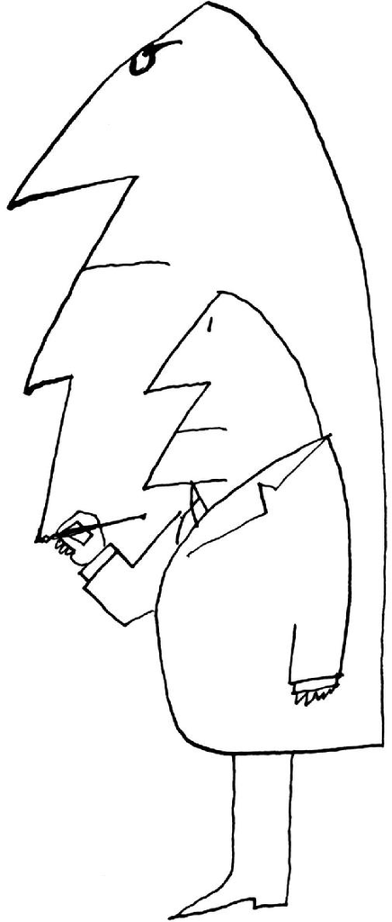

本图来源于《纽约客》1963年2月16日。

Saul Steinberg，*Untitled drawing*，ink on paper.

Originally published in *The New Yorker*，February 16，1963.

©The Saul Steinberg Foundation/Artists Rights Society（ARS），New York

萨姆回到家，打开门，走进自己的公寓，恍惚中发现，自己正穿着雨衣和套鞋站在那里，一手拿着雨伞，一手拿着一大瓶酒。他看起来非常困惑。他的朋友催眠师问道：“嘿，萨姆，你去哪儿了？”

“哦，只是去了商店。”萨姆说。

“你买了什么？”

“嗯……嗯……我好像买了这个波旁酒。”

“你不喝酒，是吗？”

“是的，但是……嗯……嗯……在接下来的几个星期里我要有很多娱乐活动，和我的一些朋友一起。”

“你怎么会在这么好的天气穿戴这些雨具？”

“其实每年这个时候天气变化都很大，我不想冒任何风险。”

“但是天空没有乌云呀！”

“是的，你永远也不会知道……”

“顺便问一下，你在哪里买的酒？”

“哦，嘿嘿。嗯，嗯……我去了超市。”

“你怎么会跑那么远？”

“嗯，嗯……嗯……有如此美好的天气，我想这可能是因为我很有兴致才走了很长一段路。”

人们持有为自己的行为、看法和感觉辩护的动机。当他们做某件事情的时候，如果可能的话，他们会让自己（和其他人）确信这是一件合乎逻辑的事情。萨姆做那些蠢事是有充分理由的，因为他被催眠了。但因为萨姆不知道催眠后的指令，而且他很难接受这样一个事实，即他会毫无意义地去行动。他竭力使自己（和他的朋友）相信他的疯狂是有道理的，他的行为是完全明智的。正如我们在第2章中所看到的，我们的许多行为都会受到一些未知因素的支配。之后，当我们被要求解释自己的行为时，我们试图构建出一个有意义的故事，同时满足我们的愿望，让自己和他人看起来都不错。这便是**自我辩护**的本质。

假设你正处在一场自然灾害之中，比如地震，你周围的建筑都倒塌了，周围的人有死有伤。你感到恐惧。你需要为自己的恐惧寻找一个理由吗？当然不需要。证据就在你的周围，受伤的人和被摧毁的建筑物可以为你的恐惧提供充分的解释。但假设地震发生在邻近的一个城镇。你感觉到了震颤，你听到了那里所发生破坏的故事。你虽然害怕，但却不在事发地。你和周围的人都没有受伤，你所在城镇的建筑物也没有损坏。你需要更多的理由来解释为什么你会恐惧吗？是的。就像我们那个穿着雨衣和套鞋被催眠的朋友一样，你持有去理解自己感受的动机。由于你在自己的周围没有发现什么可怕的东西，所以你会倾向于给自己寻找害怕的理由。

这个案例不是虚构的，它实际上就发生在印度。在地震过后，调查人员收集并分析了地震发生地和附近居民中传播的谣言。他们的发现是惊人的。一位印度心理学家贾木纳·普拉萨德（Jamuna Prasad）发现，<sup>1</sup>居住在离震中不远邻村的人们，也就是那些能感觉到震颤但没有迫在眉睫危险的人开始散布即将毁灭的谣言：洪水会冲向他们；2月26日将是洪水暴发和毁灭的日子；在月蚀的那天，还会暴发一次严重的地震；几天之内就会发生一场气旋；其他一些无法预见的灾难也将出现。

为什么人们会杜撰、相信和传播这样的故事？这些人是受虐狂吗？他们有妄想症吗？显然，散布即将发生灾难的谣言不会起到鼓励作用，让人们感到平静和安全。一种解释是，人们非常害怕，但是由于他们缺乏足够的理由来解释这种恐惧，便制造了自己的恐惧，这使他们不至于显得愚蠢。毕竟，如果飓风正在来的路上，难道我不应该因为恐惧而瞪大眼睛吗？德迦南德·辛哈（Durganand Sinha）<sup>2</sup>对谣言的研究证实了这一解释。辛哈调查了印度某个村庄在发生类似灾难后传播的谣言。普拉萨德的研究与辛哈的研究主要不同之处在于，辛哈的研究对象直接经历了灾难并目睹了破坏。他们很恐惧，但他们有充分的理由感到恐惧；他们没有必要为他们的恐惧寻找更多的理由。因此，他们的谣言没有预示灾难的来临，也没有严重地夸大。的确，如果说有的话，也是一些令人欣慰的谣言，比如有人预言，水的供应将会在短期内恢复。

**认知失调理论**

受这些发现的启发，利昂·费斯汀格（Leon Festinger）提出了有关人类动机的伟大理论，他称之为**认知失调**理论。<sup>3</sup>这是一个非常简单的理论，但正如我们将看到的，它的应用范围很广。费斯汀格将认知失调描述为一种紧张状态，当一个人简单地持有两种心理上不一致的认知（观念、态度、信仰、观点）时便会发生。两种认知如果相互对立，则是不一致的。认知失调的经历是令人不快的，所以人们有动力去减少失调；这类似于减少饥饿或口渴等内驱力因素的过程——只不过在这里，内驱力来自认知上的不适，而不是生理需要。持有两种相互矛盾的观点就是与荒谬搞暧昧，正如存在主义哲学家阿尔贝·加缪（Albert Camus）所言，人类是这样一种生物，他们一生都在试图说服自己他们的存在不是荒谬的。

我们如何让自己相信我们的生活不是荒谬的？也就是说，我们如何减少认知失调呢？我们的常用方式是改变一种或两种认知，使它们彼此之间更加一致，或者增加更多的认知，帮助弥合原有认知之间的差距。

让我来给大家举一个很多人都非常熟悉的例子。假设一个人喜欢吸烟，然后看到反对吸烟的信息。吸烟者会出现失调：“我吸烟”的认识与“吸烟是肺癌的主要病因，也是不健康的”认识不一致。对这个人来说，最明智、最有效的减少失调的方法就是戒烟。“吸烟致癌”的认识与“我不吸烟”的认知是一致的。

但对大多数人来说，戒烟并不容易。我们可以设想这样一位长期吸烟的人莎莉（Sally）。她将采取什么措施来减少不和谐？在所有的可能性中，她会尝试在有关“吸烟会致癌”的其他认知上做工作。莎莉可能会试图淡化吸烟与疾病之间的联系，用医学尚不完美的想法安慰自己。毕竟，她可能会说，科学家们不是总在改变他们对你有好处理由的看法吗？她可能会找一些聪明的吸烟者，通过这样做，让自己相信如果黛比（Debbie）、妮可（Nicole）和拉里（Larry）吸烟，那就不会有那么大的危害。她可能会转向超轻型或有机品牌，并欺骗自己说它更健康。最后，她可能会加上与吸烟一致的认知，试图使吸烟行为不那么荒唐，尽管有危险。她也许会提高自己对吸烟的重视，她认为吸烟不仅令人愉快，而且对放松也是必不可少的：“我的寿命可能更短，但却会更愉快。”或者，她可以通过建立浪漫的、邪恶的自我关怀的形象，通过吸烟藐视危险，来试图使吸烟成为一种美德。<sup>4</sup>莎莉可以通过从认知上尽量减少危险或者夸大危险在她生活中的重要性来为自己的行为辩护。她可以通过改变现有的态度，通过构建一种新的态度，或者通过两者兼而有之来获得解脱。所有这些努力都通过淡化追求疾病的荒谬来减少失调。

在1964年，大约有一半的美国人吸烟。当年，美国医务总监办公室的报告提醒公众注意吸烟的危险，<sup>5</sup>在这份报告发表之后，一项调查被用来评估人们对吸烟与癌症之间联系的新证据的反应。不吸烟者压倒性地相信健康报告；只有10%的人怀疑吸烟是导致这种疾病的原因。然而，吸烟者对该报告进行了批评。40%的重度吸烟者怀疑这两者之间是否存在联系。他们也更容易使自己的习惯合理化：高于非吸烟者两倍以上的吸烟者认为生活充满危险，吸烟者和非吸烟者都有可能生病。

吸烟者也可以通过最大限度地改变他们的习惯来减少失调。另一项针对每天抽一到两包烟的人的研究发现，60%的人认为自己是“温和的”吸烟者，其余40%的人认为自己是重度吸烟者。<sup>6</sup>认为自己是温和的人比那些自称是重度吸烟者的人更了解吸烟的长期有害影响。温和的人通过让自己相信每天抽一两包烟并不是真的那么有害来减少失调。温和与严重毕竟都是主观的判断。

现在想象一下那些知道自己是重度吸烟者、且知道吸烟有害的吸烟者的困境，他们试着戒烟但却失败了。这些人会怎么做？为了找出答案，里克·吉本斯（Rick Gibbons）<sup>7</sup>和他的同事们研究了重度吸烟者，这些人曾在一家戒烟诊所接受治疗，戒烟了一段时间，但后来又恢复了吸烟。难道他们接受了这种程度吸烟的危害，并准备生病和死亡？绝非如此。相反，他们以不同的方式减少了认知失调：让自己相信吸烟并不像他们最初想象的那么糟糕。同样，一项跟踪135名立下新年决心学生的研究也支持了这一观点。<sup>8</sup>那些决心戒烟、减肥或锻炼的人最初感觉很糟，但在很短的时间里，便成功地淡化了这种决心。

当然，吸烟者只对自己的健康感到担心，或者担心那些可能与他们生活在一起的二手吸烟者。但如果你是一家大型香烟公司的高管，在全球范围内对香烟的销售做出最大的承诺，那又会怎样呢？如果吸烟确实会致癌，那么从某种意义上说，你对数百万人的疾病和死亡负有部分责任。这种认识会产生一种痛苦的失调。你的认知“我是一个正派、善良的人”会和你的认知“我正在促使数百万的人过早死亡”不一致。为了减少这种失调，你必须努力让自己相信吸烟是安全的——这不是一件容易的事情，因为你经常面对反对吸烟的言论以及对你是邪恶的指责。你还必须反驳大量的证明香烟和疾病之间联系的科学证据。此外，为了证实你对证据的怀疑，你也可以每天抽一两包。如果你的需要足够大，你甚至可以说服自己香烟对人有好处。因此，为了把自己看作是聪明、善良和正确的人，你采取了愚蠢、错误和有害健康的行动。

这种分析听起来如此美妙，以至于几乎难以置信。1994年，国会举行了关于吸烟危害的听证会。在这些听证会上，各大烟草公司的高管们都承认自己是吸烟者，并厚颜无耻地争辩说，香烟不比玩电子游戏或吃零食更有害或更容易上瘾！在1997年的一次听证会中，美国领先的香烟制造商菲利普·莫里斯（Philip Morris）的总裁兼首席执行长詹姆斯·摩根（James J.Morgan）说，香烟在药理上不会上瘾。“你看，我喜欢熊软糖而且会吃熊软糖。”摩根说：“假如我不喜欢吃软糖，我肯定不会对它们上瘾。”<sup>9</sup>

摩根有可能是在撒谎。但我感到他所说的要比撒谎复杂得多。我的猜测是，随着时间的推移，像摩根这样的人开始相信自己的谎言，并试图对自己进行欺骗。<sup>10</sup>

人们的自我欺骗甚至会直接导致他们的自我毁灭。1997年，一个不为人知的教派“天堂之门”的39个成员，被发现死在加州兰乔圣菲的一个豪华庄园里，他们实施了这起集体自杀事件。几周前，这个邪教组织的一些成员走进了一家专卖店，购买了一台昂贵的大功率望远镜，以便能更清楚地看到哈雷-波普彗星以及他们坚信跟在它后面飞行的宇宙飞船。他们确信，当彗星接近地球时，就是通过自杀来摆脱他们的“地球容器”（他们的身体）的时候，这样他们的灵魂就可以被飞船接走。购买了望远镜几天后，他们把它带回店里，礼貌地要求退款。当经理问这样做的理由时，他们抱怨说望远镜有缺陷：“我们找到了彗星，但我们找不到跟踪它的宇宙飞船。”不用说，根本不存在宇宙飞船。但假如你确信太空船的存在，以至于你准备魂归飞船，而你的望远镜却没有发现它，那么很明显一定是望远镜存在什么问题！

“天堂之门”的成员可能持有一种悲惨的错误信念，但他们阐明了认知失调理论的核心科学贡献：与邪教成员一样，每当我们感到对宗教、政党、有魅力的领袖或意识形态强烈忠诚的时候，以及当这些忠诚受到事实挑战的时候，我们会提出各种歪曲事实的证据。连尼·布鲁斯（Lenny Bruce），一位敏锐的喜剧演员和社会评论家（几乎可以肯定，他从来没有接触过有关认知失调的理论），对1960年理查德·尼克松（Richard Nixon）和约翰·F·肯尼迪（John F.Kennedy）之间的总统竞选活动有以下见解：

我会和一群肯尼迪的粉丝一起观看辩论，他们的评论是：“他真的是在屠杀尼克松。”然后当我们走进另一个公寓，尼克松的粉丝会说：“你觉得他投向肯尼迪的炮弹怎么样？”于是我意识到，每个团体都钟爱他们自己的候选人，如此一来那个家伙便会变得明目张胆——他会对着镜头说：“我是个贼，一个骗子，你听到了吗？我是你在投票选举总统这件事情所做过的最糟糕的选择！”即使这样，他的追随者也会说：“现在你有了一位诚实的男人可供自己选择。需要一位有实力的人物来承认这一点。我们需要这样的人当总统。”<sup>11</sup>

五十多年之后，总统候选人唐纳德·特朗普（Donald Trump）对他的支持者同样无条件的忠诚感到惊讶：“我可以站在第五大道的中间，射杀某人，却不会失去任何选民，你相信吗？如出一辙，这令人难以置信。”<sup>12</sup>

**减少失调与非理性行为**

认知失调是两种基本动机冲突的结果：我们努力保持正确，这促使我们密切关注他人正在做的事情，听取值得信赖的交流者的建议；我们努力相信我们是正确的（明智的、体面的、善良的）。有时候，我们的动机是正确的，我们的动机使我们相信自己是在朝正确的方向行事：我们会寻找并注意一些信息（例如，关于吸烟的风险）。对失调的理解有助于解释为什么人类的思维是非理性的，而不是理性的。不管多聪明，那些正在减少失调的人都会相信自己是对的，以至于他们经常会做出非理性的行为。我所说的“非理性”，是指他们的不适应行为会阻碍他们了解基本事实，或阻碍他们找到解决问题的真正办法。

在实验室里，研究人员已经充分展示了人们努力减少失调的非理性。假设你对死刑能否阻止人们杀人有强烈的感觉。我现在可以就这个问题的两个方面给你提供一系列的论据；其中一些论据是合理的，另外一些则是愚蠢的。如果你的思维是理性的，那么无论你个人的观点如何，你都应该记住最可信的论点和最不可信的论点。但是失调理论会预测到什么呢？支持你个人观点的愚蠢论点会导致一些失调，因为它会导致人们对这个观点或者赞同这个观点的人的智慧发生怀疑。同样，问题的另一个方面是，一个明智的论点也会导致一些失调，因为这个论点意味着另一方比你所想象的更聪明或者更敏锐——或者，出现你所不愿意看到的结果，他们可能是正确的。因为这些争论可能引起失调，我们会尽量不去想它们。失调理论预测人们会记住那些赞同自己观点的似是而非的论点以及赞同对方观点的不可信的论点。<sup>13</sup>

许多研究对这种现象进行了验证。查尔斯·洛德（Charles Lord）、李·罗斯（Lee Ross）和马克·莱佩尔（Mark Lepper）<sup>14</sup>在一项研究中，选择了斯坦福大学几位反对死刑和赞成死刑的学生。他们向学生们展示了两篇研究论文，论文讨论了死刑是否会对暴力犯罪起到威慑作用。其中一项研究证实了学生们的已有看法，而另一项研究则没有证实。如果这些学生是完全理性的，他们可能会推断出这是一个复杂的问题，因此，两组学生可能会在有关死刑的看法上互相接近。另一方面，认知失调理论则预测，他们会对两篇论文加以歪曲：他们会将那篇证实了自己看法的论文牢记在心，并为其确凿无疑地支持了自己的看法而兴奋不已；而对不能证实自己看法的那篇论文，他们则会寻找方法上或者概念上的错误，并拒绝来自它的影响。这就是他们的发现。事实上，在看到从两个方面提供的这份材料之后，两组学生的看法不仅没有更加接近，他们的意见分歧反而比此前更加明显了。这一过程大概可以说明这样的事实：在类似政治或宗教之类的问题上，不管我们的论点多么有力和公正，那些笃信某种观点的人也几乎不可能按照我们的方式去对事物进行观察。<sup>15</sup>这项研究揭示了当今美国政治话语两极分化的状况。

毋庸讳言，我们都有能力理性地行动。但我的观点是，当我们需要减少失调时，我们都会做出不理性的行为。当我们讨论自我辩护需要所产生的一些广泛的影响时，我们会看到人类行为的两个方面。让我们从决策过程开始考察，这个过程显示了人类可以连续地快速在极端理性和极端非理性状态之间转换。

**决策导致的失调**

假设你决定要买一辆新车。这会涉及一大笔资金，因此显而易见，它是重要的。考察一番后，你会在购买一辆运动型多用途汽车还是一辆全电动汽车之间犹豫不决。这两款车都有优点和缺点。越野车会很方便，你可以在长途旅行时用来装东西，睡在里面，而且它有足够的动力，但是它很费油，而且不好停车；电动汽车不那么宽敞，你不能开很远的距离，你会担心它的安全，但是它的购买和操作成本较低，开这样的车会更有趣，你打听到它有很好的维修记录。我的猜测是，在你做出决定之前，你会尽可能多地搜集信息。你可能会上网，并对不同的产品和型号进行抽样审查；也许你会与那些拥有SUV或电动汽车的朋友交流；你可能会去经销商那里试驾，看看每辆车的感觉如何。所有这些预决策行为都是完全合理的。

现在你作出了某种决定：你买的是全电动汽车。接下来会发生什么？你的行为将开始改变，你将不再搜集有关所有型号汽车的客观信息。你可能会花更多的时间和其他车主交谈。你将开始谈论它的低碳，以及它在充电过程中的作用。我的猜测是，你不会花任何时间去思考你不能在你的新车里住宿这类信息。同样，你的大脑也会轻易忽略这样一个事实，即驾驶你的新车遇到碰撞是危险的，刹车也不是很灵敏。

你是如何改变主意的？在作出决策之后——尤其是某个困难的决策或某个涉及大量时间或金钱的决策之后——人们几乎总会经历失败。因为他们所做出的选择很少是完全正面的，而被拒绝的选择也很少是完全负面的。在这个例子中，你对自己购买电动汽车的认知与你对汽车可能存在的缺陷的认知是不一致的。同样，你想购买的其他型号汽车的所有积极的方面也都与你的认知不一致，即你没有购买其中的一辆。减少这种失调的一个好方法是找出你选择的汽车的排他性正面信息，避免负面信息。因此我推测，最近购买某车型汽车的人会开始选择性地阅读广告，相比最近没有购买过该车型汽车的其他人，他们会阅读更多关于他（或她）的汽车的广告。而且，新车的车主们往往会避开其他型号汽车的广告。这正是研究人员在今天的广告阅读器研究中发现的，<sup>16</sup>这要归功于社交媒体，人们不必花费过多努力就能获得与他们刚买的车相符的信息，认同他们现在所持有的想法，回避任何与之不相符的信息。

人们并非总需借助麦迪逊大街<sup>[1]</sup>来获得安慰。在安慰自己方面，他们可以做得更为出色。杰克·伯里汉姆（Jack Brehm）<sup>17</sup>的实验证明了他们是如何做到这一点的。伯里汉姆扮作市场调研人员，给几位女士展示了8种不同的电器（烤面包机，电动咖啡机，三明治烤架等等），并要求她们根据每件电器的吸引力来给它们评分。作为奖赏，每位女士都被告知可以得到其中的一件电器作为礼品，并允许她在两件自己评定为同等吸引力的电器中任选一种。等她选好之后，就将这件电器包装好送给她。几分钟后，要求她再次对这些电器进行评价。结果发现，在得到了自己挑选的电器后，每位女士都对该电器的吸引力做出了较高的评价，而降低了那件可以得到但自己没有挑选的电器的评价等级。

我们又一次看到了决策所引起的认知失调：对所喜欢的对象的任何负面认知，与选择了它的认知之间会产生失调；对没有选择的对象的正面认知，与没有选择它的认知之间也会产生失调。为了减少失调，人们在认知上分散了各种选择。也就是说，在作出决策之后，伯里汉姆研究中的女士们，会强调自己决定选用的电器的正面特性，同时贬低它的负面特性；而对自己决定不选用的电器，则强调它的负面特性，同时否认它的正面特性。

为个人选择进行辩护的倾向，并不仅仅局限于消费者决策。事实上，有研究发现，类似的过程甚至可能影响人们的爱情关系，以及人们打算与那些可能成为伴侣的人进行交往的意愿。在丹尼斯·约翰逊（Dannis Johnson）和卡莱尔·罗斯鲍特（Caryl Rusbult）<sup>18</sup>所做的一项研究中，研究者要求大学生们评价校园里新兴的一种电脑约会服务成功的可能性。被试们看到了一些异性的照片，并且相信这些人是约会服务的申请者。接着，要求他们对这些申请者的吸引力进行等级评定，而且评定与他（她）可能的约会使自己快乐的程度——合乎实际地提出某种可能性。这项研究的结果与伯里汉姆有关电器的发现非常类似：学生们对自己当前的恋爱对象投入越多，他们对研究中所提供的有可能成为伴侣的人吸引力的评价越差。在后来的一项实验中，杰弗里·辛普森（Jeffry Simpson）和他的同事们<sup>19</sup>也发现，与那些还没有建立起稳固恋爱关系的人相比，那些已经建立起稳固关系的人会认为其他异性的身体和性吸引力较低。另外，他们还发现，这种效应只是对“合适的他人”起作用；假如所提供的人选年龄有些偏大或者是同性，那些建立了忠诚的恋爱关系的人便不会贬低这些人的吸引力。简言之，没有威胁，就不会出现失调；没有失调，便不会去贬低他人。

无论我们谈论的是电器还是恋人，一旦作出了某种坚定的承诺，人们便会倾向于关注自己所做选择的积极方面，而忽略自己所拒绝的其他选择的吸引力。

**失调会降低意识吗？** 正如我们在第2章中所看到的，我们大多数人都不擅长预测我们适应负面事件会有多快。现在我可以告诉你理由：因为人们不知道如何成功地减少失调。既然过去已经成功地做到了这一点，那么为什么他们不确定自己将来也会做到呢？答案是减少失调的过程在很大程度上是无意识的。人们不会坐下来说，“我想我现在该减少一些失调了”。例如，当你所爱的人抛弃了你时会发生什么？随着时间的推移，你会发现这个人不再那么值得爱了，甚至发现他可能是一个无法忍受的自恋狂。你会开始相信，自己应该得到更好的生活，或者一个人会过得更好。这个过程之所以会奏效，是因为一切都是在意识水平之下发生的，没有任何意图。不幸的是，这种内隐性使得失调在得以有效解决的同时，也容易被遗忘。因为这个过程是无意识的，所以我们没有意识到它也会在未来保护我们免受痛苦。

假如英格丽·褒曼（Ingrid Bergman）没有重新回到她的抗纳粹英雄丈夫身边，而是和她的情人亨弗瑞·鲍嘉（Humphrey Bogart）一起待在摩洛哥，那么在经典电影《卡萨布兰卡》的结尾会发生什么呢？正如鲍嘉在一次令人心碎的著名演讲中所说的那样，她会后悔吗？——“也许不是今天，也许不是明天，而是很快，用尽你的余生。”还是她会后悔把鲍嘉独自一人留在雨中的机场？我有理由怀疑这两个问题的答案都是否定的，鲍嘉所言听起来有道理但却是错误的。她也许会后悔今天和明天所做的选择，但是很快（以及她的余生）她便会相信自己已经作出了最好的决定。<sup>20</sup>但考虑到我们在生活中所作的决定是无数的，我们很少有值得注意的决定——这要归功于我们减少失调的能力。

**失调是普遍存在的吗？** 认知失调的经验有多普遍？这是美国人最常经历的事情，还是人类生活的一部分？我们不可能对此作出肯定的回答，因为失调实验并未在世界所有地方进行检验。但我可以这样说：虽然大多数研究都是在北美地区进行的，但是在世界上做过这类研究的任何一个地方，都已经被证明是有效的。

这项研究得到了广泛的验证。认知失调理论已经得到了上千项研究的支持，其中一些研究领域包括认知神经科学，甚至是对灵长类的研究。在某些方面，猴子就像那些在电器之间面临选择的家庭主妇一样：如果让它们在两盒不同颜色的食物中作出选择，它们很可能会选择自己曾经选择过的食物——尽管还存在其他选择。这项研究表明，如果事后判断不一致导致我们的祖先坚持了某个经过尝试且真实的选择，而拒绝了一些未经检验的新东西（从我们人类的经历来看，这可能是危险的），那么这种不一致便有可能促进人类的进化。<sup>21</sup>

人类在认知失调中发挥了“认知”作用，在很小的时候，人类就表现出了认知上的正当性。<sup>22</sup>我的一个朋友带她3岁的女儿去公园玩，给了她一些贴纸。另一个小女孩走近她们。“你不想把你的贴纸给那个小女孩玩吗？”我的朋友问。孩子思考了一会儿说道：“妈妈，那个小女孩不喜欢贴纸。”3岁的孩子已经能够降低失调！她在保留了自己所有贴纸的同时，成功地将自己视为一个好女孩。

为了支持失调是普遍存在的观点，艾迪·哈蒙-琼斯（Eddie Harmon-Jones）和他的同事们<sup>23</sup>使用了功能性磁共振成像技术来监测大脑特定区域的神经活动，当时人们正在经历各种失调：对他们选择或者拒绝的事物进行评分，将并不舒服的检测体验说成是相当令人愉快的，或者是面对不受欢迎的（引起失调的）信息。处于失调时大脑中被激活的区域包括前额叶皮质内的特定区域，该区域显著地参与了计划与决策。在一项研究中，人们试图处理与他们所偏爱的总统候选人不一致或一致的信息，德鲁·威斯顿（Drew Westen）和他的同事们<sup>24</sup>发现，当一个人面对不一致的信息时，大脑的推理区域实际上被关闭了，当恢复一致时，大脑的情感回路会“快乐地”亮起来。正如威斯顿所说的，人们转动“认知万花筒”，直到这些片段进入他们想要看到的模式，然后大脑通过激活与快乐有关的电路来补偿它们，似乎认知失调的感觉确实会让大脑受伤。

世界上几乎任何一个地方都存在着不和谐现象，但这种现象出现的形式却各不相同，所形成的认知内容可能因文化而存在差异。例如，在一些个体主义不明显的社会里，减少失调的行为可能存在更为普遍的形式。<sup>25</sup>在这样的文化里，自己的行为让别人感到羞辱或失望，会比为自己的不当行为辩护，更有可能让人们感到失调。这正是日本社会心理学家村上坂井（Haruki Sakai）<sup>26</sup>在他的实验中发现的。在日本，许多人会间接地体验到自己所认识和喜欢的人引起的失调，他们会改变自己的态度，以迎合那些给自己带来失调的朋友。此外，日本人只有感觉到自己是在别人的关注下作出决策、而不是私下作出决定时，才有可能认为自己所作的决策是合理的；而对于美国人来说，这种思考模式正好被颠倒了过来。<sup>27</sup>人们对所作选择的隐私或公众能见度的感知会与文化因素相互作用，以确定是否引起了失调、是否需要对选择的合理性作出判断。

**不可挽回性的重要作用**

我们所讨论的例子的一个关键特征是这个决定的相对不可挽回性——一个人无法挽回自己所做的事情。这里需要做一些解释。正如我们所看到的，当你试探性地考虑买车或者作出其他决定时，你不需要花费精力说服自己你作出的是明智的选择。但一旦你作出了决定，便不可挽回，一切都改变了。

关于不可挽回性重要作用的一些直接证据，来自于对赛马场赌徒认知循环的研究。赛道是一个考察不可挽回性的理想场所，因为一旦你下了赌注，你就不能回去告诉坐在窗口后面的那位好人你改变了主意。罗伯特·诺克斯（Robert Knox）和詹姆斯·英克斯特尔（James Inkster）<sup>28</sup>在研究中只是拦住了那些正在下两美元赌注的人。他们已经选定了他们要下赌注的马，并准备下注，这时研究人员问他们是否确信他们的马会赢。因为他们正在去下两美元赌注窗口的路上，所以他们的决定是可以撤销的。当另外一些赌徒离开下注窗口的时候，研究者拦住了他们，也询问了他们对自己所选马匹胜算的把握有多大。结果表明，那些已经为自己所选的马匹下过赌注的人，比那些正要去下赌注的人感到胜算把握更大。当然，事实上除了最终结果之外，任何事情都不会对胜算产生影响。

现在，让我们从赛马场来到哈佛大学校园，丹尼尔·吉尔伯特（Daniel Gilbert）<sup>29</sup>在对一群学习摄影感兴趣的学生进行测试时证实了不可挽回假设。他让他们拍摄完一卷胶卷，打印出其中的两张照片，让他们对照片评级，并选择了其中的一张。一些学生可以在五天内替换照片，而另一些学生则被告知他们所做的第一选择是不可挽回的。在两天、四天、九天之后，吉尔伯特分别联系了他们，看看他们对照片的感觉是否发生了改变。在第一天做出不可挽回选择的人比那些可以交换照片的人更喜欢他们的选择。结果再一次显示，一旦某个决定是不可挽回的，人们便会竭力让自己为所作出的选择感到高兴。由此可见，一旦人们感到已经无能为力，他们便会更加确信自己作出了明智的决定。

尽管决策的不可挽回性总会增加失调，并且会增强人们减少这些失调的动机，但在一些场合，人们即便改变已经作出的决定也会感受到失调。几年前，罗伯特·西奥迪尼（Robert Cialdini）<sup>30</sup>通过在一家汽车经销商做临时销售人员，发现了其中的奥妙。（西奥迪尼做了很多富有想象力的社会心理学现场研究，这是他最有趣的研究之一。）这是一种常用且颇为有效的策略，称之为**虚报低价**，或者用低价来让消费者就范。它是这样发生作用的：某位顾客找到某位汽车销售人员，准备为他梦寐以求的一款汽车支付19300美元——这个价格被宣传成了难以置信的便宜货。那位销售人员微笑着说：“我卖给你一辆更好的”，然后以18942美元的价格把那辆车卖给顾客。买方对这笔交易感到非常兴奋，于是同意了这笔交易，并开出了首付支票，兴高采烈将那辆新车开回了家。不过，10分钟后，那位销售人员带着一副绝望的表情找到他；说自己在计算上似乎犯了一个错误，而销售经理发现了。这辆汽车的价格实际上是19384美元。这时，买家会怎么做？这位顾客可以在其他地方买到更便宜的车，也就是说，他所作出的购买这辆车的决策并非无可挽回。尽管从这位销售人员那里购买这款车的理由（交易价格）已经不存在了，但是与一开始就报价19384美元相比，更多的人会将交易继续下去。

这到底是怎么回事呢？这里至少有三个重要的问题值得注意。首先，虽然客户的购买决定毫无疑问是可逆的，但是签署首付支票的行为却形成了一种潜在的承诺。其次，这种承诺引发了对某种快乐体验的期待：开着一辆新车出去。如果因为中止不进行交易而导致预期事件不能发生，将会带来失调和失望。再次，尽管最终价格比推销员所说的要高，但只比其他地方的价格略高一点。在这种情况下，顾客往往会说：“哦，管他呢。我已经来了，而且已经填了表格，为什么还要再等呢？”而今，当人们购买汽车的时候，低价策略已经很少起作用了，因为互联网使人们变得更聪明、对情况更加了解。但这种策略仍然适用于我们不知情的许多其他情况，比如用一个新的合同取代过期的手机合同，这个新的合同便有可能隐含着某种消费陷阱。

**不道德的行为决策** 一个诚实的人怎么会变坏呢？反之，我们怎样才能让一个人变得更加诚实？一种方法就是通过让他做出某个艰难的决定产生失调。假设你选修了一门艰深的生物学课程，你的成绩将取决于你正在参加的期末考试。现在面对着一个你非常熟悉的关键问题，由于焦虑，你的脑子里一片空白，你坐在那里紧张得汗流浃背。猛然间你抬头一看，坐在你前面的女生，竟然是班上最聪明的那一位（幸运的是，恰好她的笔迹也是最清晰的）。你稍稍低一下头，就能看到她已经完成的有关这个关键问题的答案。你会怎么做？你的良心告诉你，作弊是错误的——然而，如果不作弊，你必然会得到糟糕的分数。你和你的良心在斗争。无论你是否决定作弊，你都注定会感受到失调。如果你作弊，你的认知“我是一个正派的、有道德的人”与你的认知“我刚刚做了一件不道德的事情”会产生不一致。如果你决定抵制诱惑，你的认知“我想得到一个好分数”与你的认知“我本可以以一种确保得到一个好分数的方式行事，但我却没有这样做”也会产生不一致。

假设，经过了一番艰苦的思想斗争，你决定作弊。那么如何减少由此而导致的失调？在你继续阅读之前，请考虑一下。减少失调的一个方法是尽量减少你所选择行为的负面影响，并最大限度地增加其正面影响——就像杰克·伯里汉姆实验中的女士们在选择一件电器后所做的那样。在这种情况下，减少失调最有效的方法是改变你对欺骗的态度。如果你作了弊，你便会采取更为宽容的态度。你的推理可能是这样的：“在某些情况下作弊并不是那么糟糕。只要没有人受到伤害，这的确并非很不道德的事情。任何人都会这么做。因此，这是人性的一部分——那又怎么会是坏事呢？因为它是人性所共有的，所以那些被发现作弊的人不应该受到严厉的惩罚，而应该得到理解。”

但是假设，经过了一番艰难的思想斗争，你决定不作弊。你会怎样减少失调——也就是说，使你的行为与你的信念一致呢？你可以再一次改变你对行为道德的态度，但方向相反。为了证明“放弃一个好分数”是正当的，你必须让自己相信：欺骗是一种令人发指的罪恶，是一个人所能做出的最卑鄙的事情之一，欺骗者应该被发现并受到严厉的惩罚。

这里需要记住的一点是，以这两种不同方式行为的两个人，一开始的态度几乎是一样的。他们的决定可能相差甚远：一个是在抵制的范围内，但决定欺骗；另一个是在欺骗的范围内，但决定抵制。然而，一旦做出了决定，他们对欺骗的态度就会因所作出的决定而迥然不同。

这些推测在贾德森·米尔斯（Judson Mills）<sup>31</sup>所做的一项针对六年级学生的实验中进行了验证。米尔斯首先测量了他们对欺骗的态度。然后，他让孩子们参加竞争性考试，向优胜者颁发奖品。这种情况是预先安排好的，不作弊几乎是不可能取胜的；而且，孩子们很容易作弊，他们会认为自己作弊不会被发现。正如你所预料的，一些学生作了弊，而另外一些则没有作弊。次日，这些六年级的学生再次被要求说明他们对作弊的看法。总体而言，那些作弊的孩子对欺骗变得更加宽容，那些抵制作弊诱惑的孩子对欺骗采取了更加严厉的态度。

设想一下米尔斯的实验对你而言意味着什么，设想你已经站到了金字塔的顶端。在一生中，你会面临着许多决策，这些决策会引导你在金字塔的不同方向之间变换：主修什么专业？拒绝与做过一些违法或不道德事情的朋友合作，或者不去破坏一切？是保持一段浪漫的关系，还是离开？是相信一些阴谋说，还是去Snopes.com<sup>[2]</sup>或Politi Fact<sup>[3]</sup>寻求真相？无论怎样，当你朝着某个方向迈出一步的时候，你总会感受到失调——现在你会被激励为减少失调而去为自己所做的事情辩护。反过来，这样的辩护会让你更难改变主意，即便是在你应该做出改变的时候。当你到达金字塔底部的时候，你将与那些面临同样的困境但作出不同决定并从相反的方向滑下金字塔的人相距甚远。你会确信自己的决策是绝对正确的，而那些从另一边溜下来的人都是白痴或骗子。（你觉得他们对你的感觉又会如何？）

金字塔比喻也有助于帮助我们理解**诱设**（entrapment）过程中的态度和行为是如何变化的，或者人们如何从一开始做出某个很小的、冲动性的决策，而随着时间的推移，发现自己的行为与最初的目标和意图已经相去甚远。诱设过程可以通过可控的实验条件来进行考察。假设你想寻求某人对你所从事的一项宏大事业进行帮助，但你很清楚要让这个人做到这一点是极为困难的，需要付出相当多的时间和努力，这个人肯定会拒绝。你应该如何去做呢？一种可能是让这个人参与到工作中的某个细微的环节——某个十分简单以至于他（她）根本不会想到要拒绝它，迈出这一步有助于使这个人投入到你的“事业”之中。一旦人们这样去做了，他们满足你更大要求的可能性便会增加。

乔纳森·弗里德曼（Jonathan Freedman）和斯科特·弗雷泽（Scott Fraser）<sup>32</sup>的研究证实了这一点。他们试图劝导一些房主在自家的前院竖起一块写有“谨慎驾驶”的巨大招牌。由于这块招牌很难看而且很惹眼，大多数居民拒绝了这一做法，只有17%的人表示同意。但是，对另外一组居民，则首先由实验者对他们加以“软化”——让他们签署一份赞同安全驾驶的请愿书。由于签署请愿书是一件轻而易举的事情，所有受到邀请的人都签署了。几周后，另外一位实验者带着写有“谨慎驾驶”的那块很难看的招牌，找到了每一位居民。这一次，超过55%的居民允许在自家的土地上竖起这块招牌。因此，当个人作出较小的承诺时，他们就更有可能在这方面进一步作出承诺。

这种通过要求帮小忙来促使人们同意提供更大帮助的做事方法，被称之为**登门槛技术**。这种技术之所以有效，是因为它通过请人们帮小忙，而获得了让人们同意提供更大帮助的理由。帕特丽夏·普利纳（Patricia Pliner）和她的同事们也得出了类似的结果。<sup>33</sup>当他们直接要求一些人向美国癌症协会捐款时，46%的人表示同意；但是，当他们要求这些人提前一天戴上领针宣传募捐活动，然后在第二天向他们寻求捐款时，大约有两倍的人同意了。通过自我辩护来诱发人们的行为，可能导向利他主义和社会赞许的目标，但也可能导向破坏性的、不利的目标，我们将在本章的结尾看到这一点。

**不充分辩护心理**

改变态度，作为减少不和谐的一种手段，并不局限于作出决策之后。它还可能在无数其他情况下出现，包括某个人说了他（她）不相信的话，或者做了些愚蠢或不道德的事情。当然，在一个复杂的社会里，我们偶尔会发现自己在谈论或者做出某些我们并不完全相信的事情。难道我们总会因此而改变自己的主意吗？非也。我将用一个简单的例子来说明这一点：乔（Joe）走进办公室，看到他的律师合伙人乔伊斯（Joyce）在他们共用的办公室墙上挂了一幅非常糟糕的画。当他正要告诉她这幅画有多糟糕时，她却自豪地说道：“你觉得这幅画怎么样？我自己画的。”

“非常好，乔伊斯！”乔回答。从理论上讲，乔的认知“我是一个诚实的人”与他的认知“我说绘画是好的，虽然它的确丑陋得令人难以置信”之间的不一致会引起何种失调呢？乔认为伤害别人是不对的，这很容易快速减少这种不一致可能引起的任何失调：“我撒谎是为了不伤害乔伊斯，我为什么要告诉她那是丑陋的呢？这样做没有任何用处。”这是减少失调的有效方法，因为它完全是在为乔的行为辩护。实际上，这类理由是根据具体情境来确定的，我们称之为**外在理由**（external justification）。

但是，假如情境本身不存在充分的理由，那又该怎么办？在这种情形下，我们需要给出**内在理由**（internal justification），即通过态度改变来证明自己行为的正当性。如果你做出或说过一些从外部难以证明的事情，你会试图通过让自己的态度与所做或所言更加一致来从内部证明它是正确的。

这些推测已经得到了一些科学研究的验证。其中尤为经典的一项研究是利昂·费斯汀格和默瑞尔·卡尔史密斯完成的。<sup>34</sup>研究者们要求大学生们去做一系列十分枯燥而且需要不断重复的事情——把卷轴装进一个盒子里，再倒出来，然后一遍又一遍地重新将盒子装满；或者将一排排螺丝钉旋进四分之一，然后旋出来，再旋进去四分之一。学生们这样干了整整一个小时。随后，实验者要求学生们对所做事情撒谎；具体而言，他让学生们告诉一位年轻女士（她正在等候参加实验），她将要做的事情充满了乐趣。一些学生因为撒谎得到了20美元，另一些学生则只得到1美元。实验结束后，一位访员向说谎者询问他们有多喜欢先前在实验中所做的事情。你认为那些因撒谎而得到20美元的学生会如何回答？他们认为放卷轴和旋螺丝钉都很无聊。这并不令人奇怪，因为那些任务本身就是很无聊的。而那些因说谎而只得到1美元的学生又会如何回答呢？他们认为这项任务是令人愉快的。换句话说，那些因为说谎而获得了较多外在理由的人，尽管说了谎，但他们并不相信；而那些没有外在理由说谎的人，则朝着相信他们所说的是真实的方向前进。我们将这一结果称之为“讲过为真”范式，因为在这种情况下，人们开始相信自己的说法。如果你想要一个人改变态度，那么就让他去做出或说出一些与他观点相反的事情，并为此支付给他较低的报酬。

与此相关的研究已经超越了那些相对不重要事情的态度，比如枯燥的任务。态度的改变已经在许多更为严重的问题上表现出来，在这些问题上，人们所表达的立场与他们所信仰的立场正好相反。亚瑟·科恩（Arthur R.Cohen）<sup>35</sup>在一次学生骚乱后立即对耶鲁大学的学生进行了实验，在这次骚乱中，纽黑文警方反应过度，对抗议者进行了殴打和逮捕。学生们（他们确信警察行为不端）被要求撰写一篇有分量的文章来支持警察。实验者因为学生们写了这篇短文而给他们50美分到整整10美元不等的微薄报酬。之后，这些人被要求说出他们对纽黑文警察的真实感受。结果是完全线性的：为支持警察而写作的报酬越少，他们后来表达出来的对警察的好感就会越多。之所以会出现“讲过为真”现象，主要是因为他们所说过的话没有获得丰厚的报酬。

因此，失调理论预测我们会相信我们所说过的事情，但前提是我们没有足够的外在理由来确认这类事情。对你所做的讲述奖赏越少，你就越有可能觉得有必要通过说服自己“你所讲述的都是真的”来证明你所讲述的的确为真。

这种机制的威力是如此强大，它不仅有助于解释态度的改变，而且还会影响我们体验基本生理需求的方式。可以设想一下，我们的朋友萨姆被诱导进入这样一种情境：他将会被长期剥夺食物或水，或者遭受电击。如果萨姆没有一个好的外部理由来解释为什么会受到这种对待，他会体验到失调。他对饥饿、喉咙干渴或遭受电击的痛苦的认知，均与他心甘情愿地体验这些经历的认知产生不一致，也没有因此而得到多少回报。为了减少这种失调，萨姆说服自己：饥饿并不那么强烈，口渴也并不那么严重，遭受电击的痛苦也并不那么可怕。

这种自我说服并不像看上去那么令人吃惊或者困难。饥饿、口渴和痛苦虽然都有其生理基础，但也包含了很强的心理成分。这就是为什么建议、冥想、催眠、安慰剂、有经验医生在病床边的一些作法，或者上述几种方式的组合，可以减轻人们所感受到的疼痛。实验社会心理学家已经证明，在高度失调的唤起条件下，没有催眠或冥想等特殊技能的普通人，也可以替自己完成同样的事情。

例如，菲利普·津巴多（Philip Zimbardo）<sup>36</sup>对他的研究被试施加了强烈的电击。其中一半的人处于高失调状态，也就是说，他们被说服自愿接受这种经历，几乎没有什么外在理由。另外一半则处于低失调状态，他们被告知在这件事上别无选择，这给了他们充分的外在理由。高失调状态下的人比低失调状态下的人感受到了更少的痛苦。就连他们对疼痛的生理反应（通过皮肤电反应来测量）也没有那么强烈，疼痛没有那么强烈地干扰他们的工作。因此，不仅他们所报告的痛苦比低失调组少，而且客观而言，他们也并未受到痛苦的困扰。

在饥饿和口渴方面也有类似的结果。杰克·布莱姆（Jack Brehm）<sup>37</sup>报告了一系列实验结果，在这些实验中，人们被长时间剥夺了食物或水。就像津巴多的被试一样，有些人在经历这种不愉快的经历时缺乏外在理由，而另一些人则有充分的外在理由。在关于饥饿和口渴的不同实验中，布莱姆发现高失调被试会比低失调被试更少报告自己体验到饥饿（或口渴），而他们被剥夺了食物（或水）的时间是相同的。需要强调的是，这不仅仅是口头报告。实验结束后，当所有被试都被允许自由进食（或饮用）时，那些高失调者所消耗的食物（或水）要明显少于低失调者。

**哪些因素构成了外在理由？** 金钱利益或强迫要求去做某件事情并非唯一的外在理由。假如人们被其他的一些奖励（例如赞美或取悦）所诱惑，他们也可能被说服去说出（或做出）一些与自己的信仰或喜好相背离的事情。而且，我们中的大多数人可能会应好朋友之请求去做一些本来不想做的事情。让我们举一个稍显牵强的例子，假设某位朋友让你品尝一种她（他）最近在烹饪课上学会的不同寻常的食物。为了让事情更有趣，让我们假设这类食物是油炸蚱蜢。现在，设想一下相反的情况：一个你所不喜欢的人往你嘴里塞进一只油炸蚱蜢。

现在，你准备好了吗？假设你吃了蚱蜢，在何种情况下，你认为自己会更喜欢它的味道：请你去吃蚱蜢的是你的一位好朋友，还是一位你不喜欢的人？常识可能意味着，当朋友推荐时，你会感到蚱蜢的味道更好些。因此，比起你不喜欢的人，朋友会是更可靠的信息来源。但是请你思考片刻：在哪种情况下包含的外部理由较少？与常识不同，认知失调理论会预测，如果受到了一位自己不喜欢的人的邀请，你会更喜欢吃蚱蜢。你那“吃蚱蜢是令人厌恶的”认知，与你“刚刚吃过一只蚱蜢”的事实之间是不一致的。但是假如是你的朋友提出了邀请，你吃它就有足够的外部理由——这样做是为了取悦你喜欢的人。但假如你是受到某个你不喜欢的人之邀而大嚼蚱蜢，你就没有太多的外在理由了。在这种情况下，你会如何为自己的矛盾行为辩护呢？很简单：开始喜欢蚱蜢——“天哪，它们毕竟是美味的动物。”菲利普·津巴多和他的同事们，<sup>38</sup>让一名军官指示一群预备役军人吃蚱蜢，在品尝之前和之后分别让他们评价对蚱蜢的喜爱程度。预备役军人发现，如果让他们吃蚱蜢的军官看起来像个混蛋，而不是表现得友好和善，那么他们会觉得蚱蜢更好吃。

**理由不充分的惩罚** 对于某种行为，一种明确的外在理由是，如果你不这样做，你便会受到惩罚。我们知道如果我们超速被抓，我们会被罚款，如果这种事情经常发生，我们会被吊销执照。所以当警察在附近时，我们要学会遵守限速的规定。学生们知道，如果他们考试作弊被抓，便会受到老师的羞辱和严厉的惩罚。所以他们学会了在老师监考的时候不去作弊。但惩罚的威胁是否教会人们不去加速或作弊呢？我不这么认为。我认为这只是教会了他们尽量避免被抓。采用严厉惩罚的威胁作为让某人不做他（她）喜欢做的事情的手段，对此我们需要时刻保持警惕。如果人们能以某种方式享受做有益于自身健康和福利以及他人健康和福利的事情，那么这种做法将更为有效，所需要的约束也会少得多。如果孩子们喜欢不去欺负弱者、不作弊、不偷别人的东西，那么社会就可以放松警惕和减轻惩罚。要说服人们（尤其是年幼的孩子）相信“殴打个子小的人不是一件令人愉快的事情”，是极其困难的。但是可以想象，在一定的条件下，人们会说服自己：这种行为并不令人愉快。

想象一下这样的场景：你是一位喜欢打自己3岁妹妹的5岁男孩的父亲。你试图跟男孩讲道理，但是没有效果。所以，为了维护你小女儿的幸福，让你的儿子成为一个更好的人，你开始对他的攻击行为加以惩罚。作为家长，你可以自由选择一些惩罚形式：从极其轻微（严厉的表情）到极其严厉（揍屁股、强迫男孩在角落里罚站两个小时、让他一个月不看电视）。受到的威胁越严重，这个男孩就越有可能在你的监视下收手。但你一转身，他便可能又会去打他的妹妹。

当然你也可以采取一种轻度威胁。在两种情况下（严重威胁或轻度威胁），孩子都会体验到失调。他知道他没有在打他的小妹妹，他也知道他真的喜欢打她。当他有冲动打她但又没有这么做时，他会问自己：“我为什么没有打我的小妹妹？”在严重威胁情况下，他有一个现成的答案，一种充分的外部辩护的形式：“我没打她是因为，如果我这样做，那边的野兽（我父亲）会揍我屁屁，罚我站在墙角，一个月不让我看电视。”严重威胁给了男孩足够的外部理由，从而不会在监视状态中打他的小妹妹。

处于轻度威胁状态的孩子也会感受到失调。但是当他问自己“我为什么没有打我的小妹妹”时，他没有一个好的答案，因为威胁是如此轻微，它所提供的理由并不充分。孩子没有做成他想做的事——虽然他有理由不去做，但他缺乏充分的理由。在这种情况下，他会继续体验到失调，但是他不能仅仅通过抱怨受到严重威胁来减少失调。男孩必须为他没有攻击自己的小妹妹找到某种理由，最好的方法就是努力说服他自己：他真的不喜欢打自己的妹妹，他一开始就不想这么做，而且打小孩子也不好玩。威胁越不严重，外部理由就越少；外部理由越少，对内部理由的需要也就越大。允许人们有机会形成自己的内部理由，可以帮助他们形成一套永久的价值观。

为了验证这个想法，我与默瑞尔·卡尔史密斯合作，<sup>39</sup>在哈佛大学幼儿园设计了一个实验。首先，我们让5岁的孩子对几个玩具的合意性进行评分。然后我们告诉每个孩子不要玩他们认为特别有吸引力的玩具。我们对其中一半的孩子威胁说，如果他们犯错，会受到轻微的惩罚：“我会有点生气。”我们用更严厉的惩罚威胁另一半孩子：“我会非常生气，我会拿走所有的玩具，然后回家，再也不回来；我会认为你只是个婴儿。”之后，孩子们被留下来玩所有的玩具。所有的孩子都抵制住了玩那个被禁止玩具的诱惑。

回到房间后，孩子们再次评价他们对这些玩具的喜欢程度。结果既惊人又令人兴奋。那些受到轻微惩罚威胁的孩子现在发现这个被禁止的玩具没有以前那么吸引人了。由于缺乏足够的外部理由不去玩它，他们成功地说服自己：他们没有玩它，因为自己并不真的喜欢它。但是这个被禁止的玩具仍然吸引着那些受到严厉惩罚威胁的孩子们。他们继续认为这个被禁止的玩具是非常值得拥有的；事实上，有些人甚至觉得这个玩具比他们在受到威胁之前更值得拥有。处于严重威胁状态的儿童有很好的外部原因不玩这个玩具——“那个大个子会对我非常生气”——因此不需要为不能玩这个玩具寻找其他原因，因此，他们会继续喜欢这个玩具。

乔纳森·弗里德曼（Jonathan Freedman）<sup>40</sup>拓展了这些发现，并很好地解释了这种现象的持久性。他把一个令人难以抗拒的电池驱动的机器人作为他的“重要玩具”，机器人到处乱跑，向孩子们的假想敌投掷物体。相比之下，其他的玩具都是有缺陷的。当然，所有的孩子也就更加喜欢机器人了。然后他却要求孩子们不要玩这个玩具，对其中一些孩子威胁说会受到轻微的惩罚，而告诉另外一些孩子会受到严厉的惩罚。然后他离开了学校，再也没有回来。几个星期后，一位年轻的女士来到学校给孩子们做一些纸笔测试。孩子们不知道她为弗里德曼工作，也不知道她的出现与之前的玩具或威胁有任何关系。但恰巧她也在弗里德曼用来做实验的那个房间里做测试——在那个房间里，同样的玩具随意地散落着。在她给孩子们做完测试之后，她让他们在她记分的时候留下来，随口说道：他们可以用别人留在房间里的玩具来自娱自乐。几周前受到轻度威胁的孩子绝大多数会拒绝玩机器人，而是玩其他玩具。但是大多数受到严重威胁的孩子却直接去拿机器人。弗里德曼的严重威胁在抑制后续行为方面并不起作用——而某种轻微的威胁在长达九周后仍然对后续行为有着抑制作用。

**什么是非充分理由？** 在本节中，我提到了外部理由不充分的情况，以及具有充分外部理由的情况。这些术语需要澄清一下。在费斯汀格和卡尔史密斯实验中，所有的被试，事实上都同意了说谎，包括那些只支付了1美元的被试。从某种意义上来说，1美元足够诱使被试说谎，但却并不足以防止他们感到愚蠢。为了减少他们愚蠢的感觉，他们不得不减少为了一点点报酬而说谎所造成的失调。这需要更多的支理由来说服他们自己：这并不完全是一个谎言，这个任务并不像一开始看起来那么枯燥；事实上，如果从某种角度来看，它是相当有趣的。在蚱蜢实验中，一个朋友足以说服人们吃昆虫，但是因为他们是为了某个朋友，便不足以成为喜欢它的理由。在禁止玩具实验中，威胁足以让孩子们避免玩玩具，但只有轻微的威胁才成功地让他们不想玩。

将这些结果与贾德森·米尔斯关于六年级学生作弊影响的数据进行比较，将会收获颇丰。回想一下，在米尔斯的实验中，对大多数孩子来说，决定是否作弊几乎是一件困难的事情。这就是为什么他们经历了失调，不管他们是否欺骗或抵制诱惑。如果作弊的回报很大，你认为会发生什么？你可能会预测，大额奖励会使作弊更具诱惑力，因此更多的孩子会作弊。但是如果作弊的收益是天文数字，那么作弊者的态度则几乎不会发生改变。就像那些在费斯汀格和卡尔史密斯20美元条件下撒谎的大学生一样，那些为了一个实质性的奖励而作弊的孩子不需要减少失调，因为他们的行为已经可以用大量的外部理由来加以解释。

事实上，米尔斯在他的实验中加入了这一细节，他的结果支持了这一假设：那些为了得到小额奖励而作弊的人比那些为了获得巨额奖励而作弊的人更倾向于软化他们对作弊的态度。此外，那些尽管受到巨额奖励诱惑（这种选择会造成许多不失调）而没有作弊的人对于作弊的态度，比那些面对小额奖励而克制自己的人更加强硬。这一点和预测的一致。

这些结果可能会让你大吃一惊。我的一些学生曾经试图弄明白，为什么认知失调理论总是预测与常识相反的结果。但是当你理解了这个理论，这些预测便具有很大的意义。总的来说，如果你希望某人在你站在那里看着他们做某事时，只做一次（或不做），那么无论如何要给他们最大的激励（或最严厉的惩罚）。如果你给那个人100万美元，让他说某个好人有多么坏，或者你拿枪指着他们的头，威胁要在数6个数后扣动扳机，那个人很可能会说出你想听的话——但他们自己并不会相信。但是，如果你想让那个人形成一套价值观或信念，即使你不在场，他们也会按照这些价值观或信念行事，那么你就给那个人一个最小的奖励，这个奖励会带来你所希望看到的行为。让他们自我说服，这样确保他们在你离开房间之后的几年里还会继续做这些事情（或者不再做这些事情）。

**失调、自我概念与自尊**

我现在想强调一下费斯汀格最初的理论，这个理论已经出现在我之前提到的一些失调的案例中。在费斯汀格和卡尔史密斯实验中，关于失调的最初陈述是这样的：“我认为任务很枯燥”的认知与“我说过任务很有趣”的认知之间是失调的。我通过实验证明，在自我概念受到威胁的情况下（当我们做了自我概念不相符的事情时），失调是最痛苦的，而且我们最有动力去减少失调。“我提到了X”和”我不相信X”是不协调的，但对我来说，关键是我误导了人们。“我告诉别人一些我不相信的事情”这种认知与我的自我概念“我是一个正直的好人”是不一致的。

正如这种重构所预测的那样，如果人们有诚实的自我概念（不是“作弊者”）且当这种自我概念被激活时，他们便不太可能作弊。在一项实验中，一些学生的阅读突出了他们身份的说明（“请不要成为一个作弊者”），而另一些学生阅读突出动作的说明（“请不要作弊”）。然后给他们作弊的机会——声称他们没有资格从实验者那里得到报酬。“请不要成为一个作弊者”组不太可能作弊，因为那样会与他们诚实的自我概念产生冲突。对于第二组被试，则被要求简单地避免“作弊”行为，他们所得到的报酬是那些被要求不要成为作弊者的两倍多。这种区别既可以面对面出现，也可能在网上私下进行。<sup>41</sup>

当涉及自我概念时，理解失调的痛苦，会帮助我们同情那些在两种核心成分中承受身份认同冲突的人。例如，在一项研究中，研究人员想知道：那些对自己的基督教会有着强烈认同感的男同性恋者，是如何处理他们的牧师们所发表的“《圣经》禁止同性恋，上帝憎恨同性恋者”声明的。解决失调的一个方法是改变他们的行为——努力排除他们对其他人的性吸引力，改变他们的教派甚至完全放弃他们的宗教信仰。但那些决定留在教会的人，可以通过宣扬“《圣经》强调同情和爱”以及强调牧师的缺点来解决失调问题，例如，他们可能会说：并非我的宗教导致了反同性恋偏见，《圣经》不是这样解释的；那只是牧师的狭隘思想。<sup>42</sup>

自尊的重要性 在做过一些残忍、愚蠢或无能的事情后，你认为谁会感受到最大的失调：自尊心高的人，还是自尊心低的人？答案是自尊心最高的人。当人们的行为方式与他们对自己的高见相反时，他们会经历最大的失调，他们会比那些平均自尊水平的人更加努力地去减少这种失调。<sup>43</sup>相反，当低自尊心的人做出无能或不道德的行为时，他们不会感到有多么失调，因为“我做了一件可怕的事情”的认知与他们的自我概念是一致的，也就是“我是一个失败者，我经常做一些可怕的事情”；精神病患者对不良行为引起的失调具有相当的免疫力，因为“我只是冷酷无情地对待了那个人”的认知与“我真的很擅长操纵那些看不透我的愚蠢的人”是一致的。<sup>44</sup>我对认知失调理论加以修正的一个最大优点在于，它考虑到了精神病患者和低自尊者的自我概念，由此而提高了该理论预测的准确性。

然而，我对失调理论的修正主要是基于我的假设，即大多数人都希望保持对自己的良好感觉。如果他们做出了一些残忍、轻率或无能的事情，他们的自尊心就会受到威胁——因为这让他们觉得自己残忍、轻率或无能。在成千上万个受到认知失调理论启发的实验中，最明显的结论都是在一个人的自尊心受到威胁的情况下获得的。

我与大卫·梅特伊（David Mettee）合作对这一想法进行了检验。<sup>45</sup>我们预测，如果在纸牌游戏中有机会作弊，那么对自己评价低的人比对自己评价高的人更容易作弊。我们同时预测，假如人们的自尊心受到阶段性的打击（例如，如果他们被爱人抛弃或者考试失败），从而感到情绪低落和一文不值，他们更有可能在纸牌游戏中作弊、虐狗或者做其他不光彩的事情。感觉自己低人一等的结果是，这个人会做出低劣的行为。

在实验中，我们通过向大学生提供关于他们性格的错误信息，暂时改变了他们的自尊心。在进行了个性测试后，一些人得到了积极的反馈，并被告知他们是成熟的、有趣的、深刻的等等。另一些人则接受了负面反馈，并被告知他们不太成熟、无趣、相当肤浅等等。

紧接着，他们都玩了一个赌博游戏，这个游戏与参与者的性格没有明显的关系。他们被允许下注，并被告知他们可以拥有所赢得的一切。在游戏过程中，他们得到了似乎在不可能被发现的情境下作弊的一些机会。这种情境是这样安排的：如果一个学生决定不作弊，她肯定会输；而如果她决定作弊，她肯定会赢一大笔钱。结果显示，之前得到降低自尊心信息的学生比那些得到提高自尊心信息的学生，作弊的可能性要大得多。控制组（那些没有得到任何信息的学生），作弊的可能性恰好介于两者之间。

这些发现意味着，家长和教师应该警惕他们自己的行为可能产生的深远影响，因为这些行为会影响到孩子和学生的自尊心。如果高自尊能起到缓冲不诚实行为和促进理想行为的作用，那么尽一切可能帮助个体学会尊重自己似乎是合理的。杰弗里·科恩（Geoffrey Cohen）和他的同事<sup>46</sup>试图验证这一观点。他们发现，如果在学年开始时，课堂作业让那些非洲裔美国儿童的自尊心得到加强，从而使他们专注于自己的个人优势和价值观，那么他们的成绩就会显著提高。

我们必须谨慎地对待从这些研究结果中得出的结论。如果以人为的或者肤浅的方式来提高自尊心，或者如果一个人的自尊心缺乏现实的基础，那么提升自尊心便不太可能产生积极的效果。<sup>47</sup>此外，尤为重要的是要将健康的自尊与自恋区分开来，自恋会导致不切实际的浮夸和优越感。一个有着健康、现实基础自尊的人，当受到建设性的批评时，会说：“哦，谢谢你！”而对那些自恋者来说，却并非如此。

罗伊·鲍迈斯特、布拉德·布什曼和凯斯·坎贝尔（Keith Campbell）<sup>48</sup>发现，当自恋者受到批评的威胁时，他们经常对批评者进行攻击，以期达到平衡并恢复他们受到威胁的自我形象。他们要求被试写一篇文章，然后交给一位搭档进行批评。在受到了批评之后，被试有机会表达对他们同伴的敌意，向他们发出令人厌恶的噪音——被试可以选择任何的强度。结果发现，将噪音增加到最高强度的，是那些自尊和自恋两方面都得到高分而且自己的相关观点受到威胁的被试。克里斯蒂娜·萨尔米瓦利（Christina Salmivalli）和她的同事<sup>49</sup>认为，这种“高度自恋的自尊心”根本不是真正的高度自尊心；相反，它是脆弱的、自我膨胀的、基于不安全感的自尊。这就是你在校园里可能发现的，那种基于自尊而去欺负他人的现象，而真正有自尊心的年轻人会更有安全感，不会去欺负他人。实际上，他们试图为遭受欺负的受害者辩护。

我们现在可以概括一下关于失调和自我概念的一般原则。当出现以下四种情况时：

（1）人们觉得自己要对个人的行为负责；

（2）人的行为与自我概念的核心成分相冲突；

（3）个人的行为造成了严重后果的；

（4）个人的行为不可挽回，难以更改。

人们会感受到最大的失调。他们感受到的失调越大，态度就越容易发生改变。每当自我概念受到挑战时，便会引起失调，这一事实会产生许多有趣的后果。让我们来看看其中的一些情形。

**竭力去辩护**

如果经过努力我们得到了一些东西，那么与那些较为容易得到的东西相比，我们很可能会对之更加喜欢。假如这些东西不那么吸引人，我们可能需要别出心裁地来为我们的努力加以辩护。

假设你是一位决心加入兄弟会的大学生。为了被接纳，你必须要通过一套入会仪式。我们假定这是一种很严苛的仪式，需要付出很大的努力，面临很多的痛苦或者尴尬。在成功地完成了考验之后，你被允许加入兄弟会。当你搬进兄弟会的住处之后，发现自己的新室友有一些令人很不舒服的习惯：借钱不还，把脏衣服放到你的床上，随便挪用别人的物品。客观地看，他是一个很不体面的懒汉。但是你已经不是一个客观的人了；你“历尽磨难才加入兄弟会”的认知，与你“和一个不体面的懒汉生活在一起”的认知之间，会产生失调，你认为自己是一个理性的、聪明的、能够作出正确决策的人。为了减少这种失调，你会尽可能从最有利的方面来看待你的室友和你的体验。同样，现实生活中也存在一些局限——不管你付出多少痛苦和努力，一个不体面的懒汉都不可能成为迷人的王子——但是，只要心态稍加调整，你便可以说服自己，他并不那么坏。例如，在一些人身上可能被认为是懒散的毛病，在他身上便可能被认为是不拘小节。因为他对物质方面毫不在乎，所以他才会借穿你最好的夹克衫，而忘记了欠你的那50美元也自然是可以理解的。

尽管不是什么白马王子，但他还是完全可以容忍的。我们可以将你的这种看法，同你没有付出努力的情况下对他的态度加以对比：假定你搬进了一个普通的校内宿舍，而且遇到了同样一位室友。由于你没费什么努力就得到了这个房间，你会感到不满意，但不会导致失调；由于你没有失调，便没有必要去发现你室友好的一面。你可以很快把他看作一个不体面的懒汉，并设法搬走。

五十多年前，我和我的朋友贾德森·米尔斯<sup>50</sup>已经通过实验验证了这些推测。在这项研究中，一些女大学生自愿参加一个定期讨论各种性心理问题的小组。这些女生被告知，如果想加入这个小组，她们首先需要通过一项筛选测验，测验的目的是保证所有的人都认可在小组中可以自由公开地讨论性问题。这个指导语是为后面的入会仪式作准备的。实验者为三分之一的女生安排了严格的入会仪式，要求她们大声背诵一列淫秽的词语；另外三分之一的女生经历的是一种温和的过程，她们背诵的是一些与性有关但并不淫秽的词语；余下三分之一的被试没有通过任何仪式便加入了小组。接下来，让每一位被试收听一段由她刚刚加入的这个小组的成员们进行的一场讨论。实验者让女生们相信这是一场正在进行的现场讨论，而实际上她们听到的是一段提前录制的录音带，所录制的讨论被制作得尽可能枯燥无味而又言过其实。之后，要求每个被试根据自己喜欢的程度、讨论有趣的程度、参与者的聪明程度等对讨论进行评分。

研究结果支持了我们的预测：那些较少或者根本没有付出努力进入研究小组的女性，并不太喜欢讨论。她们所能体验到的，只是枯燥乏味地在浪费时间。然而，那些经历了严苛入会仪式的人，则成功地说服了她们自己，同样的讨论被认为是有趣和有价值的。

其他研究者采用不同类型的不愉快加入形式，也得到了和我们一样的结果。例如，哈罗德·杰拉德（Harold Gerard）和格罗弗·马修森（Grover Mathewson）<sup>51</sup>进行了一项与阿伦森—米尔斯实验构思相同的实验，只是被试在严重的发病状态下受到痛苦的电击，而不是去大声朗读一大串淫秽词语。那些遭受了系列重度电击后成为一个小组成员的人，比那些遭受了系列轻微电击的人更喜欢这个小组。

我并非要说人们喜欢痛苦的经历——他们不会喜欢；我也并非要说人们喜欢某种事物，是因为它们与痛苦的经历有关。我想要说的是，如果一个人为了达到某种目标而经历了一段艰难或痛苦的经历，那么这个目标就会变得更有吸引力——这个过程叫做**竭力去辩护**。如果在你参加讨论小组的路上，一个花盆从窗台上掉下来，你的脑袋被击中，你便不会喜欢那个小组了；但是，如果你自愿被一个花盆打到脑袋上才能加入这个小组，那么你肯定会更加喜欢这个小组。<sup>52</sup>

生物学家罗伯特·萨波尔斯基（Robert Sapolsky）<sup>53</sup>描述了一种发生在20世纪的医学现象，这种现象很好地证明了竭力去辩护的存在。当时，一些瑞士医生认为，他们可以通过为男性注射睾酮来减缓衰老过程。正如萨波尔斯基所言：

于是，一些年长的老年绅士热衷于此，他们住进上乘的瑞士疗养院，每天在自己的屁股上注射狗、鸡、猴子睾丸的提取物。到了20世纪20年代，工业部长、国家元首、著名的宗教领袖都在这样做，并报道了惊人的效果。这并不是因为科学有多么精准，而是因为假如你为每天注射狗睾丸提取物的痛苦而付出了一大笔钱，你便会产生某种感觉像一头年轻公牛的动机。这是一种明显的安慰剂效应。

在大多数失调的情况下，有不止一种方法可以用来减少失调。例如，在入会仪式实验中，妇女们确信这个小组很有趣。这是唯一能减少失调的方法吗？不，另一种理解我们付出的努力的方法是改变我们对过去的记忆——也就是说，在我们遭受痛苦或付出努力之前，我们会错误地唤起对事情的记忆。

在迈克尔·康威（Michael Conway）和迈克尔·罗斯（Michael Ross）<sup>54</sup>所做的一项实验中，一组学生参加了一门技能学习课程，这门课程所做出的承诺要远远超过它所能够提供的；另一组学生报了名，但没有参加。不管他们是否参加了这门课程，所有的学生都被要求对他们自己的学习技能进行评估。经过三个星期无用的训练之后，学生们希望相信自己的技能已经提高了，但是客观的数据显示他们没有任何提高，他们在课程中的表现仍然很差。他们怎样才能减少“我在努力提高”和“我没有任何提高”之间的失调呢？他们是通过错误地记住自己的技能在参加课程之前是多么糟糕、并低估了他们在入学之前所拥有的技能来做到的。报名但没有参加的学生没有出现这种自我辩护的行为；他们对之前自我评估的回忆是准确的。这项研究可以解释：为什么那些花费了时间和金钱来锻炼身体的人，即使没有完全成功也会感到满意。他们可能无法让自己相信他们已经达到了目标，但他们可能高估了他们的进步，因为他们扭曲了自己的记忆，在开始训练之前，他们是多么的不健康。康威和罗斯将这种自我辩护的技巧称为“通过改变你所拥有的，来得到你希望得到的”。

**为残忍辩护**

我一再强调，我们需要说服自己：我们是正派、有理智的人。现在假设你做了一些严重的，而且显而易见地对一个无辜的人造成了伤害的事情：你发布了一个有关某个朋友的谣言，结果证明是不真实的；或者你无意之中给你的浪漫伴侣发了一条令人讨厌的、带有侮辱性的短信。你的认知“我是个好人”和你的认知“我伤害了另一个人”产生了不一致。如果所造成的伤害是明显的，那么你便不可能通过改变自己对所发生事情的看法，并若无其事地告诉自己你没有造成伤害，来减少失调。在这种情况下，最有效的减少失调的方法，便是最大限度地增加被你加害之人的罪责——你告诉自己，受害者应该得到他（她）所得到的，要么是因为他做了什么让他自作自受的事情，要么是因为他是个坏人。

即便你没有直接伤害受害者，但仅仅因为你不喜欢那个人，并且希望他会受到伤害，这种机制也可能发生作用。例如，1970年，在一场反对越南战争的和平游行中（这场战争在全国范围内造成了深刻的政治和文化分歧，就像我们今天所看到的），肯特大学的四名学生被俄亥俄州国民警卫队的成员枪杀；另有9人受伤，1人最终也死亡。很快，谣言便传开了：被杀的妇女全都怀了孕（因此，暗示为性滥交）；死去的学生尸体都爬满了虱子；受害者都是梅毒患者，所以两周后他们便会死去，等等。这些谣言都是荒谬而且完全不真实的。为什么镇上的人如此热衷于相信并传播谣言？这个问题的答案是难以确定的，但我的猜测是，这与地震后在印度城镇出现谣言传播的原因是类似的：谣言会给人带来安慰。

想象一下这种情形：肯特是俄亥俄州一个保守的小镇，许多市民被一些学生的激进行为所激怒。有些人可能希望学生们能受到应有的惩罚，而死亡是他们罪有应得的。在这种情况下，任何将受害者置于不利境地的信息都有助于减少市民们失调——因为这些信息暗示着：他们的死亡是一件好事，或者至少是一件不可避免的事情，想想他们都是多么有罪和病态。俄亥俄州国民警卫队的几名成员坚定地确认，抗议者罪该万死。当地的一名高中教师甚至说：“任何留着长发、穿着脏衣服，或者光着脚出现在类似肯特这样的城镇街头的人，都应该被枪杀。”她补充道，她的观点甚至适用于她自己的孩子。<sup>55</sup>

尽管很少有人像这位高中老师那样极端地谴责受害者，但在某些情况下，几乎每个人都可以被认为是虐待无辜受害者的凶手。这就是为什么社会心理学家必须从现实世界的混乱中暂时地走出来，在实验室受到控制的环境中对假设进行检验的原因。理想的情况是，如果我们想测量因失调而导致的态度变化，我们应该知道在引起失调的事件发生之前人们的态度是什么。

基斯·戴维斯（Keith Davis）和爱德华·琼斯（Edward Jones）的实验便创设了这样一种情景。<sup>56</sup>他们请学生们观看一位年轻人（实验者的同伙）接受采访，然后描述他们对这位年轻人的一般看法。接下来，学生们被要求向这位年轻人提供一份有关他为人缺陷的分析：很肤浅、不值得信赖，而且乏味单调。当然，这个分析是事先准备好的。在告诉这位年轻人他们知道一定会伤害他的事情之后，他们要说服自己：他应该受到这样的侮辱——给出他很肤浅和乏味单调的理由。他们对这位年轻人的看法，比直接对他说那些伤人的话之前要消极得多。即使所有的被试都意识到：那个年轻人没有做出任何值得他们批评的事情，他们只是按照实验者的要求去做，但他们对受害者看法的改变仍然出现了。

戴维·格拉斯（David Glass）<sup>57</sup>的实验也取得了类似的结果。在这项研究中，当被诱导向其他人进行一系列电击时，那些自认为善良、正派的人会因为给他们造成这种痛苦而贬低他们的受害者。这一结果在自尊心强的人群中最为明显。如果我只是一个低自尊的人，认为自己总是在伤害别人的感情，那么让别人痛苦并不会带来太多的失调，因此，我几乎不需要去说服自己他们是罪有应得。具有讽刺意义的是：正是因为我觉得自己是个好人，所以如果我做了什么让别人痛苦的事情，我必须让自己相信这个人是只老鼠。因为像我这样的好人不会到处伤害无辜，所以如果我伤害了你一定是因为你罪有应得。

然而，有一个条件会限制为残忍辩护，那就是受害者进行报复的能力。如果受害者有能力而且有意愿在今后某个时候进行报复，那么，加害者的内心就会归于平复，也就毋需通过诋毁受害者来为自己的行为辩护。在爱伦·博施德（Ellen Berscheid）和她的同事们<sup>58</sup>所做的一项实验中，自愿参加这个实验的大学生们，每人都对一位同学实施了一个痛苦的电击；正如所料，每个被试都贬低了他们的受害者，因为这些受害者遭到了电击。但是，一半的学生被告知会有转机，也就是说，受到电击的学生会有机会反过来电击他们。那些被诱导相信他们的受害者会报复的人减少了失调，因为他们没有必要通过贬低受害者来让自己相信那些受害者是咎由自取。

这一研究具有重要的意义：它表明人们不会因为做出了残忍的行为而毫发无损。当我们卷入一场战争，由于我们的行为而导致许多无辜的人被杀害时，我们可能试图去指责受害者，为我们的共谋行为辩护——特别是那些不能进行报复的平民受害者。一种可悲的但却极为普遍的现象是，所有的文化都倾向于用残忍的名字来称呼他们的敌人，并将他们视为“害虫”、“动物”、“野兽”和其他非人类的生物，从而令他们**非人化**。二战期间，美国人称日本人为“日本鬼子”，并把他们描绘成鬼鬼祟祟的恶魔；越战期间，美国士兵称越南人称为“越南佬”；伊拉克战争和阿富汗战争期间，美国士兵开始称敌人为“拉吉德”，因为许多阿拉伯人和穆斯林都戴着头巾或其他头饰。使用这类语言是减少失调的一种方式：“我是一个好人，但我们正在战斗并消灭那些人；因此，他们是罪有应得的，因为他们不完全是像我们这样的人类。”然而你，一旦我们成功地做到了这一点，就需要小心，因为非人化会导致伤害和杀害“亚人类”，这比伤害和杀害人类同胞更容易。因此，以这种方式减少失调会增加这种可能性：我们现在试图犯下的暴行将使我们有理由在一段时间内犯下更多的暴行。<sup>59</sup>

除了战争中的暴力，人们常常会为其他一些行为辩护，这会助长敌意和歧视。举个极端的例子，想象一下你生活在这样一个社会中，其中许多孩子是黑人和拉美裔，他们享受不到一流公立学校的教育。相反，他们接受的是二流的，往往是乏味的教育。结果，这些孩子的受教育程度和活跃度都不如中产阶级和上流社会的白人孩子，最终他们在成绩测试中表现不佳。这种情形为民间领袖提供了一个为现状进行辩护的最佳理由，由此而减少了失调。“你看，”他们可能会说，“那些孩子是愚蠢的和不可教导的（因为他们在成绩测试中表现不佳）；当我们决定不浪费我们纳税人辛辛苦苦赚来的钱为他们提供高质量的教育时，你看我们有多么聪明。”这个自证预言，为进一步忽视弱势群体提供了一个完美的理由。约翰·乔斯特（John Jost）和他的同事们<sup>60</sup>研究了这一现象，他们称之为制度的正当性：许多出生在社会最高阶层、拥有最大财富和权力的人，通过相信他们的优越能力和天生才能来证明这个职位的正当性，而所有那些贫穷和疲于奔命的人都没有能力或者没有动力获得成功。正如足球教练巴里·斯威策（Barry Switzer）曾经说过的那样：“有些人出生在三垒，他们毕其一生认定自己要打三垒。”

综上，正如我所反复强调的，人们会对自己的行为负责。并非所有人都会对自己的对手、经济状况比自己差的人，甚至自己国家的敌人，施以不人道的对待。但是失调理论明确了非人化的核心机制——许多人以此来维护他们自己那些正确的、合乎道德的和良好的看法。这类研究有利的一面在于：非人化根植于面对他人不幸时对自己感觉更好的愿望，由此便可以排解人们的厌恶、悲伤、震惊、恐惧等负面感受。受害者的困境促使人们消除对他们的非人化对待。

让我们看一下肯特·哈伯（Kent Harber）和他的同事们<sup>61</sup>所做的一项实验，被试们观看了影片《控诉》里的一段令人不安的暴力画面，其中一个名叫莎拉（Sarah）的年轻女子，和其中一个男人调情跳舞，后者在和她进行性接触时变得更具攻击性。她试图用越来越强烈的恐惧阻止他，但是他把她按在地上强奸了她；由于她拼命地挣扎，酒吧里的其他顾客也加入了攻击。这一场景清楚地将莎拉描绘成一个不情愿的受害者，但同时也显示出她酗酒、穿着暴露的衣服，以及具有挑逗性的舞蹈。她所做的任何事情，都不能成为对她施暴的理由，但是对于那些倾向于“责怪受害者”的观众来说，她的衣着和行为都为他们提供了口实。之后，要求被试写下他们对所见的评价。“抑制”组要求压制他们的感情，只写事实细节，如人们的穿着。“表露”组的被试被告知可以自由地表达他们对所观看影片最深刻的想法和情感。一周后，要求每个人都对莎拉就以下方面作出评价：她是否表现出了错误的判断？她能为自己做更多的事情吗？她是否值得同情，是否可爱？她是否不负责任？她的道德品质是否有问题？她是否能得到参与者的认可？将不同的答案加以整合以测量责备的程度。结果显示，观众承认和表达得越多，他们便越不会责怪受害者；相反，那些被要求抑制情绪的人更容易指责莎拉。

看来，指责受害者的根源，在于我们需要为自己和我们对那些不幸的人或犯罪、贫穷或悲惨事件的受害者的态度辩护。值得注意的是，在我们自己的痛苦和人类的感觉变得更加令人厌恶之前，我们可以通过认识和表达来加以避免。

**不可避免心理**

萧伯纳（George Bernard Shaw）因父亲酗酒而受到沉重打击，但他试图对此事轻描淡写。他曾经写道：“如果你不能摆脱家庭的束缚，你也可以使它活跃。”<sup>62</sup>从某种意义上说，失调理论描述了人们如何使他们的束缚活跃起来——如何尽力使不愉快的事情得到最好的解决。当出现既消极又不可避免的境况时，情况尤其如此。

对小孩子而言，还有什么情况比吃他们讨厌的蔬菜更消极和不可避免的呢？在一项实验中，杰克·伯里汉姆（Jack Brehm）<sup>63</sup>让孩子们自愿吃一种他们以前说过他们很不喜欢的蔬菜。之后，他让一半的孩子相信他们将来可以吃更多的蔬菜；其余的孩子则不知道。让孩子们相信他们将来吃蔬菜是不可避免的，他们成功地说服自己蔬菜并没有那么坏。简而言之，“我不喜欢那个蔬菜”的认知与“我将来会吃那个蔬菜”的认知是不一致的。为了减少失调，孩子们开始相信这种蔬菜并没有他们以前想象的那么令人生厌。

约翰·达利和爱伦·博施德<sup>64</sup>的研究表明，同样的现象既适用于对蔬菜的认知也适用于对人的认知。在他们的实验中，女大学生自愿参加了一系列的会议，在这些会议中，每位学生都会与一位自己不认识的女人讨论她的性行为和性准则。在开始这些讨论之前，每位被试都有两个文件夹。每个文件夹里都有一位年轻女子的个性描述，这些描述显示她是否自愿参加过同样的会议，其中混杂着一些令人愉快和不愉快的特征。其中一半被试被引导相信将与文件夹a中描述的年轻女性互动，余下的被试则被引导相信将在与这些女性见面之前与文件夹b中描述的女性互动。实验者要求被试根据她们所读到的个性描述来评价每个人。那些认为她们不可避免地要和文件夹a中描述的年轻女子分享私密信息的人发现她比文件夹b中描述的更有吸引力，而那些认为自己必须与文件夹b中描述的年轻女性交往的人发现她比文件夹a中描述的更有吸引力。当一个人得知自己不可避免地要和另一个人呆在一起，会增强那个人积极的一面，或者至少会淡化他（她）消极的一面。

人们倾向于充分利用他们知道一定会发生的事情。就像蔬菜一样，不可避免会导致人们对它越来越喜欢。当手头上的东西是不受欢迎的蔬菜或遇到一个陌生人时，回避消极的一面是一种适应性的策略，但有时这种策略可能证明是灾难性的。生活在西海岸的人，特别是加利福尼亚人，知道总有一天会发生大地震。理智的人无疑会承认危险，并通过学习和采取安全预防措施来做好准备，对吗？其实没有。即使是在受过良好教育的人群中，对不可避免的灾难的典型反应也是不做任何准备。林·雷曼（Darrin Lehman）和谢莉·泰勒（Shelley Taylor）<sup>65</sup>在加州大学洛杉矶分校访谈了120名本科生，发现尽管他们都知道地震的威胁，但只有5%的人采取了必要的安全防范措施（比如找到最近的灭火器）；只有三分之一的人知道在地震中最好的行动是躲在桌子或其他重型家具下；没有一位受访者采取了专家建议的防范措施。

然而，由于学生们的生活状况不同，他们的应对方式也各不相同。居住场所不安全的学生比居住场所相对安全的学生，更有可能通过拒绝思考或尽量减少预期的地震损害来应对即将来临的灾难。但假如人们很确定会发生地震，又怎能证明继续居住在不安全住所里是合理的呢？这一点很容易做到，人们会否认将有地震发生，并且拒绝去思考发生地震这件事情。对危险和不可避免的事件做出自我辩护的反应，在短期内是令人欣慰的。但是，当这种反应阻止我们采取措施以确保我们的安全时，从长远来看则可能是致命的。

也许你已经注意到，人们面对不受欢迎的蔬菜或者大学生要不可避免地面对与他人互动时的反应，和加州大学洛杉矶分校学生面对即将来临的地震的反应，两者之间存在着某种区别。在前一种情况下，人们接受不可避免的情况，接受强调不可避免事件积极方面的态度。然而，后一种情况涉及可能发生的危及生命和基本上无法控制的事件。把一场大地震重新定义为理想的地震——或者说是一场灾难，将是对人类想象力的一种延伸。我们不能防止地震，我们所能期望的最好的办法就是对地震做出适应性的反应，而不能保证安全措施真的能拯救我们。因此，我们所采用策略的性质，可能取决于我们是否相信预防措施会真正提高我们对不可避免事件的控制意识。如果这些步骤看来是徒劳的，那么付出努力的前景只会进一步增加我们的失调感。在这种情况下，我们很可能通过否认潜在灾难的可能性或大大低估其严重程度，来为我们不采取安全措施辩护。

你能理解出现下面这种情况的缘由吗？科学家们已经达成了某种国际共识，全球变暖对地球构成了重大威胁，但是许多美国人仍然对此无动于衷，或者认为气候变化是一个“骗局”。失调理论认为，如果科学家想激励人们立即对全球变暖采取行动，就必须让他们相信，对全球变暖采取行动在他们的掌控之中。仅仅激起人们的恐惧便可能导致他们：要么否认它的存在，要么极力忽视那些科学证据。

**失调理论的实际应用**

认知失调理论之所以能够引起人们大量的关注和研究，原因之一是它能够解释和预测人们违背常识的行为。此外，失调理论还解释了许多现象，从谣言如何传播到人们如何改变他们的态度和行为，从采取安全的性行为到减少种族偏见。除了帮助我们理解和预测的能力之外，一个理论如果能够实际地对人们的行为方式产生有益的影响，便具有特别的价值。现在让我们看看这一理论的一些特别值得注意的应用。

**避孕套与性病预防** 正如我们在地震预防（或者说，忽略地震预防）的例子中所看到的，保持对失调的忽略的一种方法就是坚决拒绝密切关注我们正在做的事情。在20世纪80年代，近1.7万美国人死于艾滋病，数亿美元被用于大众媒体的艾滋病预防运动。尽管这些运动在传播疾病传播方式和避孕套对安全性行为的重要性方面相当有效，但它们在防止人们进行危险的性行为方面却没有那么成功。性活跃的大学生们意识到艾滋病是一个严重的问题，但只有一小部分人会经常使用避孕套。当被问及原因时，他们给出了常见的理由：避孕套不方便，不浪漫，并给他们带来疾病的提醒（人们在准备做爱时一般不喜欢联想到死亡）。因此，正如研究人员一直发现的那样，人们会自欺欺人——在这种情况下，他们认为艾滋病是一个严重的问题，但是他们自己不会有危险。<sup>66</sup>假如大众媒体不起作用，有什么办法可以让人们不再对避孕套持否认的态度呢？

在艾滋病传播最为严重的时期，我和我的学生提出了一种方法，通过使用前面讨论过的“讲过为真”范式的某种类型来说服男人使用避孕套。在典型的“讲过为真”实验中，要求个人发表与自己观点相悖主张的演讲，由此而引起失调；通过改变他们的态度失调会得以减少，使之更符合他们的说法。我想知道这个范式会如何影响艾滋病的传播。

作为一名研究人员，我面临的问题是：当涉及安全的性行为时，几乎每个人都知道他们应该做什么，但几乎没有人愿意去做。那么，当男性已经认为使用避孕套是个好主意时，你如何通过提出支持使用避孕套的论点让他们体验到失调呢？这是一个两难的境地。我们想到了一个解决的办法：因为人们通过否定的机制使自己免受失调的影响，实验者会用他们自己的伪善来对抗他们，从而打破这种否定。这种方法是成功的，它被称之为“伪善范式”。这种范式的成功取决于这样一个事实，即几乎我们所有人都在追求个人的正直。

我们首先要求大学生们撰写一篇演讲稿，描述艾滋病的危害，并提倡“每次发生性行为”都使用避孕套。<sup>67</sup>每个学生都很愿意这样做，因为他们每个人都认为性生活活跃的男人使用避孕套是个好主意。在一种条件下，学生们只是形成了论点；在另外一种条件下，在撰写论点之后，学生们被要求将他们的论点记录在一盘录像带上，这盘录像带将作为性教育课的一部分播放给高中生听。在演讲之前，要求其中一半的学生要记录下自己生活中特别困难和尴尬的情况，从而意识到自己过去没有使用避孕套，或者“不可能”使用避孕套。

总体看，那些为高中生制作视频的被试，在意识到他们自己不愿意使用避孕套之后，处于一种高度失调的状态。我们让他们意识到了自己的伪善，向高中生们宣扬他们自己并没有践行的行为。为了避免被人认为是伪君子并保持自尊，他们开始践行他们所说的。这正是我们的发现：在这种伪善状态下的学生购买避孕套（在实验室外的桌子上展示）的可能性比其他没有这种经历的学生要大得多。此外，几个月后，大部分这类被试报告说，他们经常使用避孕套。

伪善范式也被用来应对其他问题，利如节约用水问题。在加州大学公共浴室里的女生被要求签署一份请愿书，并要求她们签名以努力说服人们在洗澡时加以注意。在请愿书上签字后，她们的名字被贴在一个牌子上，上面写着：“秀一下！如果我能做到这一点，你也能！”把她们的名字添加在牌子上之后，一些学生被要求回想一下过去一个月里她们洗澡时没有做到的这一点的所有情况，这使她们的主张和实践之间不一致引起的失调变得非常强烈。后来，对这些女生在淋浴间里的情况进行了观察和计时。那些注意到自己伪善的人洗澡时间大大缩短了。只要我们想让人们多做他们已经同意的事情，比如锻炼、学习、循环利用、使用防晒霜等，我们随时可以使用这种自我说服的方法。<sup>68</sup>

**戳穿邪教领袖的威力** 失调理论有助于人们增加对那些完全超乎自己想象的事件的理解。例如，吉姆·琼斯（Jim Jones，制造了圭亚那琼斯城的大屠杀）、马歇尔·赫夫·阿普尔怀德（Marshall Herff Applewhite，制造了天堂之门教的集体自杀）这样一些邪教领袖，对他们追随者的心理和情感具有巨大的控制威力。让我们集中讨论一下第1章中描述的琼斯城大屠杀。一个人怎么能拥有如此强大的力量，以至于数百人会在他的指挥下杀死自己和自己的孩子？琼斯城的悲剧过于复杂，任何单一的解释都无法完全让人们理解。但其中有一条线索源自于之前讨论过的“登门槛”现象：吉姆·琼斯一步一步地获得了他的追随者对他的信任。事实上，仔细观察便会发现，他的追随者们所做出的承诺在不断累加。

让我们从头开始分析。人们很容易理解像琼斯这样一个有魅力的领袖是如何从他的教会成员身上榨取钱财的。一旦教徒们承诺为响应他所传递的和平信息和为普天下兄弟而捐出少量的钱财，他们就会朝着他指引的方向迈进，并且会觉得有必要为自己向他捐钱的决定辩护。因此，他得以提出更高的要求并得到更多捐款。接下来，他会诱使人们卖掉家产并将所得钱财交给教会。不久，在他的要求下，一些追随者拔起帐篷，离开他们的家人和朋友，在圭亚那陌生而艰难的环境中重新开始生活。在那里，他们不仅辛勤劳作（以所有的努力、时间和金钱付出来证明并增加他们的承诺），而且由于周围都是真正的信徒，他们也被清除了各种可能的反对意见。然后琼斯开始向他追随者中的几个已婚女性提出性要求，这些女性虽然不情愿，但还是默许了。最后，作为最终事件的前奏，琼斯诱使他的追随者们举行了一系列模拟自杀仪式，作为对他忠诚和服从的考验。因此，成员们对吉姆·琼斯的承诺在不断累积，所走出的每一步本身与前一步相比并没有太大飞跃，但最后一步却已经与最初一步相距甚远。

**世界舞台上的失调**

我们日常生活中的失调大多是良性的，帮助我们以最小的痛苦或遗憾来适应我们的决定和选择。但是，正如琼斯城的故事所表明的那样，我们对减少失调需要的易感性所带来的潜在危险却是巨大的。

假设一个疯子占领了你的国家，并决定要消灭你的宗教团体中的所有成员，但你不确定这一点。你所知道的是，你的国家正在被占领，占领军的领导人不喜欢你的宗教团体，和你有着共同信仰的那些人被迫离开家园，被关进了拘留营。你会如何去做？你可能尝试离开你的国家；你可能尝试改变自己的宗教信仰；或者你可能抱着最好的希望，静静地待在那里。这里提供的任何一种选择都是极其危险的：很难逃脱或者是在不被发现的情况下过关；如果你被发现试图逃跑或是伪装自己的身份，立即会受到惩罚。然而，如果你的宗教团体被系统地消灭了，那么决定坐以待毙将是灾难性的。让我们来看看是否有机会尝试逃跑或者过关。这样一个生死攸关的决定自然会带来很大的失调。为了减少失调，你让自己相信你作出了一个明智的决定，尽管你所属宗教教派的人被强迫迁移并受到不公平的待遇，但他们不会被杀害，除非他们违反了法律。这一看法很容易维持，因为没有确凿的相反证据。

几个月后，你们镇上一位受人尊重的男士告诉你，他在森林里看到士兵屠杀了所有的男人、女人和孩子，这些人最近都被驱逐出了镇子。我料想你会试图将这些信息斥之为不真实；你会说服自己这个人是在撒谎或者他产生了幻觉。如果你听信了那个警告你的人的话，你可能已经逃脱了。但相反，你和你的家人最终遭到了屠杀。

太不可思议了吧？根本不可能吧？怎么会有人不把那位受人尊敬的男士的话当回事？然而，我刚才所描述的事件却准确地呈现了1944年发生在居住在匈牙利西吉特的犹太人身上的事情。<sup>69</sup>

认知扭曲和选择性地接触信息的过程，是导致越南战争和伊拉克战争（以及其他许多战争）的关键因素。一份发人深省的对五角大楼的分析文件，向公众泄漏了国防部研究美国在越南政治和军事参与的一个秘密。拉尔夫·怀特（Ralph White）展示了我们的领导人是如何对与他们已经作出的决定不相容的信息视而不见的。正如怀特所说，“当行动与思想脱节时，决策者倾向于将他们的思想与他们的行动协调起来”。林登·约翰逊（Lyndon Johnson）决定继续升级轰炸北越的力度，无视来自中央情报局和其他来源的关键证据：轰炸不会打击北越人民的意志，恰恰相反，只会增强他们的决心。怀特写道：

例如，将国防部长罗伯特·麦克纳马拉（Robert McNamara）1966年所做的高度真实、证据确凿的反对轰炸的总结，与参谋长联席会议备忘录加以比较，是很有启发性的。备忘录对麦克纳马拉的总结提出了质疑，并且将轰炸称之为我们所拥有的两张王牌之一，与此同时它对所有来自反对方的事实都视而不见。但是，最终参谋长联席会议占了上风。<sup>70</sup>

来自两个政党的总统都忽略了他们不愿接受的证据。林登·约翰逊在越南战争中是这样做的；乔治·W·布什（George W.Bush）在伊拉克战争中也是这样做的。2003年，布什很希望相信伊拉克领导人萨达姆·侯赛因（Saddam Hussein）拥有大规模杀伤性武器，并对美国人构成了威胁，这导致他和他的顾问们将中情局报告中的信息解释为伊拉克拥有大规模杀伤性武器的决定性证据——尽管这些报告含糊不清，与其他证据相互矛盾。布什总统的解释，为发动先发制人的战争提供了理由。他确信一旦我们的部队进入伊拉克，他们就会发现这些武器。<sup>71</sup>

在入侵伊拉克之后，当被问到“大规模杀伤性武器在哪里”时，有政府官员们回答，伊拉克是一个规模较大的国家，大规模杀伤性武器隐藏得很好，他声称这些武器会被发现。几个月过去了，仍然没有发现大规模杀伤性武器，官员们继续声称，它们最终将被发现。为什么会这样？因为政府官员们正经历着巨大的失调。他们不得不相信，他们会找到大规模杀伤性武器来为发动战争的决策辩护；否则，伊拉克就不会对美国构成直接威胁。最后，官员们得出结论，没有这种武器。就连乔治·布什也终于在他的回忆录中承认了这一点。<sup>72</sup>

那么现在该怎么办？美国士兵和伊拉克平民每周都在死亡，上千亿美元被从美国财政部划走。布什总统和他的工作人员是如何减少失调的呢？他们通过增加新的主张来为战争辩护。陡然间，我们得知，美国的使命是从残酷的独裁者手中解放伊拉克，并向伊拉克人民送去民主的祝福。对于一个中立的观察家来说，这种辩护是不充分的（毕竟，世界上有许多残暴的独裁者）。但是对于布什和他的顾问们来说，这种辩护却似乎是合理的，而且确实也是必要的。

许多批评布什的人认为他是在故意欺骗美国人民。我们无法确定总统内心的想法，但根据五十多年来对认知失调的研究，我们可以确定的是，他和他的顾问们成功地欺骗了自己。他们说服自己，即使在没有大规模杀伤性武器的情况下，入侵伊拉克也是值得的。<sup>73</sup>

一位领导人怎样才能避免落入自我辩护的陷阱？历史上的案例告诉我们，走出这个过程的方法是，这位领导人需从他（她）的核心圈子之外引进专业的顾问，因为这些顾问们不会陷入减少领袖早期决策所造成的失调的需要之中。正如历史学家多丽丝·卡恩斯（Doris Kearns）<sup>74</sup>所指出的，正是出于这个原因，亚伯拉罕·林肯选择了一个内阁，其中包括几位不同意他有关如何完美地结束奴隶制政策的人。

让我们再回到越南战争的那一刻。为什么参谋长联席会议明知道升级战争不可能带来胜利，却仍然作出了升级轰炸这一不明智的决策，用同样的甚至更极端的行为来为之前的行为辩护？而今，这种升级正在自我延续。从琼斯城到战争，一旦作出了某种小的承诺，也就为不断增加的承诺奠定了基础。人们需要证明自己的行为是正当的，所以需要改变自己的态度；这种态度的改变又会影响着未来的决策和行为。这是一种大规模的“登门槛”技术，但在其生死攸关程度上却具有极为重要的意义。一旦某个欧洲犹太人觉得自己不离开，并认可自己被认定为犹太人，这个决定便是不可改变的；他不能轻易地假装自己是非犹太人。一旦五角大楼官员加强了对北越的轰炸，他们也就无法回头了。《时代》杂志的编辑们对五角大楼文件的分析很好地解释了这种认知升级的过程：

然而，五角大楼的文件指出，行政机构总是要求做出新的选择；每一种选择都要投入更多的力量。每一次收紧口风都会产生某种必须捍卫的主张；而一旦奏效，就必须维持军事上的压力。<sup>75</sup>

**接受内部合理性**

为什么当我们犯了某个大错或者伤害了某位朋友时，道歉会如此之难呢？失调理论为此提供了答案：因为我们并不是真心的那样认为。我们忙于为自己的行为辩护，以至于我们私下里觉得自己什么都没做错：“是别人先开始的。”“另一个人侮辱了我。”“是另一个人让我作弊。”“是啊，我做的不是那么体面，但其他人的行为更糟糕。”这就是为什么，当人们被迫道歉时，他们说出的话通常听起来如此空洞：“假如我冒犯了任何人……”当然你冒犯，所以我们才要你道歉！只有后退一步，认识到我们是多么倾向于合理化并竭力为自己辩护，我们才能迈出第一步，能够道歉并且真正道歉，从而保持健康的关系。

在本章的开头，我指出人们有能力做出理性的、适应性的行为，以及减少引起失调的行为。让我们回到那个问题。如果个人把时间和精力集中在保护他们的自我上，他们将永远不会成长。为了成长，我们必须从错误中吸取教训。但是，如果我们打算减少失调，我们就不会承认我们的错误。相反，我们会把它们扫到角落里，或者更糟的是，把它们变成美德。总统们的回忆录充满了自私的、自我辩护的言论，用前总统林登·约翰逊——是他让越南战争升级，给两国都带来了灾难性的后果——的话来概括：“假如我能重新来过，我不会做出任何改变。”<sup>76</sup>

另一方面，人们确实在不断成长并从错误中吸取教训。人们是如何做到这一点的？在什么条件下会做到？理想的情况是，当一个人犯了错误时，他应该以一种非防御的方式来看待自己所做的事情，并且实际上也会对自己这样说：“好吧，我搞砸了。我能从这次经历中学到什么，这样我就不会让自己陷入这般境地了。”我们可以通过以下方法来增加这样做的概率：

●通过更好地了解自己的防御和失调倾向。

●认识到做一些愚蠢、不道德或伤害他人的事情并不一定意味着我是一个无可挽回的、愚蠢的、不道德的或残忍的人；一次欺骗并不一定意味着我成为一个“骗子”，除非我不断为自己辩护。

●通过培育强大的自我来认识和了解自己的错误。

当然，列举这些方法比实施这些方法要容易得多。我们如何与自己的防御和失调倾向产生联系？我们怎样才能认识到像我们这样的好人偶尔也会在工作或恋爱中做出一些错误或不道德的事情？仅仅抽象地或肤浅地理解失调是不够的，一个人要充分利用这类知识，必须有意识地加以实践。我们将在第8章中更仔细地研究这个过程，在第8章中我们将考察人际关系中真实性和非防御性交流的优势。

[1] 美国纽约最繁华的大街，这里云集了美国的一些重要广告公司，“麦迪逊大街”为此而成为广告业的代名词。——译者注

[2] Snopes.com是美国一家所谓专门核查并揭穿谣言和传闻的网站。——译者注

[3] Politi Fact是由《坦帕湾时报》创办的一家所谓揭示真相的新闻网站。——译者注

# 4 从众

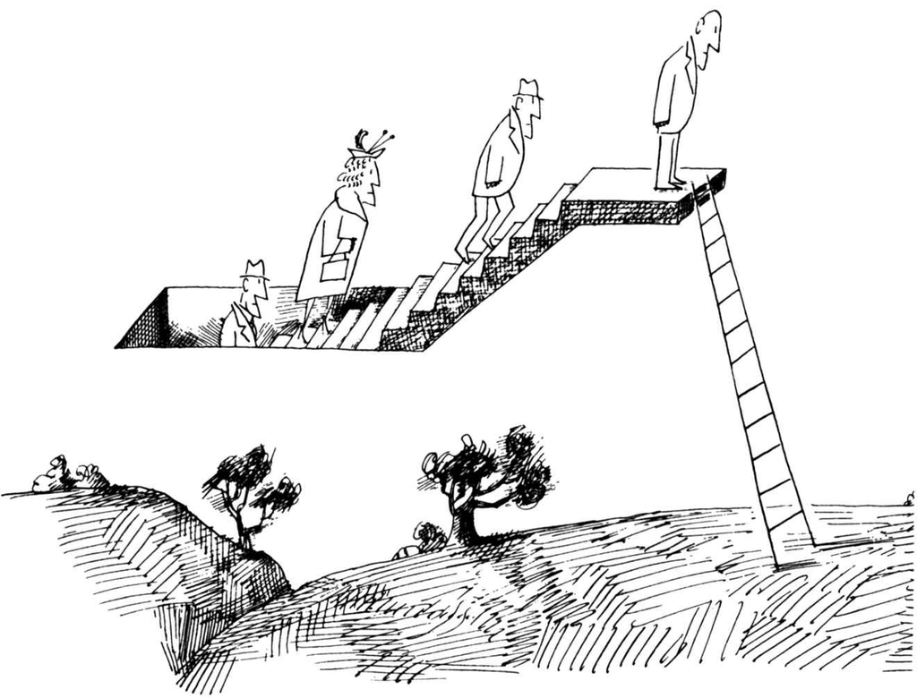

本图来源于《纽约客》1965年4月24日。

Saul Steinberg，*Untitled drawing*，ink on paper.

Originally published in *The New Yorker*，April 24，1965.

©The Saul Steinberg Foundation/Artists Rights Society（ARS），New York

突然有人开始跑了起来。也许他只是突然想起来要和自己妻子约会的事情，而现在他却迟到了。不管是什么，他在宽阔的街道上向东跑去（可能是去马拉莫餐馆，一个男人最喜爱与妻子约会的地方）。又有人开始跑了起来，也许是个兴高采烈的报童。另外一个人，一个胖胖的绅士，也突然小跑起来。十分钟内，从工会车站到法院，大街上的每个人都在奔跑。一声响亮的咕哝渐渐变成了可怕的“大坝”这个词。“大坝决堤了！”这种恐惧是由一个坐在电动车上的小老太太、交通警察或一个小男孩说出来的；没有人知道是谁，现在这一点也并不重要了。两千多人突然奔跑起来。四面都是“往东跑！”的喊声，远离河流，向东安全。“向东跑！向东跑！”一个身材高挑、眼神冷酷、下巴尖峭的女人从我身边跑过，沿着街道中央跑过去。我仍然不知道是怎么回事，尽管所有的人都在喊叫。我费了一番气力才追到那个女人旁边，她虽然五十多岁了，但从她那轻盈优美的奔跑姿势中，看得出她身体棒极了。“发生了什么事情？”我问道。她快速地瞥了我一眼，然后又继续将目光投向前方，稍稍加快了脚步。“别问我，去问上帝吧！”她说道。<sup>1</sup>

尽管有点滑稽可笑，但这个来自伟大的幽默作家詹姆斯·瑟伯（James Thurber）自传的故事，是有关从众现象恰当的例证。一两个人开始奔跑是出于他们自己的原因；不久，每个人都在奔跑。为什么会这样？因为其他人都在跑。在瑟伯的故事里，当奔跑者们意识到大坝根本没有决堤时，他们会觉得自己很愚蠢。然而，假如他们没有从众，而大坝真的决堤了，他们又会感到自己有多么愚蠢呢？

从众是好是坏？乍一听，是一个可笑的问题。然而，这个词本身的确具有评价的功能。因此，在美国文化中，被称为个人主义者或特立独行者，让人联想到一位站在山顶上的孤傲的牛仔，他的肩膀上挎着一杆来复枪，在夕阳西下的时候，微风吹拂着他的头发。在这种文化中，称某人为从众者是一种侮辱。这个词让人联想到一个盲目追随他人的人：穿着制服的企业高管；仿效朋友的服饰、谈吐和举止的青少年；人们开始相信一些末日预言或阴谋论，因为“他们认识的每个人”都相信。每个人总能回想起某个从众者的形象，而且他很少是那种刻意奉承者。

人类是社会性动物这一事实的一个后果，便是我们生活在与个性相关的价值观和与从众相关的价值观的博弈之中。我们可以用同义词来表达十分不同的形象。对于个体主义者或非从众主义者，我们可以用“离经叛道”这个词来代替；对于从众主义者，我们可以称之为团队合作者。无论如何，离经叛道不再让人们联想到孤傲的牛仔；同样，团队合作者也不会让人联想到盲从的白领、青少年或阴谋论者。我们的文化同样对从众（团队合作行为）和不从众（越轨行为）持矛盾态度。例如，20世纪50年代的畅销书之一是约翰·F·肯尼迪（当时还是未来总统）的书，他在书中赞扬了几位政治家在抵制政治压力以顺应潮流方面的勇气。换句话说，肯尼迪赞扬的是那些不落俗套和表现欠佳的团队成员，他们缺乏与他们的党派或选民和谐相处的能力。这些特立独行的人赢得了肯尼迪的赞扬，但是在他们采取行动的时候，他们的同事们普遍感到很不高兴——事实上，大多数人都对他们所看到的“离经叛道”和不遵守党的路线感到愤怒。那些特立独行者要撰写有趣的故事，正是因为他们经常受到周围人的恶劣对待。尽管我们在历史上或电影中都很欣赏他们，但在日常生活中，我们倾向于从众主义者。

这一观察得到了许多社会心理学经典实验的有力支持。在斯坦利·沙赫特（Stanley Schachter）的一篇论文中，<sup>2</sup>一群男性大学生讨论了某个案件的卷宗，该卷宗决定了一名因违法而被捕的青少年的命运。在阅读了该卷宗之后，要求每个小组讨论这个问题，并针对这个年轻人的惩罚达成一致意见，从“非常宽大的判决”到“非常严厉的判决”。每个小组由九名被试组成，其中六名是真被试，其余三名是实验者的帮手。这些帮手依次扮演事前安排的三种角色中的一种，他们事先经过了精心的演练：仿效者，所采取的立场与真被试的一般立场相符合；偏离者，采取与小组的一般倾向针锋相对的立场；立场改变者，他们最初采取的是与偏离者类似的立场，随着讨论的进行，渐渐转向了仿效者，采取了从众的立场。

你认为哪类参与者最受欢迎？是立场转变者吗？绝非如此。最受欢迎的是与小组标准相一致的仿效者，最不受欢迎的是偏离者。此外，也发现了另一种可以预见的结果，交流模式变化带来的影响：在讨论的初期，小组花费了相当多的时间试图说服偏离者接受他们的观点；但当情况变得明朗时，这个偏离者便不会让步，其他人也基本上忽略了他，也就是说他基本上被排除在小组讨论之外。在后续的实验中，艾瑞·克鲁格兰斯基（Arie Kruglanski）和唐娜·韦伯斯特（Donna Webster）<sup>3</sup>发现，如果在临近截止时间前（当小组成员感觉到了将要结束讨论的紧要关头），而不是在讨论的早期提出异议，不循常规者尤其不受欢迎。

因此实证资料显示，至少在需要作出决策的团队中，人们更倾向于喜欢从众主义者，而并不是那些非从众主义者。这种倾向并非是不合理的。正是通过牺牲个人愿望与他人和谐相处的倾向，我们人类才拥有了巨大的进化优势；我们所具有的团队合作和传播文化的能力，使人类得以成长壮大。我们可以嘲笑瑟伯笔下的众人逃离一场空穴来风的洪水，但我们也应该对它的运作机制感到惊奇：就像公园里的一群鸟一样，一只鸟会将信息迅速传播开来，整个鸟群会顷刻间全都飞走。在我们人类作为狩猎—采集者的年代里，从众者的迅速反应无疑是至关重要的；事实上，不从众可能是灾难性的。假定某一天我突然厌倦了做一名从众者，于是我跳上自己的车子，开始沿着路的左侧行驶——这并非是一种十分聪明或适应性强的来表达我固执的个体主义的方式——如果你碰巧在同一条街的马路对面向我驶来，那对你是极不公平的。

然而，尽管我们从众的本性是可以适应的，但从历史上看，人们的这种行为倾向也会导致悲剧，从足球比赛的赛后骚乱到阿道夫·希特勒（Adolf Hitler）的狂热追随者齐声呼喊“希特勒万岁”。从众不仅发生在无目的性的人群之中，也会发生在组织严密的群体中，这些群体的成员对此应该有更多了解。希特勒的高级顾问之一阿尔伯特·斯皮尔（Albert Speer），在回忆录中将希特勒周围的人们描述为一个完全一致的圈子，在那里偏离是不被允许的。在这样的氛围中，即使是最野蛮的行动也似乎是合理的，因为他们没有不同意见（表现出一致同意的假象），任何顾问都无法接受其他选择存在的可能性。斯皮尔写道：

在正常情况下，那些背离现实的人很快就会被周围人嘲笑、批评并加以纠正。在第三帝国没有这样的纠正机制。与此相反，每一次自我欺骗都会被成倍地放大，就像置身于一个哈哈镜装饰而成的大厅，成为一个由反复得到确认的奇怪的虚幻世界，它不再与严酷的外部世界保持任何联系。在那些镜子里，除了自己的脸，我什么也看不见。<sup>4</sup>

一个离我们更近的例子，可以想想白宫工作人员和高级顾问同前总统理查德·尼克松（Richard Nixon）一起参与的对水门事件的掩盖。在这里，政府的高级官员（其中许多人是律师）作了伪证，销毁了证据，并且毫不掩饰地去行贿。这至少可以部分地归因于20世纪70年代早期，在总统周围形成的那个忠贞不二的封闭圈子。在这个圈子被打破之前，这种极端的忠诚使得偏离根本不可想象。有一次，几位高级顾问看到他们的违法行为似乎感到很惊讶，就如同在做噩梦一样。尼克松的白宫律师约翰·迪恩（John Dean）这样写道：

当你早上拿起报纸，读到了替代昨天封面报道的新的封面报道后，你开始相信今天的新闻是真实的。这一过程在一直持续，直到最后，白宫里形成了一种脱离实际的氛围：如果你反复不断地讲某件事情，它便会成为现实。例如，当媒体得知对新闻记者和白宫工作人员的通话进行窃听，此时断然否认已经不能奏效，便有人声称这是国家安全问题。我相信很多人都相信窃听是为了国家安全，但它的确不是，而是事后编造出来的辩护理由。但是当他们讲出这些话的时候，你知道，他们是真的相信。<sup>5</sup>

有时，从众的需要甚至会使个人对即将发生的灾难保持沉默。1986年1月28日，挑战者号航天飞机升空几秒钟后爆炸。包括一位深受爱戴的教师克里斯塔·麦考利夫（Christa McAuliffe，通过竞争而成为进入太空的第一位平民）在内的七名宇航员，在一团浓烟和火焰中丧生。不知何故，尽管工程师们强烈反对并警告说助推火箭接头的O型环存在缺陷，但他们仍然决定继续发射。美国国家航空航天局（NASA）的管理人员做出了发射的最终决定，他们并非不知道存在危险，也不是对宇航员的生命漠不关心，更不是缺陷助推器火箭的制造者。然而，在美国国家航空航天局对火箭发射持有极高预期的压力下，那些最终被证明正确的持不同意见的决策者，要么转向了多数人的立场，要么被排除在对话之外，就像斯坦利·沙赫特实验中的偏离者一样。

让我们来梳理一下。除了他们都做出了可怕的决策之外，希特勒的核心圈子、尼克松的亲密顾问、美国国家航空航天局的管理者，他们有何共同之处呢？他们都是一个一个没有不同意见、相对有凝聚力的团体。当这些团体被要求作出决定时，他们可能成为欧文·贾尼斯（Irving Janis）所说的**团体思维**（groupthink）<sup>6</sup>的牺牲品，这种思维方式发生在有凝聚力的团体中，在这种团体中，成员对一致性的需求超越了他们现实地评估行动方案及其替代方案的能力。参与这类适应不良决策策略的团体通常认为自己是无懈可击的；他们被乐观所蒙蔽。这种乐观情绪在不满情绪被抑制时会得以强化。面对从众的压力，小组成员可能会怀疑他们自己的保留意见，并避免发表这些意见，就像第1章中那位假想的朋友萨姆，他在得知自己和同伴们的看法不一致后，隐瞒了自己的真实观点。

我引用这些例子，并非想说明因为从众会自然地降临到人类的身上，所以那些做出错误决定的人应该得到理解。相反，我认为理解从众的力量及其心理运作机制是至关重要的，这样当它令人们感到不适并且导致众人犯错的时候，我们便可以减少从众。只有通过更深入地挖掘和努力理解这些过程，我们才有希望改进人们的决策方式，减少未来灾难发生的频率。

**什么是从众**

**从众**可以定义为一个人的行为或意见的改变，受到了来自另一个人或一群人的真实或想象的压力的结果。正如进化论所预测的那样，它开始于个体发育的早期，即婴儿时期，而且有其神经系统的基础。

**从众的生理基础** 你可以通过观察我们在生命的早期阶段就开始互相模仿，来了解这种调整对我们物种的影响。虽然我们并非天生的模仿者，<sup>7</sup>但婴儿们通过社会交往很早就学会了对所看到的面孔做出同样的反应，<sup>8</sup>事实上，他们会更多地关注那些与自己的面部表情相一致的面孔。<sup>9</sup>

当人们互相交谈时，他们会经常模仿对方的非语言行为和举止，这种现象被称为**变色龙效应**（chameleon effect）。坦妮亚·沙特朗（Tanya Chartrand）和约翰·巴赫（John Bargh）<sup>10</sup>让学生们和他们的某个帮手一起讨论了一组照片，这位帮手在交谈中经常抚摸自己的脸部或者抖动自己的脚。在互动的过程中，与抚摸脸部的帮手分在一组的学生抚摸自己的脸的次数很多；与抖动脚的帮手分在一组的学生更有可能抖动自己的脚。在另一堂课上，实验者的帮手们或者巧妙地让被试感受到自己在研究他们的姿势和行为举止，比如交叉双腿、抚摸脸部、摆弄头发；或者什么也不做。在讨论过后，被试对他们的合作伙伴进行了评价，结果他们更喜欢变色龙，而不是非变色龙。这一发现表明，我们模仿他人，因为这样做既体现出亲密感，也会产生亲密感，创造出一种“社交粘合剂”。<sup>11</sup>那些特别擅长改变视角、用别人的眼睛看世界的人是更好的变色龙，因此更受欢迎。<sup>12</sup>故意模仿别人以赢得别人的好感，则会适得其反。<sup>13</sup>希拉里·克林顿（Hillary Clinton）在南方竞选时，因采用南方的拖腔（并说“你们都是”）而受到批评。<sup>14</sup>

尽管许多动物会模仿它们的同类，但人类是极易进行模仿的。一些神经科学家将这一事实归因于镜像神经元，这是一种高度专门化的脑细胞，当我们执行某个动作或者当我们看到另一个人执行相同的动作时都会被激活。想想当你看到一位喜剧演员在舞台上被炸伤时你是如何感到危惧的，或者当你看到另一个人的痛苦时你是如何担忧的。镜像神经元能够产生同理心，但一定不能保证：当人们看到自己不喜欢的人或比自己拥有更少权力和地位的人时，它们便会关闭。<sup>15</sup>

镜像系统的主要功能之一是促进**社会学习**（social learning），即人们通过观察来学习的过程。丹尼尔·豪（Daniel Haun）<sup>16</sup>领导的一项实验研究发现，蹒跚学步的孩子会模仿同龄人的行为，即使这样做意味着要忽略先前的学习并失去奖励。在一项研究中，孩子们得到了一个球和拼图盒，盒里面有三个球大小的洞，他们很快就知道把球放在某个特定的洞里（比如中间的洞）就能得到一块巧克力。在经历了第一阶段学习之后，每个孩子都加入了一群由其他学步期儿童组成的小组，这些学步期儿童通过把球扔到另外一个洞里（如左边的洞）来学习如何获得巧克力。在第二阶段，幼儿会因为他们把球放进了和先前同样的洞里而继续得到巧克力，但是许多人表现出与他们的同龄人相反的倾向，选择放弃他们的学习以及因此而可能获得的巧克力，而倾向于顺从那些学习了稍微不同规则的孩子们。当同样的实验在黑猩猩和猩猩（也是高度社会性的动物）身上进行时，它们并没有表现出这类从众的倾向；它们坚持的行为使自己的回报最大化。我们再一次看到，在人类身上，从众的冲动是如何战胜个人偏好的——即便是面对着巧克力这样的奖赏。

**影响从众的复杂因素** 大多数从众行为发生在没有任何“压力感”的情况下。例如，喜剧电视中的背景笑声无所不在，以致我们很难注意到，然而它们所传达的信息——其他人都发现了可笑的事——会深刻地影响着我们对同一件事情的反应。

1984年，在美国政坛的一个著名事件中，73岁的总统罗纳德·里根（Ronald Reagan）在竞选连任时遇到了困难。由于里根已经是美国历史上最老的总统，人们普遍担心他年纪太大，不能胜任这份工作。他的年轻对手沃尔特·蒙代尔（Walter Mondale）曾担任过副总统并且是一位颇受欢迎的参议员；他既有经验，也比较年轻而且充满活力。然而，里根却以压倒性优势击败了蒙代尔。里根是如何让选民放心并取得决定性胜利的呢？在第二次辩论中，里根表现出了一种幽默感，尤其是当被问及他是否太老而不适合当总统时，他说：“我不会把年龄作为竞选中的一个议题。”“我不会为了政治目的，而利用我对手的过于年轻和缺乏经验。”包括蒙代尔在内的观众对里根这具有讽刺意味的机智回应报以大笑和掌声，许多选民在那一刻改变了对里根的看法，显然这一回应和其他预先演练好的幽默打消了选民的疑虑。他的精神状态仍然适合于为国家服务。

许多年后，在一个巧妙的实验中，史蒂文·费恩（Steven Fein）和他的同事<sup>17</sup>为从未听过或看过这场著名辩论的大学生（实况播出时他们还是婴儿）播放了这场辩论的录音带。在基准条件下，他们像1984年人们实际看到的那样进行辩论；在第二种条件下，他删除了里根最幽默的两条台词，包括年轻和缺乏经验的幽默回应；在第三种情况下，他留下了两条有趣的台词，但删除了观众的笑声和掌声。观看之后，被试评价了他们对两位候选人的喜爱程度，并评估了谁在辩论中表现得更好。对原录音带的两个改动都产生了不同效果：完全删除里根的幽默回应，也就等于完全消除了里根赢得辩论的感觉，但关键不是幽默本身。当观察者听到里根的幽默回应而没有看到观众的反应时，大多数人认为蒙代尔赢了；如果播出了笑声，他们则认为里根赢了！不需要直接的压力，只要其他人在笑，就可以起到这样的效果。很多从众行为都是这样产生的；环境中的社会暗示告诉我们其他人的感觉、想法或行为，而这些又会反过来影响我们的感觉、想法和行为。

让我们回到我们的朋友萨姆，那位假想的大学生。记得萨姆在电视上看到一位参议员候选人，这位候选人的真诚给他留下了很好的印象。然而，他的朋友们一致认为这位候选人不诚实，这给他带来了很大的社会压力，他至少口头上同意了他们的意见。

就连这个虚拟的小故事也引发了一些有趣的问题：（1）是什么原因导致人们服从群体压力？具体来说，萨姆感受到了什么？（2）群体压力的性质是什么？具体而言，萨姆的朋友通过什么来诱导他从众？在那段短暂而令人不安的时间里，当萨姆得知他的朋友都不同意他的观点时，他是否改变了自己对候选人的看法？还是萨姆仍然坚持他原有的看法，只是口头上改变了他对候选人的看法？如果他改变了主意，是永久的还是仅限于那天晚上？

不幸的是，因为萨姆是一个假想的人物，我们不能问他。而且，即使是一个真实存在的萨姆也不能给我们提供一个准确的解释，这是值得怀疑的，因为即便人类能够非常准确地解释自己的行为，<sup>18</sup>但是在这种情况下还会有太多的其他影响因素。我们不知道萨姆对他最初的观点有多自信；我们不知道他对候选人的演讲有多了解，或者他有多喜欢和他一同收看的那些人；我们不知道萨姆是否认为自己是一个真诚的评判者，或者他是否认为其他人也是真诚的评判者；我们不知道萨姆通常是一个坚定的人，还是一个不自信的人；我们也不知道萨姆在学习了一天之后还会有多强的意志力来做出真诚判断，等等。

我们所能做的就是进行实验研究，让人们面对像萨姆那样的困境，在那里我们有能力控制和改变我们认为可能影响从众的因素。很多社会心理学的研究都做到了这一点，而这一切可追溯到穆扎法尔·谢里夫（Muzafer Sherif）和所罗门·阿希（Soloman Asch）的早期研究。

**谢里夫和阿希的经典实验研究** 假定你在一个黑暗的房间里，你从远处凝视着一个固定的光点，过上一会儿，光就会出现移动，这是一种视错觉，称为**游动效应**（auto-kinetic effect）。谢里夫<sup>19</sup>利用这种错觉来研究感知是如何受到社会影响的。他让大学生们坐在一个黑暗的房间里，观察一个光点，然后，每次它“移动”的时候，报告它有多远。每个学生会单独做几次试验，经过这几次试验，会确定一个可靠的距离，通常在2到6英寸之间。然后，他们被分成若干小组待在黑暗的房间里，并被要求重复这项任务，这次要大声报告他们的估计。谢里夫注意到了其他人的存在所带来的强烈影响：几乎每个人的判断都开始朝着群体平均水平的方向趋近。例如，如果我一个人的时候通常看到光移动2英寸，但是我的队友们倾向于看到它移动6英寸，我现在开始报告大约4英寸的移动。同样，那些最初看到更多运动的人在听到我的意见后会报告他们看到的更少。更重要的是，这种变化会始终存在。在了解到团体的某种意见后，成员们再次受到考验，他们的回答不断反映出该团体对自己判断的影响。谢里夫后来发现，他可以通过让他的帮手提供的任意估计来确立群体规范。只要与实际标准的偏差不是太大，他就可以将这个团体的意见引导到他所希望的任何方向。

估计一个光点移动了多少具有内在的模糊性。几年后，所罗门·阿希希望考察的是，当判断的对象非常确切的时候会发生什么。<sup>20</sup>假如你眼前的判断不是一种视错觉，而是一个明显的事实，会出现什么结果呢？阿希预测，从众行为将会直线下降。

现在将你自己置身于以下的情境中：你自愿参加一个关于感知判断的实验。你和其他六位被试走进了一个房间。实验者向你们所有人展示了一条直线（X），与相邻的其他三条直线（A，B，C）。你的任务是判断这三条直线中哪一条的长度最接近X。你会觉得作出这个判断十分简单。

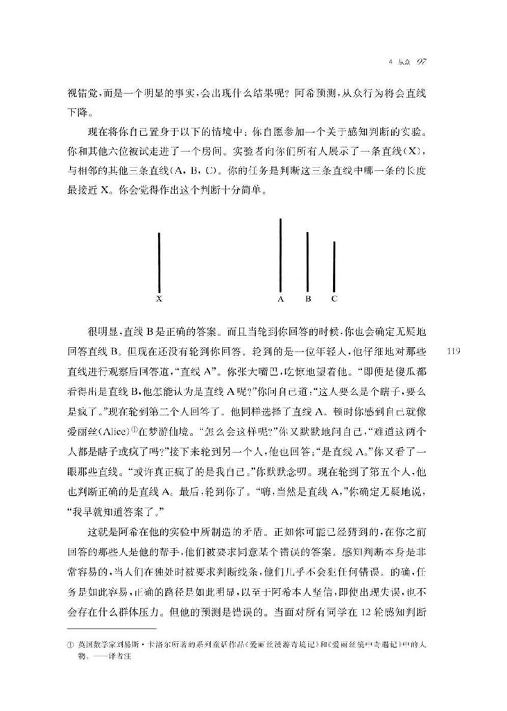

很明显，直线B是正确的答案。而且当轮到你回答的时候，你也会确定无疑地回答直线B。但现在还没有轮到你回答。轮到的是一位年轻人，他仔细地对那些直线进行观察后回答道，“直线A”。你张大嘴巴，吃惊地望着他。“即便是傻瓜都看得出是直线B，他怎能认为是直线A呢？”你问自己道：“这人要么是个瞎子，要么是疯了。”现在轮到第二个人回答了。他同样选择了直线A。顿时你感到自己就像爱丽丝（Alice）<sup>[1]</sup>在梦游仙境。“怎么会这样呢？”你又默默地问自己，“难道这两个人都是瞎子或疯了吗？”接下来轮到另一个人，他也回答：“是直线A。”你又看了一眼那些直线。“或许真正疯了的是我自己。”你默默念叨。现在轮到了第五个人，他也判断正确的是直线A。最后，轮到你了。“嗨，当然是直线A，”你确定无疑地说，“我早就知道答案了。”

这就是阿希在他的实验中所制造的矛盾。正如你可能已经猜到的，在你之前回答的那些人是他的帮手，他们被要求同意某个错误的答案。感知判断本身是非常容易的，当人们在独处时被要求判断线条，他们几乎不会犯任何错误。的确，任务是如此容易，正确的路径是如此明显，以至于阿希本人坚信，即使出现失误，也不会存在什么群体压力。但他的预测是错误的。当面对所有同学在12轮感知判断中一致做出不正确的回答时，为了与其他人保持一致大约四分之三的被试至少出现了一次错误的回答。在全部感知判断中，平均有35%的判断与错误判断保持了一致。

阿希在20世纪中叶进行了他的实验。尽管研究结果颇具影响力，但人们还是倾向于以当代美国大学生已经今非昔比为由，对他的研究结果加以忽略。随着计算机和互联网的出现，你可能认为人类已经变得更加复杂，因此不太容易受到这种群体压力的影响，但事实并非如此。近年来，阿希实验被成功地重复了很多次。在国家电视台的一次特别引人注目的演示中，安东尼·普莱特肯尼斯（Anthony Pratkanis）<sup>21</sup>重复了这个实验——就像阿希50年前所做的那样。这个重复实验的被试也是大学生，他们中许多人认为自己是特立独行的。但实验结果却几乎和阿希的实验完全一致。

然而，在抵制群体压力的倾向上存在着一些文化差异。通过民间智慧的对比可以很好地说明这一点：在美国，人们会说，“吱吱叫的车轮先上油”（意思是，“有事，就大声说出来！”）；在日本，人们说，“突起的钉子先敲下”（意思是说，“不要偏离你的团队”）。罗德·邦德（Rod Bond）和彼得·史密斯（Peter Smith）<sup>22</sup>分析了在17个不同国家使用阿希办法进行的133项实验后发现，与个体主义社会（如美国和法国）相比，在鲜明地重视群体和谐（如日本）的集群主义社会中，从众现象更为普遍。

然而，无论人们生活在哪个国家，对群体压力加以抵抗都是非常困难的，不从众带来的痛苦不仅表现于人们的面部表情，而且在他们的神经活动中也会引起大脑的不适。<sup>23</sup>格雷戈里·伯恩斯（Gregory Berns）和他的合作者采用功能性核磁共振成像技术（fMRI）来监测参与者的神经活动，这些图像显示了那些对群体压力进行抵抗的被试杏仁核（大脑中与疼痛、恐惧和情绪不适相关的区域）的活动会增强，表现出与抵抗身体疼痛的被试同样的反应，<sup>24</sup>就像我在社会排斥实验中所看到的。<sup>25</sup>

这些实验创造的情境特别有趣，因为与我们倾向于从众的许多情境不同，没有明确的个性限制。更常见的是，对不合规则行为的制裁是明确的。例如，我一直讨厌打领带——这个时代终于迎合了我，现在很少需要打领带。但在20世纪60年代，当我还是一名年轻教授的时候，着装更为规范正式。这意味着，如果我去一家高级餐厅参加一个晚上的庆祝活动，妈妈会礼貌地（但坚定地）告诉我，如果我没有戴上他们提供的领带，那就不会有我的位子。这样，我要么戴上领带，在餐馆吃饭；要么选择离开，敞开脖子，个人舒服了，但却忍饥挨饿。在这种情况下，与许多其他情况一样，不从众的负面后果是确定的。同样地，詹妮斯在对团体思维的研究中也发现，通常总会有一两个人采取行动来执行群体的规范。正如詹妮斯所言，这些无需任命的卫道士，会要求人们保持一致并按共识行事。就像妈妈在餐厅里所交代的：门卫已经明确表示，如果你想有自己的座位，你就必须遵守群体的规范。

但是在阿希实验与萨姆和他的朋友们的案例中，情况却要复杂得多。在这些情况下，没有明确的服从奖励，没有明确的惩罚行为，也没有思想卫道士推动偏离者达成一致，只是人们以事实的方式报告他们所看到的。那么，为什么阿希的被试会从众呢？

**从众动机：归属还是信息获取** 从众的主要原因有两个：因为别人是有价值信息的来源，或者因为与别人相差太大令人感到不适；从众通过表达我们的相似性和思想上的亲近关系，来确保我们在某个群体中的地位。前一个原因基于丰富的信息：人们面对采取一致意见的多数人，会认为自己的观点因某种原因而出现了错误。后一个原因则基于规范：人们会“随大流”，但内心相信他们最初的判断是正确的，以求被大多数人所接受或避免因意见不同而被他们所厌恶。在阿希实验以及其他一些直接进行判断的实验中，个体的行为在很大程度上似乎是为了避免产生被排斥的感觉。我们可以从这样一个事实推断出这一点：当允许人们不公开回答时，他们对直线匹配的问题都会给出诚实的意见。

同时，在许多情况下，我们顺从他人的行为是因为：随着物质现实变得越来越不确定，人们越来越依赖“社会现实”。<sup>26</sup>也就是说，其他人的行为是了解正在发生事情的最佳指南。在这种情况下，一致性尤其有可能影响我们对现实的看法和感知，就像谢里夫实验中的学生和瑟伯在本章开头描述的场景一样：如果有人表现出某种行为，那一定是有道理的。

有这样一个例子可以澄清规范一致性与信息一致性之间的区别。几年前，我还住在一个陌生的大楼里。有一次我想上厕所，在看到“洗手间”的标志之后，我找到了常见的两扇门，但是不知是谁把上面的标志去掉了，所以我无法区分男厕和女厕。这真是一个两难的境地，我不敢猜测，因为我害怕进了女厕所感到尴尬，或者让任何一位待在里面的女士感到尴尬（或者害怕）。当我踌躇不定、尴尬地站在那里等候的时候，我左边的门开了，有人走了出来。我松了一口气，走了进去，因为我得到了正确的信息。

很多时候，其他人是一个很好的信息来源，一致性满足了我们对正确信息和归属感的需求。在母亲节给自己的母亲打个电话，和自己的朋友一起去一个收留无家可归者的收容所工作，在考试中努力学习以取得好成绩，这些都是人们所做的，也是应该做的。然而，有时候，我们就像是阿希实验中的学生，我们对正确信息的需要与我们对归属的需要会出现冲突。假定你是这个实验的被试，并且你最初相信正确的答案是直线B，那么说出来也许能够满足你对正确信息的需要——但是这样做也可能会违背你同龄人的期望，他们可能会认为你很怪异。选择直线A可能会赢得其他人的认可，但除非你确信他们的意见是正确的，否则这样做将违背你对正确信息的渴望。